# Using rockyIntertidal R pkg.

## Using the rockyIntertidal R package

### Getting started

#### **Step 1.** Install R, RStudio, and RTools in Company Portal

Install R 4.5 or higher, RStudio, and Rtools45 (DOI-DO-RTools 4.5.6608 on Company Portal) from Company Portal. Note that R and RTools versions generally need to match. However, according to [CRAN](https://cran.r-project.org/bin/windows/Rtools/rtools45/rtools.html) Rtools45 works for R 4.6 and the yet to be released R 4.7.

#### **Step 2.** Install pak package in R:

```r
install.packages('pak')
```

#### **Step 3.** Install rockyIntertidal from GitHub

Note that whenever the `rockyIntertidal` package is updated, you can rerun this code to install the latest version.

```r
library(pak)
pkg_install("doi-nps/rockyIntertidal")
```

#### **Step 4.** Load rockyIntertidal R package

```r
library(rockyIntertidal)
```

#### **Step 5.** Import rocky monitoring data

Note that R is not able to connect to files on Sharepoint or MS Teams (b/c Teams also stores all files on Sharepoint). That means you need to store data package files on your local machine or on a server (e.g. NETN Z drive). The default option for importing data will add the data package views (i.e., flatfiles) to an environment called ROCKY to your Environment work space (i.e. Environment tab in top right panel). If you would rather import each individual view into your R session, specify with the new_env argument (e.g., `importData(new_env = F)`). To import data using the default settings (i.e. run `importData()` with no arguments), you must have the rocky intertidal data package front end set as a User DSN called rocky_FE. The database front end must also be linked with the latest rocky intertidal backend to pull in the latest data (see “Setting up DSN” tab for more details).

**Option 1.** Import data via .csv files. The file path should be where csvs are on your machine or server.

```r
importData(type = 'csv',
           filepath = "../data/rocky") # update filepath to your computer
```

**Option 2.** Import data via zip file of csvs. The filepath should be the location and name of the zip file.

```r
importData(type = 'zip',
           filepath = "../data/rocky/NETN_RockyIntertidal_Data_Package_20260917.zip")
```

**Option 3.** Import data via data package database file on your computer

```r
importData(type = 'dbfile',
           filepath = "../data/rocky/NETN_RockyIntertidal_FE_DataPackage_20241211.accdb")
```

**Option 4.** Import data via data package database DSN (Data Source Name) on your computer. Note that this is the default setting. As long as you have a named DSN called “rocky_FE” that links to the data package FE database, and that database links to the latest rocky intertidal backend database, the code below will run. See *Setting up DSN* tab for how to set up DSN.

```r
importData() # easiest
importData(type = 'DSN', odbc = "rocky_FE") # equivalent to line above
```

#### **Step 6.** (Optional) Export data package to zip

You can export all of the csvs to a zip file with the day’s date stamped on the file name. This allows you to import the tables from the database, then export the csvs as one zip file.

```r
exportData(filepath = "./data", zip = TRUE)
```

```r
exportData(filepath = "../data", zip = FALSE)
```

#### **Step 6b.**Import water temperature data *NOTE: NOT RECENTLY TESTED/NOT CURRENTLY ACTIVE*

The water temperature data is stored as separate csvs and so has a different import function and process. The temp logger files will go into your ROCKY environment named the 6 letter location code. The `buoy = T` loads the buoy data for each park to the ROCKY environment. The `simplify = T` simplifies the datasets to include only 1 logger measurement per high tide event (for water temp) and 1 buoy record per day. All plotting functions require the simplified data. The latest compiled files are on the Z drive here: “../Rocky_Intertidal/NETN/5_Data/Data_Files/Temperature/Compiled_HT_water_temps_2011-2022/”.

```r
path = "../data/rocky/temp_data/Compiled_HT_water_temps"
importWaterTemp(path = path, buoy = T, simplify = T)
```

#### **Step 7.** Play with the data

The functions in the `rockyIntertidal` package are designed to work with the views, and are the best way to interact with the data to query by park, site, site type, year, parameter, etc. However, if you want to view the raw data, and you imported the data into the ROCKY environment, you can access them with the code below:

```r
# See list of the views
names(ROCKY)

# View one of the views
View(ROCKY$Bolts)

# See top 6 records
head(ROCKY$Echinoderm_Counts)

# Check structure of view
str(ROCKY$Echinoderm_Counts)

# Assign a view to a data frame named bolts in R. Interact with bolts the way you would work with any normal data frame in R.
bolts <- ROCKY$Bolts
```

While the above code works, the better approach is to use the “get”, “sum” or “plot” functions within the R package, which access the same files, but allow you to also query, summarize, and plot data based on park, location, years, plot name, species, etc. The functions in this package also drop QAQC visits and other duplicates (e.g. barnacle counts) in the data by default, making analysis easier and more repeatable.

#### Package Design

The package has 4 main types of functions to facilitate working with rocky interidal data:

- **import/export:** facilitates importing and exporting data package views in R.
- **get:** Each view in the data package has a get function that allows you to query by park, site, year, community, species, etc. In general, the get functions return raw data from the views.
- **sum:** Most views in the data package also have a summary function that allows you to summarize plot-level data, such as average cover of species by photoplot community type. The get file for that view is used under the hood.
- **plot:** most views also have a plotting function that typically uses the sum function under the hood and visualizes the data for that view. All plotting functions return a ggplot2 object, which means you can usually add ggplot geoms, scales, etc. to them (though note if a scale is already used under the hood, you may not be able to specify another).

#### **Getting (and improving) help**

The functions in `rockyIntertidal` have help documentation like any R package. To view the help, you can go to the Packages tab and click on rockyIntertidal (see below). That will show you all the functions in the package. Clicking on individual functions will take you to the help documentation for that function.

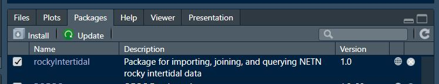

You can also see the help of a function by running, for example:

```r
?importData
```

If `rockyIntertidal` isn’t loaded yet, you’d run:

```r
?rockyIntertidal::importData
```

Each function’s help includes a Description, Usage (i.e. function arguments and their defaults), Argument options/definitions, and several examples showing how the function can be used. **This is where you come in! If you notice typos or can think of better descriptions, examples, error messages, etc., please send them my way!** After we’re more comfortable with R packages and get versed on GitHub, you’ll be able to make those changes directly in the package. For now, you can just send me your suggestions and I’ll make the changes.

Finally, if you ever want to peak under the hood at the function, you can view it several ways.

1. Keep F2 key pressed and click on the function name in R. This trick works for many but not all functions in R.
2. View code in the [GitHub doi-nps/rockyIntertidal repo](https://github.com/doi-nps/rockyIntertidal/tree/main). The functions are in the R folder.

#### **Setting up a DSN**

1. Go to Windows Start Menu and search ODBC. Click on ODBC Data Sources (64-bit)

[figure not shown]

2. Click on *Add*, then select *Microsoft Access Driver (*.mdb, *.accdb)* then click *Finish* in next menu.

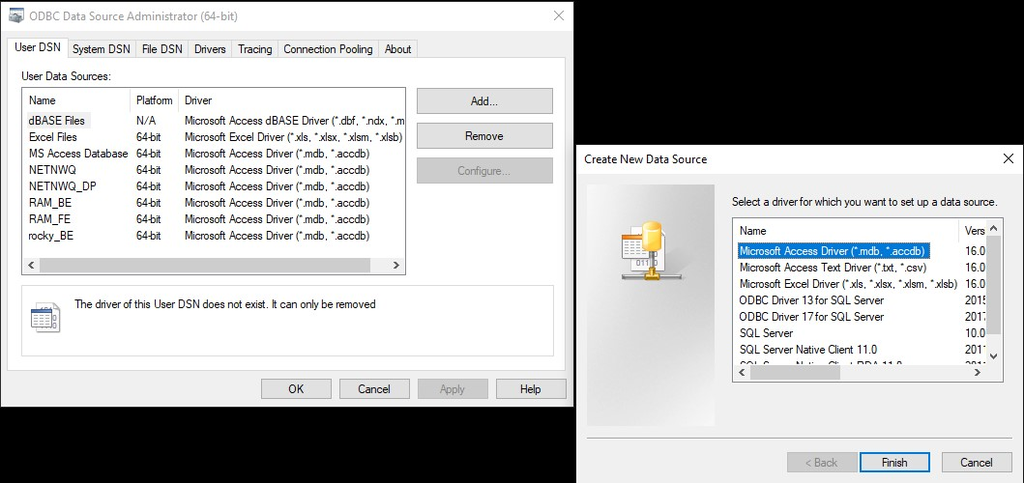

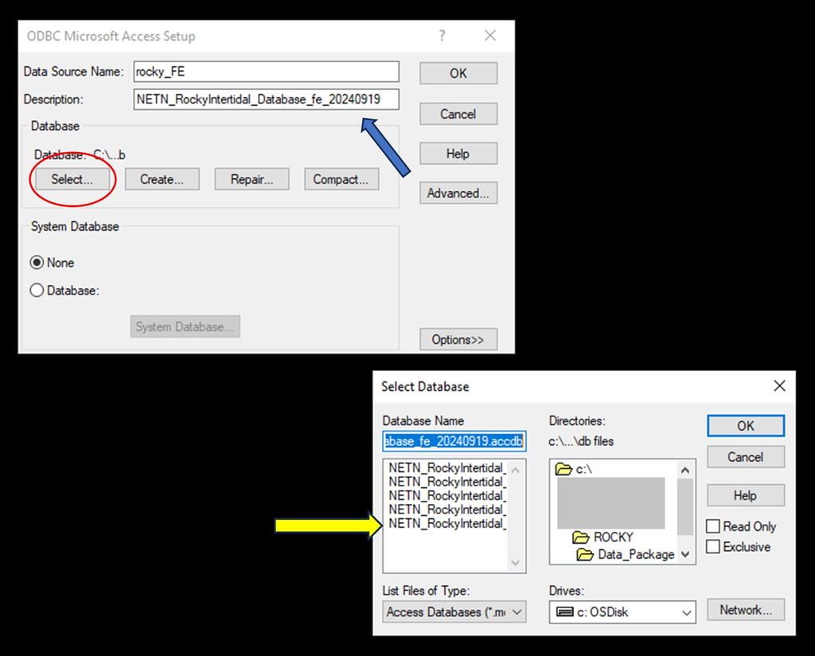

4. If updating an existing DSN, follow similar process, except click on the DSN in the first window and select *Configure* instead of Add.

### get Data functions

#### getBolts()

This function filters bolt data by park, site, plot type or plot name. Bolts are location-level and do not contain visit data.

Default, returns all records except blank X/Y or elevations

```r
bolts <- getBolts()
```

| GroupCode | GroupName | UnitCode | UnitName | SiteName | SiteCode | Label | PlotName | PlotType | CommunityType | BoltLatitude | BoltLongitude | LatLong_Datum | Bolt_UTM_E | Bolt_UTM_N | Bolt_UTM_Zone | Bolt_UTM_Datum | Bolt_NAVD88_Elev | Bolt_MLLW_Elev | Notes | IsBoltCUI |
| --- | --- | --- | --- | --- | --- | --- | --- | --- | --- | --- | --- | --- | --- | --- | --- | --- | --- | --- | --- | --- |
| NETN | Northeast Temperate Network | ACAD | Acadia National Park | Bass Harbor | BASHAR | A1 bolt 01 | A1 | Photoplot | Ascophyllum | 44.22468 | -68.32274 | WGS84 | 554148.7 | 4897066 | 19 | NAD83 | 0.991282 | 2.812282 | NA | FALSE |
| NETN | Northeast Temperate Network | ACAD | Acadia National Park | Bass Harbor | BASHAR | A1 bolt 02 | A1 | Photoplot | Ascophyllum | 44.22467 | -68.32274 | WGS84 | 554148.7 | 4897066 | 19 | NAD83 | 0.938755 | 2.759755 | NA | FALSE |
| NETN | Northeast Temperate Network | ACAD | Acadia National Park | Bass Harbor | BASHAR | A1 bolt 03 | A1 | Photoplot | Ascophyllum | 44.22467 | -68.32273 | WGS84 | 554148.7 | 4897066 | 19 | NAD83 | 0.986298 | 2.807298 | NA | FALSE |
| NETN | Northeast Temperate Network | ACAD | Acadia National Park | Bass Harbor | BASHAR | A1 bolt 04 | A1 | Photoplot | Ascophyllum | 44.22468 | -68.32273 | WGS84 | 554148.7 | 4897066 | 19 | NAD83 | 1.002103 | 2.823103 | NA | FALSE |
| NETN | Northeast Temperate Network | ACAD | Acadia National Park | Bass Harbor | BASHAR | A1 label | A1 | Photoplot | Ascophyllum | 44.22468 | -68.32274 | WGS84 | 554148.7 | 4897066 | 19 | NAD83 | 0.965703 | 2.786703 | NA | FALSE |
| NETN | Northeast Temperate Network | ACAD | Acadia National Park | Bass Harbor | BASHAR | A2 bolt 01 | A2 | Photoplot | Ascophyllum | 44.22464 | -68.32278 | WGS84 | 554148.7 | 4897066 | 19 | NAD83 | 0.565771 | 2.386771 | NA | FALSE |

Get bolt data for ACAD barnacle recruitment plots

```r
acad_recr <- getBolts(park = "ACAD", plotType = "Recruitment Plot")
```

| GroupCode | GroupName | UnitCode | UnitName | SiteName | SiteCode | Label | PlotName | PlotType | CommunityType | BoltLatitude | BoltLongitude | LatLong_Datum | Bolt_UTM_E | Bolt_UTM_N | Bolt_UTM_Zone | Bolt_UTM_Datum | Bolt_NAVD88_Elev | Bolt_MLLW_Elev | Notes | IsBoltCUI |
| --- | --- | --- | --- | --- | --- | --- | --- | --- | --- | --- | --- | --- | --- | --- | --- | --- | --- | --- | --- | --- |
| NETN | Northeast Temperate Network | ACAD | Acadia National Park | Bass Harbor | BASHAR | S1 bolt 01 | S1 | Recruitment Plot | Barnacle | 44.22448 | -68.32216 | WGS84 | 554148.7 | 4897066 | 19 | NAD83 | 0.453275 | 2.274275 | NA | FALSE |
| NETN | Northeast Temperate Network | ACAD | Acadia National Park | Bass Harbor | BASHAR | S1 bolt 02 | S1 | Recruitment Plot | Barnacle | 44.22448 | -68.32215 | WGS84 | 554148.7 | 4897066 | 19 | NAD83 | 0.475296 | 2.296296 | NA | FALSE |
| NETN | Northeast Temperate Network | ACAD | Acadia National Park | Bass Harbor | BASHAR | S1 label | S1 | Recruitment Plot | Barnacle | 44.22448 | -68.32216 | WGS84 | 554148.7 | 4897066 | 19 | NAD83 | 0.429081 | 2.250081 | NA | FALSE |
| NETN | Northeast Temperate Network | ACAD | Acadia National Park | Bass Harbor | BASHAR | S2 bolt 01 | S2 | Recruitment Plot | Barnacle | 44.22446 | -68.32218 | WGS84 | 554148.7 | 4897066 | 19 | NAD83 | 0.431997 | 2.252997 | NA | FALSE |
| NETN | Northeast Temperate Network | ACAD | Acadia National Park | Bass Harbor | BASHAR | S2 bolt 02 | S2 | Recruitment Plot | Barnacle | 44.22446 | -68.32218 | WGS84 | 554148.7 | 4897066 | 19 | NAD83 | 0.409523 | 2.230523 | NA | FALSE |
| NETN | Northeast Temperate Network | ACAD | Acadia National Park | Bass Harbor | BASHAR | S2 label | S2 | Recruitment Plot | Barnacle | 44.22446 | -68.32218 | WGS84 | 554148.7 | 4897066 | 19 | NAD83 | 0.405884 | 2.226884 | NA | FALSE |

Return bolts for algal only in Ship Harbor and Bass Harbor

```r
acad_alg <- getBolts(site = c("BASHAR", "SHIHAR"), community = c("Ascophyllum", "Fucus", "Red Algae"))
```

| GroupCode | GroupName | UnitCode | UnitName | SiteName | SiteCode | Label | PlotName | PlotType | CommunityType | BoltLatitude | BoltLongitude | LatLong_Datum | Bolt_UTM_E | Bolt_UTM_N | Bolt_UTM_Zone | Bolt_UTM_Datum | Bolt_NAVD88_Elev | Bolt_MLLW_Elev | Notes | IsBoltCUI |
| --- | --- | --- | --- | --- | --- | --- | --- | --- | --- | --- | --- | --- | --- | --- | --- | --- | --- | --- | --- | --- |
| NETN | Northeast Temperate Network | ACAD | Acadia National Park | Bass Harbor | BASHAR | A1 bolt 01 | A1 | Photoplot | Ascophyllum | 44.22468 | -68.32274 | WGS84 | 554148.7 | 4897066 | 19 | NAD83 | 0.991282 | 2.812282 | NA | FALSE |
| NETN | Northeast Temperate Network | ACAD | Acadia National Park | Bass Harbor | BASHAR | A1 bolt 02 | A1 | Photoplot | Ascophyllum | 44.22467 | -68.32274 | WGS84 | 554148.7 | 4897066 | 19 | NAD83 | 0.938755 | 2.759755 | NA | FALSE |
| NETN | Northeast Temperate Network | ACAD | Acadia National Park | Bass Harbor | BASHAR | A1 bolt 03 | A1 | Photoplot | Ascophyllum | 44.22467 | -68.32273 | WGS84 | 554148.7 | 4897066 | 19 | NAD83 | 0.986298 | 2.807298 | NA | FALSE |
| NETN | Northeast Temperate Network | ACAD | Acadia National Park | Bass Harbor | BASHAR | A1 bolt 04 | A1 | Photoplot | Ascophyllum | 44.22468 | -68.32273 | WGS84 | 554148.7 | 4897066 | 19 | NAD83 | 1.002103 | 2.823103 | NA | FALSE |
| NETN | Northeast Temperate Network | ACAD | Acadia National Park | Bass Harbor | BASHAR | A1 label | A1 | Photoplot | Ascophyllum | 44.22468 | -68.32274 | WGS84 | 554148.7 | 4897066 | 19 | NAD83 | 0.965703 | 2.786703 | NA | FALSE |
| NETN | Northeast Temperate Network | ACAD | Acadia National Park | Bass Harbor | BASHAR | A2 bolt 01 | A2 | Photoplot | Ascophyllum | 44.22464 | -68.32278 | WGS84 | 554148.7 | 4897066 | 19 | NAD83 | 0.565771 | 2.386771 | NA | FALSE |

Get bolt data for Calf Island photoplots

```r
calf_ph <- getBolts(site = "CALISL", plotType = "Photoplot")
```

| GroupCode | GroupName | UnitCode | UnitName | SiteName | SiteCode | Label | PlotName | PlotType | CommunityType | BoltLatitude | BoltLongitude | LatLong_Datum | Bolt_UTM_E | Bolt_UTM_N | Bolt_UTM_Zone | Bolt_UTM_Datum | Bolt_NAVD88_Elev | Bolt_MLLW_Elev | Notes | IsBoltCUI |
| --- | --- | --- | --- | --- | --- | --- | --- | --- | --- | --- | --- | --- | --- | --- | --- | --- | --- | --- | --- | --- |
| NETN | Northeast Temperate Network | BOHA | Boston Harbor Islands National Park Area | Calf Island | CALISL | A1 bolt 01 | A1 | Photoplot | Ascophyllum | 42.34241 | -70.89479 | WGS84 | 343821.4 | 4689574 | 19 | NAD83 | 0.107605 | 1.785605 | NA | FALSE |
| NETN | Northeast Temperate Network | BOHA | Boston Harbor Islands National Park Area | Calf Island | CALISL | A1 bolt 02 | A1 | Photoplot | Ascophyllum | 42.34241 | -70.89478 | WGS84 | 343821.4 | 4689574 | 19 | NAD83 | -0.063546 | 1.614454 | NA | FALSE |
| NETN | Northeast Temperate Network | BOHA | Boston Harbor Islands National Park Area | Calf Island | CALISL | A1 bolt 03 | A1 | Photoplot | Ascophyllum | 42.34241 | -70.89478 | WGS84 | 343821.4 | 4689574 | 19 | NAD83 | -0.140115 | 1.537885 | NA | FALSE |
| NETN | Northeast Temperate Network | BOHA | Boston Harbor Islands National Park Area | Calf Island | CALISL | A1 bolt 04 | A1 | Photoplot | Ascophyllum | 42.34242 | -70.89478 | WGS84 | 343821.4 | 4689574 | 19 | NAD83 | -0.107108 | 1.570892 | NA | FALSE |
| NETN | Northeast Temperate Network | BOHA | Boston Harbor Islands National Park Area | Calf Island | CALISL | A1 label | A1 | Photoplot | Ascophyllum | 42.34241 | -70.89479 | WGS84 | 343821.4 | 4689574 | 19 | NAD83 | 0.095710 | 1.773710 | NA | FALSE |
| NETN | Northeast Temperate Network | BOHA | Boston Harbor Islands National Park Area | Calf Island | CALISL | A2 bolt 01 | A2 | Photoplot | Ascophyllum | 42.34242 | -70.89481 | WGS84 | 343821.4 | 4689574 | 19 | NAD83 | 0.249903 | 1.927903 | NA | FALSE |

#### getEvents()

This function filters events and returns notes recorded during sampling events by park, site, plot name, and species. All visit-level get functions include this function under the hood to filter on park, site, year, etc.

Return all non-QAQC events (default)

```r
evs <- getEvents()
```

| GroupCode | GroupName | UnitCode | UnitName | SiteCode | SiteName | StartDate | Year | QAQC | BM_Latitude | BM_Longitude | LatLong_Datum | Conditions_Swell | Conditions_Wind | Conditions_Rain | Conditions_RecentRain | Substrate_Sediment | Substrate_Scour | Substrate_RockMvmnt | Debris_PlantWrack | Debris_Driftwood | Debris_Shells | Debris_DeadAnimals | Debris_Trash | Debris_OilTar | Notes_Conditions | Notes_Marker | Notes_Other | Notes_Additional_Spp | IsPointCUI |
| --- | --- | --- | --- | --- | --- | --- | --- | --- | --- | --- | --- | --- | --- | --- | --- | --- | --- | --- | --- | --- | --- | --- | --- | --- | --- | --- | --- | --- | --- |
| NETN | Northeast Temperate Network | ACAD | Acadia National Park | BASHAR | Bass Harbor | 2014-06-21 | 2014 | FALSE | 44.22481 | -68.32205 | WGS84 | Low | Medium | Absent | Absent | Low | Low | Low | Absent | Absent | Absent | Low | Absent | Absent | Another day with perfect weather. Barnacle plots significantly overgrown with Fucus. | X3N bolt may be lost. Could not locate the bolt; need good triangulation numbers from other points. | In Photo 9, the tidepool transects are reversed (numbers and letters). Tidepool X3 probably not suitable - no kelp. | NA | FALSE |
| NETN | Northeast Temperate Network | ACAD | Acadia National Park | BASHAR | Bass Harbor | 2024-06-29 | 2024 | FALSE | 44.22481 | -68.32205 | WGS84 | Low | Medium | Absent | NA | Low | Low | Low | Low | Absent | Medium | Medium | Absent | Absent | This site is awesome. | NA | Question if T1/T3 data sheets were switched halway through - resolved | Hermit crabs, toad crab, dorid nudi eggs, colonial tunicates (goldenstar and orange sheath tunicate). Bread crumb sponge - nice tide pool. | FALSE |
| NETN | Northeast Temperate Network | ACAD | Acadia National Park | BASHAR | Bass Harbor | 2013-06-21 | 2013 | FALSE | 44.22481 | -68.32205 | WGS84 | Low | Low | Absent | Absent | Low | Low | Low | Absent | Absent | Absent | Absent | Absent | Absent | Another fine day! | Pulled extra bolt on vert transect 2 | None | NA | FALSE |
| NETN | Northeast Temperate Network | ACAD | Acadia National Park | BASHAR | Bass Harbor | 2023-06-12 | 2023 | FALSE | 44.22481 | -68.32205 | WGS84 | Low | Low | Absent | NA | Low | Medium | Low | Absent | Absent | Medium | High | Low | Absent | Bird scat everywhere; lots of dead cancer crab predation | NA | Found golden star tunicate, rock gunnels, rough nudibranchs | NA | FALSE |
| NETN | Northeast Temperate Network | ACAD | Acadia National Park | BASHAR | Bass Harbor | 2019-06-11 | 2019 | FALSE | 44.22481 | -68.32205 | WGS84 | Low | Medium | High | Absent | Low | Low | Low | Low | Low | Low | Low | Low | Absent | Lot’s of trash in upper areas | NA | NA | NA | FALSE |
| NETN | Northeast Temperate Network | ACAD | Acadia National Park | BASHAR | Bass Harbor | 2018-05-18 | 2018 | FALSE | 44.22481 | -68.32205 | WGS84 | Low | Low | Absent | Absent | Low | Low | Low | Absent | Absent | Low | Low | Absent | Absent | Relative to other sites this year, the band of turfing green algae was smaller. | T1 - 20, missing - no hole found; replaced between 19 + 21 (FIXED) | none | none | FALSE |

Get events in ACAD since 2021

```r
acad21 <- getEvents(park = "ACAD", years = 2021:as.numeric(format(Sys.Date(), "%Y")))
```

| GroupCode | GroupName | UnitCode | UnitName | SiteCode | SiteName | StartDate | Year | QAQC | BM_Latitude | BM_Longitude | LatLong_Datum | Conditions_Swell | Conditions_Wind | Conditions_Rain | Conditions_RecentRain | Substrate_Sediment | Substrate_Scour | Substrate_RockMvmnt | Debris_PlantWrack | Debris_Driftwood | Debris_Shells | Debris_DeadAnimals | Debris_Trash | Debris_OilTar | Notes_Conditions | Notes_Marker | Notes_Other | Notes_Additional_Spp | IsPointCUI |
| --- | --- | --- | --- | --- | --- | --- | --- | --- | --- | --- | --- | --- | --- | --- | --- | --- | --- | --- | --- | --- | --- | --- | --- | --- | --- | --- | --- | --- | --- |
| NETN | Northeast Temperate Network | ACAD | Acadia National Park | BASHAR | Bass Harbor | 2024-06-29 | 2024 | FALSE | 44.22481 | -68.32205 | WGS84 | Low | Medium | Absent | NA | Low | Low | Low | Low | Absent | Medium | Medium | Absent | Absent | This site is awesome. | NA | Question if T1/T3 data sheets were switched halway through - resolved | Hermit crabs, toad crab, dorid nudi eggs, colonial tunicates (goldenstar and orange sheath tunicate). Bread crumb sponge - nice tide pool. | FALSE |
| NETN | Northeast Temperate Network | ACAD | Acadia National Park | BASHAR | Bass Harbor | 2023-06-12 | 2023 | FALSE | 44.22481 | -68.32205 | WGS84 | Low | Low | Absent | NA | Low | Medium | Low | Absent | Absent | Medium | High | Low | Absent | Bird scat everywhere; lots of dead cancer crab predation | NA | Found golden star tunicate, rock gunnels, rough nudibranchs | NA | FALSE |
| NETN | Northeast Temperate Network | ACAD | Acadia National Park | BASHAR | Bass Harbor | 2022-05-22 | 2022 | FALSE | 44.22481 | -68.32205 | WGS84 | Medium | Low | Absent | Present | Low | Low | Absent | Low | Absent | Low | Low | Low | Absent | Nothing out of the ordinary. Adam would like to note dense fog. | NA | Nothing. Perhaps first season without repairing sites. | Lots of hermit crabs, one waved whelk, one toad crab | FALSE |
| NETN | Northeast Temperate Network | ACAD | Acadia National Park | BASHAR | Bass Harbor | 2021-07-18 | 2021 | FALSE | 44.22481 | -68.32205 | WGS84 | Low | Low | High | Absent | Low | Absent | Absent | Low | Absent | Low | Low | Low | Absent | None | None | None | NA | FALSE |
| NETN | Northeast Temperate Network | ACAD | Acadia National Park | SHIHAR | Ship Harbor | 2024-06-30 | 2024 | FALSE | 44.22533 | -68.31775 | WGS84 | Medium | Medium | Absent | Absent | Medium | Medium | High | Medium | Absent | Medium | Medium | Low | Absent | Complete loss of A4 | A4 flipped over off rock. New plot 4 installed. | NA | Rock gunnel (2) | FALSE |
| NETN | Northeast Temperate Network | ACAD | Acadia National Park | SHIHAR | Ship Harbor | 2022-05-20 | 2022 | FALSE | 44.22533 | -68.31775 | WGS84 | Low | Low | Absent | Present | Medium | Low | Low | Low | Low | Low | Low | Low | Absent | NA | T2 - 11 Missing; not fixed | NA | Hermit crab Rat’s Brain Old man’s toenails | FALSE |

Get events in CALISL for all years

```r
calf <- getEvents(site = "CALISL")
```

| GroupCode | GroupName | UnitCode | UnitName | SiteCode | SiteName | StartDate | Year | QAQC | BM_Latitude | BM_Longitude | LatLong_Datum | Conditions_Swell | Conditions_Wind | Conditions_Rain | Conditions_RecentRain | Substrate_Sediment | Substrate_Scour | Substrate_RockMvmnt | Debris_PlantWrack | Debris_Driftwood | Debris_Shells | Debris_DeadAnimals | Debris_Trash | Debris_OilTar | Notes_Conditions | Notes_Marker | Notes_Other | Notes_Additional_Spp | IsPointCUI |
| --- | --- | --- | --- | --- | --- | --- | --- | --- | --- | --- | --- | --- | --- | --- | --- | --- | --- | --- | --- | --- | --- | --- | --- | --- | --- | --- | --- | --- | --- |
| NETN | Northeast Temperate Network | BOHA | Boston Harbor Islands National Park Area | CALISL | Calf Island | 2017-07-26 | 2017 | FALSE | 42.34276 | -70.89599 | WGS84 | Medium | Low | Absent | Present | Low | Low | Low | Absent | Absent | Absent | Low | Absent | Absent | Very steep and treacherous | X3N was not found, replaced based on photos - edit guide to reflect slight move. Temp 3 Housing crushed but there, temp logger ok; replaced housing | overview photos - only 4 panos taken: 1st barn, fuc, red : 2nd verticals : 3rd band transects : 4th asco | botrylloides violaci (carpet seasquirt), star tunicate, didemnum vexillum | FALSE |
| NETN | Northeast Temperate Network | BOHA | Boston Harbor Islands National Park Area | CALISL | Calf Island | 2013-06-26 | 2013 | FALSE | 42.34276 | -70.89599 | WGS84 | Low | Low | Absent | Low | Low | Absent | Low | Absent | Absent | Absent | Absent | Absent | Absent | Some sediment noted in tide pools. | A2 missing bolt. X3N bolt gone from shifting cobble. | This site can only be sampled on a calm day with negative tide. Placement of many plots is precarious. Unable to sample B2 (BRM note: actually B5) due to tide. Unable to scrape U plots due to tide. T3… | NA | FALSE |
| NETN | Northeast Temperate Network | BOHA | Boston Harbor Islands National Park Area | CALISL | Calf Island | 2015-07-07 | 2015 | FALSE | 42.34276 | -70.89599 | WGS84 | Low | Low | Low | Low | Low | Low | Low | Absent | Absent | Low | Low | Low | Absent | Low dead animals was a jellyfish. F5 completely (and area surronding it) converted to barnacles. | 2 transect bolts had been pulled from their holes anchors and all - presumably by ice settling under washers. | Gulls nesting at top of site; almost fledged chicks in rocks; adults aggressive and loud. Possible barnacle recruitment plots were mis- or not scrapped. Winter plots filled with adults; summer plots (… | NA | FALSE |
| NETN | Northeast Temperate Network | BOHA | Boston Harbor Islands National Park Area | CALISL | Calf Island | 2023-08-07 | 2023 | FALSE | 42.34276 | -70.89599 | WGS84 | Low | Low | Low | Absent | Low | Low | Low | Low | Absent | Medium | Medium | Low | Absent | NA | NA | NA | NA | FALSE |
| NETN | Northeast Temperate Network | BOHA | Boston Harbor Islands National Park Area | CALISL | Calf Island | 2016-07-28 | 2016 | FALSE | 42.34276 | -70.89599 | WGS84 | Low | Low | Absent | Absent | Low | Low | Low | Absent | NA | Low | NA | Low | Absent | Site in good condition. Very few bent bolts. Data entry notes: Driftwood and Dead Animals left blank on datasheet. CES 20170124 | Could not locate X3 5 bolt. | NA | NA | FALSE |
| NETN | Northeast Temperate Network | BOHA | Boston Harbor Islands National Park Area | CALISL | Calf Island | 2024-08-24 | 2024 | FALSE | 42.34276 | -70.89599 | WGS84 | Low | Low | Absent | NA | Low | Low | Low | Absent | Absent | Medium | Low | Absent | Absent | None | X3N: Not located, transect established via photo. T2: Extra bolt removed between 2-16 and 2-17. | None | Pink polychaete worm (R, found by Emily), Botrylloides violatious (in tide pools), Monarchs (U) | FALSE |

#### getBarnacleRecruitment()

This function filters barnacle recruitment count data by park, site, and plot name.

Default filter returns all summer records except QAQC records and blank counts.

```r
barn <- getBarnacleRecruitment()
```

| GroupCode | GroupName | UnitCode | UnitName | SiteCode | SiteName | StartDate | Year | QAQC | QAQCType | PlotName | Count | Notes | DateScored | DateTaken | time_taken | Scorer | IsPointCUI |
| --- | --- | --- | --- | --- | --- | --- | --- | --- | --- | --- | --- | --- | --- | --- | --- | --- | --- |
| NETN | Northeast Temperate Network | ACAD | Acadia National Park | SCHPOI | Schoodic Point | 2013-06-19 | 2013 | FALSE | NA | S1 | 708 | Scoring date not known. | NA | 2013-06-19 | NA | {DB5AAE5D-8B53-4EAF-8DA9-43E7ABB19099} | FALSE |
| NETN | Northeast Temperate Network | ACAD | Acadia National Park | SCHPOI | Schoodic Point | 2013-06-19 | 2013 | FALSE | NA | S2 | 458 | Scoring date not known. | NA | 2013-06-19 | NA | {DB5AAE5D-8B53-4EAF-8DA9-43E7ABB19099} | FALSE |
| NETN | Northeast Temperate Network | ACAD | Acadia National Park | SCHPOI | Schoodic Point | 2013-06-19 | 2013 | FALSE | NA | S3 | 170 | Scoring date not known. | NA | 2013-06-19 | NA | {DB5AAE5D-8B53-4EAF-8DA9-43E7ABB19099} | FALSE |
| NETN | Northeast Temperate Network | ACAD | Acadia National Park | SCHPOI | Schoodic Point | 2013-06-19 | 2013 | FALSE | NA | S4 | 145 | Scoring date not known. | NA | 2013-06-19 | NA | {DB5AAE5D-8B53-4EAF-8DA9-43E7ABB19099} | FALSE |
| NETN | Northeast Temperate Network | ACAD | Acadia National Park | SCHPOI | Schoodic Point | 2013-06-19 | 2013 | FALSE | NA | S5 | 390 | Scoring date not known. | NA | 2013-06-19 | NA | {DB5AAE5D-8B53-4EAF-8DA9-43E7ABB19099} | FALSE |
| NETN | Northeast Temperate Network | ACAD | Acadia National Park | SCHPOI | Schoodic Point | 2013-06-19 | 2013 | FALSE | NA | U1 | 368 | Scoring date not known. | NA | 2013-06-19 | NA | {DB5AAE5D-8B53-4EAF-8DA9-43E7ABB19099} | FALSE |

Barnacle counts for ACAD only sites

```r
acad <- getBarnacleRecruitment(park = "ACAD")
```

| GroupCode | GroupName | UnitCode | UnitName | SiteCode | SiteName | StartDate | Year | QAQC | QAQCType | PlotName | Count | Notes | DateScored | DateTaken | time_taken | Scorer | IsPointCUI |
| --- | --- | --- | --- | --- | --- | --- | --- | --- | --- | --- | --- | --- | --- | --- | --- | --- | --- |
| NETN | Northeast Temperate Network | ACAD | Acadia National Park | SCHPOI | Schoodic Point | 2013-06-19 | 2013 | FALSE | NA | S1 | 708 | Scoring date not known. | NA | 2013-06-19 | NA | {DB5AAE5D-8B53-4EAF-8DA9-43E7ABB19099} | FALSE |
| NETN | Northeast Temperate Network | ACAD | Acadia National Park | SCHPOI | Schoodic Point | 2013-06-19 | 2013 | FALSE | NA | S2 | 458 | Scoring date not known. | NA | 2013-06-19 | NA | {DB5AAE5D-8B53-4EAF-8DA9-43E7ABB19099} | FALSE |
| NETN | Northeast Temperate Network | ACAD | Acadia National Park | SCHPOI | Schoodic Point | 2013-06-19 | 2013 | FALSE | NA | S3 | 170 | Scoring date not known. | NA | 2013-06-19 | NA | {DB5AAE5D-8B53-4EAF-8DA9-43E7ABB19099} | FALSE |
| NETN | Northeast Temperate Network | ACAD | Acadia National Park | SCHPOI | Schoodic Point | 2013-06-19 | 2013 | FALSE | NA | S4 | 145 | Scoring date not known. | NA | 2013-06-19 | NA | {DB5AAE5D-8B53-4EAF-8DA9-43E7ABB19099} | FALSE |
| NETN | Northeast Temperate Network | ACAD | Acadia National Park | SCHPOI | Schoodic Point | 2013-06-19 | 2013 | FALSE | NA | S5 | 390 | Scoring date not known. | NA | 2013-06-19 | NA | {DB5AAE5D-8B53-4EAF-8DA9-43E7ABB19099} | FALSE |
| NETN | Northeast Temperate Network | ACAD | Acadia National Park | SCHPOI | Schoodic Point | 2013-06-19 | 2013 | FALSE | NA | U1 | 368 | Scoring date not known. | NA | 2013-06-19 | NA | {DB5AAE5D-8B53-4EAF-8DA9-43E7ABB19099} | FALSE |

Barnacle counts for different combinations of parks, sites, plots, and years

```r
barn_sumwin <- getBarnacleRecruitment(park = "ACAD", plotName = "all") # summer and winter counts
```

| GroupCode | GroupName | UnitCode | UnitName | SiteCode | SiteName | StartDate | Year | QAQC | QAQCType | PlotName | Count | Notes | DateScored | DateTaken | time_taken | Scorer | IsPointCUI |
| --- | --- | --- | --- | --- | --- | --- | --- | --- | --- | --- | --- | --- | --- | --- | --- | --- | --- |
| NETN | Northeast Temperate Network | ACAD | Acadia National Park | SCHPOI | Schoodic Point | 2013-06-19 | 2013 | FALSE | NA | S1 | 708 | Scoring date not known. | NA | 2013-06-19 | NA | {DB5AAE5D-8B53-4EAF-8DA9-43E7ABB19099} | FALSE |
| NETN | Northeast Temperate Network | ACAD | Acadia National Park | SCHPOI | Schoodic Point | 2013-06-19 | 2013 | FALSE | NA | S2 | 458 | Scoring date not known. | NA | 2013-06-19 | NA | {DB5AAE5D-8B53-4EAF-8DA9-43E7ABB19099} | FALSE |
| NETN | Northeast Temperate Network | ACAD | Acadia National Park | SCHPOI | Schoodic Point | 2013-06-19 | 2013 | FALSE | NA | S3 | 170 | Scoring date not known. | NA | 2013-06-19 | NA | {DB5AAE5D-8B53-4EAF-8DA9-43E7ABB19099} | FALSE |
| NETN | Northeast Temperate Network | ACAD | Acadia National Park | SCHPOI | Schoodic Point | 2013-06-19 | 2013 | FALSE | NA | S4 | 145 | Scoring date not known. | NA | 2013-06-19 | NA | {DB5AAE5D-8B53-4EAF-8DA9-43E7ABB19099} | FALSE |
| NETN | Northeast Temperate Network | ACAD | Acadia National Park | SCHPOI | Schoodic Point | 2013-06-19 | 2013 | FALSE | NA | S5 | 390 | Scoring date not known. | NA | 2013-06-19 | NA | {DB5AAE5D-8B53-4EAF-8DA9-43E7ABB19099} | FALSE |
| NETN | Northeast Temperate Network | ACAD | Acadia National Park | SCHPOI | Schoodic Point | 2013-06-19 | 2013 | FALSE | NA | U1 | 368 | Scoring date not known. | NA | 2013-06-19 | NA | {DB5AAE5D-8B53-4EAF-8DA9-43E7ABB19099} | FALSE |

```r
barn_BOHA <- getBarnacleRecruitment(park = "BOHA")
```

| GroupCode | GroupName | UnitCode | UnitName | SiteCode | SiteName | StartDate | Year | QAQC | QAQCType | PlotName | Count | Notes | DateScored | DateTaken | time_taken | Scorer | IsPointCUI |
| --- | --- | --- | --- | --- | --- | --- | --- | --- | --- | --- | --- | --- | --- | --- | --- | --- | --- |
| NETN | Northeast Temperate Network | BOHA | Boston Harbor Islands National Park Area | CALISL | Calf Island | 2014-07-16 | 2014 | FALSE | NA | S1 | 427 | NA | 2014-10-17 | 2014-07-16 | NA | {ACDF578E-1BE4-48C5-941D-EE34A1B95533} | FALSE |
| NETN | Northeast Temperate Network | BOHA | Boston Harbor Islands National Park Area | CALISL | Calf Island | 2014-07-16 | 2014 | FALSE | NA | S2 | 607 | NA | 2014-10-17 | 2014-07-16 | NA | {ACDF578E-1BE4-48C5-941D-EE34A1B95533} | FALSE |
| NETN | Northeast Temperate Network | BOHA | Boston Harbor Islands National Park Area | CALISL | Calf Island | 2014-07-16 | 2014 | FALSE | NA | S3 | 706 | NA | 2014-10-20 | 2014-07-16 | NA | {ACDF578E-1BE4-48C5-941D-EE34A1B95533} | FALSE |
| NETN | Northeast Temperate Network | BOHA | Boston Harbor Islands National Park Area | CALISL | Calf Island | 2014-07-16 | 2014 | FALSE | NA | S4 | 88 | NA | 2014-10-20 | 2014-07-16 | NA | {ACDF578E-1BE4-48C5-941D-EE34A1B95533} | FALSE |
| NETN | Northeast Temperate Network | BOHA | Boston Harbor Islands National Park Area | CALISL | Calf Island | 2014-07-16 | 2014 | FALSE | NA | S5 | 441 | NA | 2014-10-20 | 2014-07-16 | NA | {ACDF578E-1BE4-48C5-941D-EE34A1B95533} | FALSE |
| NETN | Northeast Temperate Network | BOHA | Boston Harbor Islands National Park Area | GREISL | Green Island | 2014-07-17 | 2014 | FALSE | NA | S1 | 1461 | NA | 2014-10-14 | 2014-07-17 | NA | {ACDF578E-1BE4-48C5-941D-EE34A1B95533} | FALSE |

```r
barn_5yr <- getBarnacleRecruitment(years = 2016:2021)
```

| GroupCode | GroupName | UnitCode | UnitName | SiteCode | SiteName | StartDate | Year | QAQC | QAQCType | PlotName | Count | Notes | DateScored | DateTaken | time_taken | Scorer | IsPointCUI |
| --- | --- | --- | --- | --- | --- | --- | --- | --- | --- | --- | --- | --- | --- | --- | --- | --- | --- |
| NETN | Northeast Temperate Network | ACAD | Acadia National Park | SCHPOI | Schoodic Point | 2016-06-24 | 2016 | FALSE | NA | S1 | 468 | NA | 2016-10-15 | 2016-06-24 | NA | {329201E2-39A6-4EF2-9516-3AD4F3FBA976} | FALSE |
| NETN | Northeast Temperate Network | ACAD | Acadia National Park | SCHPOI | Schoodic Point | 2016-06-24 | 2016 | FALSE | NA | S2 | 571 | NA | 2016-10-15 | 2016-06-24 | NA | {329201E2-39A6-4EF2-9516-3AD4F3FBA976} | FALSE |
| NETN | Northeast Temperate Network | ACAD | Acadia National Park | SCHPOI | Schoodic Point | 2016-06-24 | 2016 | FALSE | NA | S3 | 6 | NA | 2016-10-15 | 2016-06-24 | NA | {329201E2-39A6-4EF2-9516-3AD4F3FBA976} | FALSE |
| NETN | Northeast Temperate Network | ACAD | Acadia National Park | SCHPOI | Schoodic Point | 2016-06-24 | 2016 | FALSE | NA | S4 | 9 | NA | 2016-10-15 | 2016-06-24 | NA | {329201E2-39A6-4EF2-9516-3AD4F3FBA976} | FALSE |
| NETN | Northeast Temperate Network | ACAD | Acadia National Park | SCHPOI | Schoodic Point | 2016-06-24 | 2016 | FALSE | NA | S5 | 46 | NA | 2016-10-15 | 2016-06-24 | NA | {329201E2-39A6-4EF2-9516-3AD4F3FBA976} | FALSE |
| NETN | Northeast Temperate Network | ACAD | Acadia National Park | SCHPOI | Schoodic Point | 2016-06-24 | 2016 | FALSE | NA | U1 | 529 | NA | 2016-10-15 | 2016-06-24 | NA | {329201E2-39A6-4EF2-9516-3AD4F3FBA976} | FALSE |

```r
barn24_qaqc <- getBarnacleRecruitment(years = 2024, QAQC = TRUE)
```

| GroupCode | GroupName | UnitCode | UnitName | SiteCode | SiteName | StartDate | Year | QAQC | QAQCType | PlotName | Count | Notes | DateScored | DateTaken | time_taken | Scorer | IsPointCUI |
| --- | --- | --- | --- | --- | --- | --- | --- | --- | --- | --- | --- | --- | --- | --- | --- | --- | --- |
| NETN | Northeast Temperate Network | ACAD | Acadia National Park | SCHPOI | Schoodic Point | 2024-06-25 | 2024 | FALSE | NA | S1 | 219 | NA | 2024-08-22 | 2024-06-25 | early | {85D13873-B248-4444-8863-DEAB964BD93D} | FALSE |
| NETN | Northeast Temperate Network | ACAD | Acadia National Park | SCHPOI | Schoodic Point | 2024-06-25 | 2024 | FALSE | NA | S2 | 709 | NA | 2024-08-22 | 2024-06-25 | early | {D11C32AE-5275-43AC-A987-79C8BBF530DA} | FALSE |
| NETN | Northeast Temperate Network | ACAD | Acadia National Park | SCHPOI | Schoodic Point | 2024-06-25 | 2024 | FALSE | NA | S3 | 37 | NA | 2024-08-22 | 2024-06-25 | early | {D11C32AE-5275-43AC-A987-79C8BBF530DA} | FALSE |
| NETN | Northeast Temperate Network | ACAD | Acadia National Park | SCHPOI | Schoodic Point | 2024-06-25 | 2024 | FALSE | NA | S4 | 23 | NA | 2024-08-22 | 2024-06-25 | early | {D11C32AE-5275-43AC-A987-79C8BBF530DA} | FALSE |
| NETN | Northeast Temperate Network | ACAD | Acadia National Park | SCHPOI | Schoodic Point | 2024-06-25 | 2024 | FALSE | NA | S5 | 49 | NA | 2024-08-22 | 2024-06-25 | early | {D11C32AE-5275-43AC-A987-79C8BBF530DA} | FALSE |
| NETN | Northeast Temperate Network | ACAD | Acadia National Park | BASHAR | Bass Harbor | 2024-06-29 | 2024 | FALSE | NA | S1 | 75 | NA | 2024-08-15 | 2024-06-29 | early | {D11C32AE-5275-43AC-A987-79C8BBF530DA} | FALSE |

```r
barn_na <- getBarnacleRecruitment(dropNA = F) # returns NA records too
```

| GroupCode | GroupName | UnitCode | UnitName | SiteCode | SiteName | StartDate | Year | QAQC | QAQCType | PlotName | Count | Notes | DateScored | DateTaken | time_taken | Scorer | IsPointCUI |
| --- | --- | --- | --- | --- | --- | --- | --- | --- | --- | --- | --- | --- | --- | --- | --- | --- | --- |
| NETN | Northeast Temperate Network | ACAD | Acadia National Park | SCHPOI | Schoodic Point | 2013-06-19 | 2013 | FALSE | NA | S1 | 708 | Scoring date not known. | NA | 2013-06-19 | NA | {DB5AAE5D-8B53-4EAF-8DA9-43E7ABB19099} | FALSE |
| NETN | Northeast Temperate Network | ACAD | Acadia National Park | SCHPOI | Schoodic Point | 2013-06-19 | 2013 | FALSE | NA | S2 | 458 | Scoring date not known. | NA | 2013-06-19 | NA | {DB5AAE5D-8B53-4EAF-8DA9-43E7ABB19099} | FALSE |
| NETN | Northeast Temperate Network | ACAD | Acadia National Park | SCHPOI | Schoodic Point | 2013-06-19 | 2013 | FALSE | NA | S3 | 170 | Scoring date not known. | NA | 2013-06-19 | NA | {DB5AAE5D-8B53-4EAF-8DA9-43E7ABB19099} | FALSE |
| NETN | Northeast Temperate Network | ACAD | Acadia National Park | SCHPOI | Schoodic Point | 2013-06-19 | 2013 | FALSE | NA | S4 | 145 | Scoring date not known. | NA | 2013-06-19 | NA | {DB5AAE5D-8B53-4EAF-8DA9-43E7ABB19099} | FALSE |
| NETN | Northeast Temperate Network | ACAD | Acadia National Park | SCHPOI | Schoodic Point | 2013-06-19 | 2013 | FALSE | NA | S5 | 390 | Scoring date not known. | NA | 2013-06-19 | NA | {DB5AAE5D-8B53-4EAF-8DA9-43E7ABB19099} | FALSE |
| NETN | Northeast Temperate Network | ACAD | Acadia National Park | SCHPOI | Schoodic Point | 2013-06-19 | 2013 | FALSE | NA | U1 | 368 | Scoring date not known. | NA | 2013-06-19 | NA | {DB5AAE5D-8B53-4EAF-8DA9-43E7ABB19099} | FALSE |

#### getBirdsMammals()

This function filters bird and mammal detections by park, site, and year.

Get mammal/bird observations for BOHA in 2024

```r
boha24 <- getBirdsMammals(park = "BOHA", years = 2024)
```

| GroupCode | GroupName | UnitCode | UnitName | SiteCode | SiteName | StartDate | Species | Abundance | Notes | IsPointCUI | Year |
| --- | --- | --- | --- | --- | --- | --- | --- | --- | --- | --- | --- |
| NETN | Northeast Temperate Network | BOHA | Boston Harbor Islands National Park Area | GREISL | Green Island | 2024-08-23 | Small shorebird | 14 | Spotted sandpipers, least sandpipers, 2 sm shorebirds with red legs and pale head | FALSE | 2024 |
| NETN | Northeast Temperate Network | BOHA | Boston Harbor Islands National Park Area | GREISL | Green Island | 2024-08-23 | Great Egret | 0 | None | FALSE | 2024 |
| NETN | Northeast Temperate Network | BOHA | Boston Harbor Islands National Park Area | GREISL | Green Island | 2024-08-23 | Blue Heron | 0 | None | FALSE | 2024 |
| NETN | Northeast Temperate Network | BOHA | Boston Harbor Islands National Park Area | GREISL | Green Island | 2024-08-23 | Gull | 35 | None | FALSE | 2024 |
| NETN | Northeast Temperate Network | BOHA | Boston Harbor Islands National Park Area | GREISL | Green Island | 2024-08-23 | Human | 0 | None | FALSE | 2024 |
| NETN | Northeast Temperate Network | BOHA | Boston Harbor Islands National Park Area | GREISL | Green Island | 2024-08-23 | Large shorebird | 0 | None | FALSE | 2024 |

Get observations for Bass Harbor all years

```r
bass <- getBirdsMammals(site = "BASHAR")
```

| GroupCode | GroupName | UnitCode | UnitName | SiteCode | SiteName | StartDate | Species | Abundance | Notes | IsPointCUI | Year |
| --- | --- | --- | --- | --- | --- | --- | --- | --- | --- | --- | --- |
| NETN | Northeast Temperate Network | ACAD | Acadia National Park | BASHAR | Bass Harbor | 2014-06-21 | Dog | 0 | None | FALSE | 2014 |
| NETN | Northeast Temperate Network | ACAD | Acadia National Park | BASHAR | Bass Harbor | 2014-06-21 | Large shorebird | 0 | None | FALSE | 2014 |
| NETN | Northeast Temperate Network | ACAD | Acadia National Park | BASHAR | Bass Harbor | 2014-06-21 | Blue Heron | 0 | None | FALSE | 2014 |
| NETN | Northeast Temperate Network | ACAD | Acadia National Park | BASHAR | Bass Harbor | 2014-06-21 | Gull | 2 | None | FALSE | 2014 |
| NETN | Northeast Temperate Network | ACAD | Acadia National Park | BASHAR | Bass Harbor | 2014-06-21 | Human | 0 | None | FALSE | 2014 |
| NETN | Northeast Temperate Network | ACAD | Acadia National Park | BASHAR | Bass Harbor | 2014-06-21 | Oystercatcher | 0 | None | FALSE | 2014 |

Get every observation of a dog

```r
dogs <- getBirdsMammals() |> dplyr::filter(Species == "Dog", Abundance > 0) |>
   dplyr::arrange(Year)
```

| GroupCode | GroupName | UnitCode | UnitName | SiteCode | SiteName | StartDate | Species | Abundance | Notes | IsPointCUI | Year |
| --- | --- | --- | --- | --- | --- | --- | --- | --- | --- | --- | --- |
| NETN | Northeast Temperate Network | ACAD | Acadia National Park | SHIHAR | Ship Harbor | 2013-06-22 | Dog | 2 | Not in site | FALSE | 2013 |
| NETN | Northeast Temperate Network | ACAD | Acadia National Park | OTTPOI | Otter Point | 2013-06-23 | Dog | 1 | None | FALSE | 2013 |
| NETN | Northeast Temperate Network | ACAD | Acadia National Park | SHIHAR | Ship Harbor | 2015-06-11 | Dog | 1 | None | FALSE | 2015 |
| NETN | Northeast Temperate Network | ACAD | Acadia National Park | SHIHAR | Ship Harbor | 2016-06-29 | Dog | 1 | None | FALSE | 2016 |
| NETN | Northeast Temperate Network | ACAD | Acadia National Park | SHIHAR | Ship Harbor | 2021-07-16 | Dog | 3 | None | FALSE | 2021 |
| NETN | Northeast Temperate Network | ACAD | Acadia National Park | SHIHAR | Ship Harbor | 2024-06-30 | Dog | 5 | None | FALSE | 2024 |

Get a matrix of wildlife detected by site

```r
wildlife <- getBirdsMammals() |> dplyr::filter(Abundance > 0)
table(wildlife$SiteCode, wildlife$Species)
```

```
##
##          Blue Heron
##   BASHAR          0
##   CALISL          0
##   GREISL          0
##   LITHUN          0
##   LITMOO          0
##   OTTPOI          0
##   OUTBRE          1
##   SCHPOI          0
##   SHIHAR          0
##
##          Cormorant
##   BASHAR         7
##   CALISL         8
##   GREISL        10
##   LITHUN         7
##   LITMOO         4
##   OTTPOI         7
##   OUTBRE         6
##   SCHPOI         7
##   SHIHAR         5
##
##          Dog
##   BASHAR   0
##   CALISL   1
##   GREISL   0
##   LITHUN   0
##   LITMOO   0
##   OTTPOI   1
##   OUTBRE   0
##   SCHPOI   0
##   SHIHAR   5
##
##          Gull
##   BASHAR    9
##   CALISL   11
##   GREISL   11
##   LITHUN    6
##   LITMOO    6
```

[output cut: 66 more lines]

```
##   OTTPOI               0
##   OUTBRE               7
##   SCHPOI               0
##   SHIHAR               1
##
##          Tern
##   BASHAR    0
##   CALISL    0
##   GREISL    0
##   LITHUN    0
##   LITMOO    0
##   OTTPOI    0
##   OUTBRE    0
##   SCHPOI    0
##   SHIHAR    1
```

#### getEchinoCounts()

This function filters echinoderm count data by park, site, and plot name. If a given species was not detected during a visit, its count is 0. Species codes are: ASTFOR = Asterias forbesi (Northern sea star); ASTRUB = Asterias rubens (common sea star); HENSAN = Henricia sanguinolenta (blood sea star); STRDRO = Strongylocentrotus droebachiensis (sea urchin).

Default filter returns all records except QAQC visits and blank counts

```r
ech <- getEchinoCounts()
```

```r
print_head(ech)
```

| GroupCode | GroupName | UnitCode | UnitName | SiteCode | SiteName | StartDate | Year | QAQC | PlotName | ScientificName | SpeciesCode | Count | IsPointCUI |
| --- | --- | --- | --- | --- | --- | --- | --- | --- | --- | --- | --- | --- | --- |
| NETN | Northeast Temperate Network | ACAD | Acadia National Park | BASHAR | Bass Harbor | 2014-06-21 | 2014 | FALSE | X1 | Henricia sanguinolenta | HENSAN | 0 | FALSE |
| NETN | Northeast Temperate Network | ACAD | Acadia National Park | BASHAR | Bass Harbor | 2014-06-21 | 2014 | FALSE | X1 | Asterias rubens | ASTRUB | 0 | FALSE |
| NETN | Northeast Temperate Network | ACAD | Acadia National Park | BASHAR | Bass Harbor | 2014-06-21 | 2014 | FALSE | X1 | Asterias forbesi | ASTFOR | 0 | FALSE |
| NETN | Northeast Temperate Network | ACAD | Acadia National Park | BASHAR | Bass Harbor | 2014-06-21 | 2014 | FALSE | X1 | Strongylocentrotus droebachiensis | STRDRO | 0 | FALSE |
| NETN | Northeast Temperate Network | ACAD | Acadia National Park | BASHAR | Bass Harbor | 2024-06-29 | 2024 | FALSE | X1 | Asterias forbesi | ASTFOR | 0 | FALSE |
| NETN | Northeast Temperate Network | ACAD | Acadia National Park | BASHAR | Bass Harbor | 2024-06-29 | 2024 | FALSE | X1 | Asterias rubens | ASTRUB | 0 | FALSE |

Get echinodermn counts for ACAD only sites

```r
ech_acad <- getEchinoCounts(park = "ACAD")
```

| GroupCode | GroupName | UnitCode | UnitName | SiteCode | SiteName | StartDate | Year | QAQC | PlotName | ScientificName | SpeciesCode | Count | IsPointCUI |
| --- | --- | --- | --- | --- | --- | --- | --- | --- | --- | --- | --- | --- | --- |
| NETN | Northeast Temperate Network | ACAD | Acadia National Park | BASHAR | Bass Harbor | 2014-06-21 | 2014 | FALSE | X1 | Henricia sanguinolenta | HENSAN | 0 | FALSE |
| NETN | Northeast Temperate Network | ACAD | Acadia National Park | BASHAR | Bass Harbor | 2014-06-21 | 2014 | FALSE | X1 | Asterias rubens | ASTRUB | 0 | FALSE |
| NETN | Northeast Temperate Network | ACAD | Acadia National Park | BASHAR | Bass Harbor | 2014-06-21 | 2014 | FALSE | X1 | Asterias forbesi | ASTFOR | 0 | FALSE |
| NETN | Northeast Temperate Network | ACAD | Acadia National Park | BASHAR | Bass Harbor | 2014-06-21 | 2014 | FALSE | X1 | Strongylocentrotus droebachiensis | STRDRO | 0 | FALSE |
| NETN | Northeast Temperate Network | ACAD | Acadia National Park | BASHAR | Bass Harbor | 2024-06-29 | 2024 | FALSE | X1 | Asterias forbesi | ASTFOR | 0 | FALSE |
| NETN | Northeast Temperate Network | ACAD | Acadia National Park | BASHAR | Bass Harbor | 2024-06-29 | 2024 | FALSE | X1 | Asterias rubens | ASTRUB | 0 | FALSE |

Echino counts for specific sites, plots, species, and years

```r
ech_t3 <- getEchinoCounts(park = "ACAD", plotName = "X3")
```

| GroupCode | GroupName | UnitCode | UnitName | SiteCode | SiteName | StartDate | Year | QAQC | PlotName | ScientificName | SpeciesCode | Count | IsPointCUI |
| --- | --- | --- | --- | --- | --- | --- | --- | --- | --- | --- | --- | --- | --- |
| NETN | Northeast Temperate Network | ACAD | Acadia National Park | BASHAR | Bass Harbor | 2014-06-21 | 2014 | FALSE | X3 | Strongylocentrotus droebachiensis | STRDRO | 0 | FALSE |
| NETN | Northeast Temperate Network | ACAD | Acadia National Park | BASHAR | Bass Harbor | 2014-06-21 | 2014 | FALSE | X3 | Henricia sanguinolenta | HENSAN | 0 | FALSE |
| NETN | Northeast Temperate Network | ACAD | Acadia National Park | BASHAR | Bass Harbor | 2014-06-21 | 2014 | FALSE | X3 | Asterias forbesi | ASTFOR | 0 | FALSE |
| NETN | Northeast Temperate Network | ACAD | Acadia National Park | BASHAR | Bass Harbor | 2014-06-21 | 2014 | FALSE | X3 | Asterias rubens | ASTRUB | 0 | FALSE |
| NETN | Northeast Temperate Network | ACAD | Acadia National Park | BASHAR | Bass Harbor | 2024-06-29 | 2024 | FALSE | X3 | Asterias forbesi | ASTFOR | 0 | FALSE |
| NETN | Northeast Temperate Network | ACAD | Acadia National Park | BASHAR | Bass Harbor | 2024-06-29 | 2024 | FALSE | X3 | Strongylocentrotus droebachiensis | STRDRO | 0 | FALSE |

```r
ech_BOHA2 <- getEchinoCounts(site = c("CALISL", "GREISL"))
```

| GroupCode | GroupName | UnitCode | UnitName | SiteCode | SiteName | StartDate | Year | QAQC | PlotName | ScientificName | SpeciesCode | Count | IsPointCUI |
| --- | --- | --- | --- | --- | --- | --- | --- | --- | --- | --- | --- | --- | --- |
| NETN | Northeast Temperate Network | BOHA | Boston Harbor Islands National Park Area | GREISL | Green Island | 2018-07-17 | 2018 | FALSE | X2 | Strongylocentrotus droebachiensis | STRDRO | 0 | FALSE |
| NETN | Northeast Temperate Network | BOHA | Boston Harbor Islands National Park Area | GREISL | Green Island | 2018-07-17 | 2018 | FALSE | X2 | Asterias forbesi | ASTFOR | 0 | FALSE |
| NETN | Northeast Temperate Network | BOHA | Boston Harbor Islands National Park Area | GREISL | Green Island | 2018-07-17 | 2018 | FALSE | X2 | Asterias rubens | ASTRUB | 0 | FALSE |
| NETN | Northeast Temperate Network | BOHA | Boston Harbor Islands National Park Area | GREISL | Green Island | 2018-07-17 | 2018 | FALSE | X2 | Henricia sanguinolenta | HENSAN | 0 | FALSE |
| NETN | Northeast Temperate Network | BOHA | Boston Harbor Islands National Park Area | GREISL | Green Island | 2022-08-15 | 2022 | FALSE | X2 | Asterias forbesi | ASTFOR | 0 | FALSE |
| NETN | Northeast Temperate Network | BOHA | Boston Harbor Islands National Park Area | GREISL | Green Island | 2022-08-15 | 2022 | FALSE | X2 | Asterias rubens | ASTRUB | 0 | FALSE |

```r
ech_5yr <- getEchinoCounts(years = 2016:2021)
```

| GroupCode | GroupName | UnitCode | UnitName | SiteCode | SiteName | StartDate | Year | QAQC | PlotName | ScientificName | SpeciesCode | Count | IsPointCUI |
| --- | --- | --- | --- | --- | --- | --- | --- | --- | --- | --- | --- | --- | --- |
| NETN | Northeast Temperate Network | ACAD | Acadia National Park | BASHAR | Bass Harbor | 2019-06-11 | 2019 | FALSE | X1 | Asterias forbesi | ASTFOR | 0 | FALSE |
| NETN | Northeast Temperate Network | ACAD | Acadia National Park | BASHAR | Bass Harbor | 2019-06-11 | 2019 | FALSE | X1 | Asterias rubens | ASTRUB | 0 | FALSE |
| NETN | Northeast Temperate Network | ACAD | Acadia National Park | BASHAR | Bass Harbor | 2019-06-11 | 2019 | FALSE | X1 | Henricia sanguinolenta | HENSAN | 0 | FALSE |
| NETN | Northeast Temperate Network | ACAD | Acadia National Park | BASHAR | Bass Harbor | 2019-06-11 | 2019 | FALSE | X1 | Strongylocentrotus droebachiensis | STRDRO | 1 | FALSE |
| NETN | Northeast Temperate Network | ACAD | Acadia National Park | BASHAR | Bass Harbor | 2018-05-18 | 2018 | FALSE | X1 | Asterias forbesi | ASTFOR | 0 | FALSE |
| NETN | Northeast Temperate Network | ACAD | Acadia National Park | BASHAR | Bass Harbor | 2018-05-18 | 2018 | FALSE | X1 | Asterias rubens | ASTRUB | 0 | FALSE |

```r
ech21_qaqc <- getEchinoCounts(years = 2021, QAQC = TRUE)
```

| GroupCode | GroupName | UnitCode | UnitName | SiteCode | SiteName | StartDate | Year | QAQC | PlotName | ScientificName | SpeciesCode | Count | IsPointCUI |
| --- | --- | --- | --- | --- | --- | --- | --- | --- | --- | --- | --- | --- | --- |
| NETN | Northeast Temperate Network | ACAD | Acadia National Park | BASHAR | Bass Harbor | 2021-07-18 | 2021 | FALSE | X1 | Asterias forbesi | ASTFOR | 0 | FALSE |
| NETN | Northeast Temperate Network | ACAD | Acadia National Park | BASHAR | Bass Harbor | 2021-07-18 | 2021 | FALSE | X1 | Strongylocentrotus droebachiensis | STRDRO | 0 | FALSE |
| NETN | Northeast Temperate Network | ACAD | Acadia National Park | BASHAR | Bass Harbor | 2021-07-18 | 2021 | FALSE | X1 | Asterias rubens | ASTRUB | 0 | FALSE |
| NETN | Northeast Temperate Network | ACAD | Acadia National Park | BASHAR | Bass Harbor | 2021-07-18 | 2021 | FALSE | X1 | Henricia sanguinolenta | HENSAN | 0 | FALSE |
| NETN | Northeast Temperate Network | ACAD | Acadia National Park | BASHAR | Bass Harbor | 2021-07-18 | 2021 | FALSE | X3 | Strongylocentrotus droebachiensis | STRDRO | 0 | FALSE |
| NETN | Northeast Temperate Network | ACAD | Acadia National Park | BASHAR | Bass Harbor | 2021-07-18 | 2021 | FALSE | X3 | Asterias forbesi | ASTFOR | 0 | FALSE |

#### getEchinoMeas()

Default filter returns all records except QAQC visits and blank measurements

```r
ech <- getEchinoMeas()
```

| GroupCode | GroupName | UnitCode | UnitName | SiteCode | SiteName | StartDate | Year | QAQC | PlotName | ScientificName | CommonName | SpeciesCode | Measurement | IsPointCUI |
| --- | --- | --- | --- | --- | --- | --- | --- | --- | --- | --- | --- | --- | --- | --- |
| NETN | Northeast Temperate Network | ACAD | Acadia National Park | BASHAR | Bass Harbor | 2014-06-21 | 2014 | FALSE | X2 | Asterias rubens | Common sea star | ASTRUB | 15 | FALSE |
| NETN | Northeast Temperate Network | ACAD | Acadia National Park | BASHAR | Bass Harbor | 2014-06-21 | 2014 | FALSE | X2 | Strongylocentrotus droebachiensis | Green sea urchin | STRDRO | 33 | FALSE |
| NETN | Northeast Temperate Network | ACAD | Acadia National Park | BASHAR | Bass Harbor | 2014-06-21 | 2014 | FALSE | X2 | Strongylocentrotus droebachiensis | Green sea urchin | STRDRO | 28 | FALSE |
| NETN | Northeast Temperate Network | ACAD | Acadia National Park | BASHAR | Bass Harbor | 2014-06-21 | 2014 | FALSE | X2 | Strongylocentrotus droebachiensis | Green sea urchin | STRDRO | 18 | FALSE |
| NETN | Northeast Temperate Network | ACAD | Acadia National Park | BASHAR | Bass Harbor | 2014-06-21 | 2014 | FALSE | X2 | Strongylocentrotus droebachiensis | Green sea urchin | STRDRO | 48 | FALSE |
| NETN | Northeast Temperate Network | ACAD | Acadia National Park | BASHAR | Bass Harbor | 2014-06-21 | 2014 | FALSE | X2 | Strongylocentrotus droebachiensis | Green sea urchin | STRDRO | 21 | FALSE |

Echino measurements for ACAD only sites

```r
ech_acad <- getEchinoMeas(park = "ACAD")
```

| GroupCode | GroupName | UnitCode | UnitName | SiteCode | SiteName | StartDate | Year | QAQC | PlotName | ScientificName | CommonName | SpeciesCode | Measurement | IsPointCUI |
| --- | --- | --- | --- | --- | --- | --- | --- | --- | --- | --- | --- | --- | --- | --- |
| NETN | Northeast Temperate Network | ACAD | Acadia National Park | BASHAR | Bass Harbor | 2014-06-21 | 2014 | FALSE | X2 | Asterias rubens | Common sea star | ASTRUB | 15 | FALSE |
| NETN | Northeast Temperate Network | ACAD | Acadia National Park | BASHAR | Bass Harbor | 2014-06-21 | 2014 | FALSE | X2 | Strongylocentrotus droebachiensis | Green sea urchin | STRDRO | 33 | FALSE |
| NETN | Northeast Temperate Network | ACAD | Acadia National Park | BASHAR | Bass Harbor | 2014-06-21 | 2014 | FALSE | X2 | Strongylocentrotus droebachiensis | Green sea urchin | STRDRO | 28 | FALSE |
| NETN | Northeast Temperate Network | ACAD | Acadia National Park | BASHAR | Bass Harbor | 2014-06-21 | 2014 | FALSE | X2 | Strongylocentrotus droebachiensis | Green sea urchin | STRDRO | 18 | FALSE |
| NETN | Northeast Temperate Network | ACAD | Acadia National Park | BASHAR | Bass Harbor | 2014-06-21 | 2014 | FALSE | X2 | Strongylocentrotus droebachiensis | Green sea urchin | STRDRO | 48 | FALSE |
| NETN | Northeast Temperate Network | ACAD | Acadia National Park | BASHAR | Bass Harbor | 2014-06-21 | 2014 | FALSE | X2 | Strongylocentrotus droebachiensis | Green sea urchin | STRDRO | 21 | FALSE |

Echino measurements for plot X3 in ACAD sites

```r
ech_t3 <- getEchinoMeas(park = "ACAD", plotName = "X3")
```

| GroupCode | GroupName | UnitCode | UnitName | SiteCode | SiteName | StartDate | Year | QAQC | PlotName | ScientificName | CommonName | SpeciesCode | Measurement | IsPointCUI |
| --- | --- | --- | --- | --- | --- | --- | --- | --- | --- | --- | --- | --- | --- | --- |
| NETN | Northeast Temperate Network | ACAD | Acadia National Park | LITHUN | Little Hunter | 2016-06-27 | 2016 | FALSE | X3 | Asterias rubens | Common sea star | ASTRUB | 19 | FALSE |
| NETN | Northeast Temperate Network | ACAD | Acadia National Park | LITHUN | Little Hunter | 2016-06-27 | 2016 | FALSE | X3 | Asterias rubens | Common sea star | ASTRUB | 21 | FALSE |
| NETN | Northeast Temperate Network | ACAD | Acadia National Park | LITHUN | Little Hunter | 2016-06-27 | 2016 | FALSE | X3 | Asterias rubens | Common sea star | ASTRUB | 19 | FALSE |
| NETN | Northeast Temperate Network | ACAD | Acadia National Park | LITHUN | Little Hunter | 2016-06-27 | 2016 | FALSE | X3 | Asterias rubens | Common sea star | ASTRUB | 10 | FALSE |
| NETN | Northeast Temperate Network | ACAD | Acadia National Park | LITHUN | Little Hunter | 2016-06-27 | 2016 | FALSE | X3 | Asterias rubens | Common sea star | ASTRUB | 11 | FALSE |
| NETN | Northeast Temperate Network | ACAD | Acadia National Park | LITHUN | Little Hunter | 2016-06-27 | 2016 | FALSE | X3 | Asterias rubens | Common sea star | ASTRUB | 36 | FALSE |

Echino measurements for Calf and Green Islands in BOHA

```r
ech_BOHA2 <- getEchinoMeas(site = c("CALISL", "GREISL"))
```

| GroupCode | GroupName | UnitCode | UnitName | SiteCode | SiteName | StartDate | Year | QAQC | PlotName | ScientificName | CommonName | SpeciesCode | Measurement | IsPointCUI |
| --- | --- | --- | --- | --- | --- | --- | --- | --- | --- | --- | --- | --- | --- | --- |
| NETN | Northeast Temperate Network | BOHA | Boston Harbor Islands National Park Area | CALISL | Calf Island | 2013-06-26 | 2013 | FALSE | X1 | Asterias rubens | Common sea star | ASTRUB | 20 | FALSE |
| NETN | Northeast Temperate Network | BOHA | Boston Harbor Islands National Park Area | CALISL | Calf Island | 2013-06-26 | 2013 | FALSE | X1 | Asterias rubens | Common sea star | ASTRUB | 25 | FALSE |
| NETN | Northeast Temperate Network | BOHA | Boston Harbor Islands National Park Area | CALISL | Calf Island | 2013-06-26 | 2013 | FALSE | X2 | Asterias rubens | Common sea star | ASTRUB | 12 | FALSE |
| NETN | Northeast Temperate Network | BOHA | Boston Harbor Islands National Park Area | CALISL | Calf Island | 2014-07-16 | 2014 | FALSE | X1 | Asterias forbesi | Forbes sea star | ASTFOR | 33 | FALSE |
| NETN | Northeast Temperate Network | BOHA | Boston Harbor Islands National Park Area | CALISL | Calf Island | 2016-07-28 | 2016 | FALSE | X1 | Asterias rubens | Common sea star | ASTRUB | 39 | FALSE |
| NETN | Northeast Temperate Network | BOHA | Boston Harbor Islands National Park Area | CALISL | Calf Island | 2016-07-28 | 2016 | FALSE | X1 | Strongylocentrotus droebachiensis | Green sea urchin | STRDRO | 26 | FALSE |

Echino measurements for 2021 with QAQC data included

```r
ech21_qaqc <- getEchinoMeas(years = 2021, QAQC = TRUE)
```

| GroupCode | GroupName | UnitCode | UnitName | SiteCode | SiteName | StartDate | Year | QAQC | PlotName | ScientificName | CommonName | SpeciesCode | Measurement | IsPointCUI |
| --- | --- | --- | --- | --- | --- | --- | --- | --- | --- | --- | --- | --- | --- | --- |
| NETN | Northeast Temperate Network | ACAD | Acadia National Park | BASHAR | Bass Harbor | 2021-07-18 | 2021 | FALSE | X2 | Asterias rubens | Common sea star | ASTRUB | 9 | FALSE |
| NETN | Northeast Temperate Network | ACAD | Acadia National Park | BASHAR | Bass Harbor | 2021-07-18 | 2021 | FALSE | X2 | Strongylocentrotus droebachiensis | Green sea urchin | STRDRO | 42 | FALSE |
| NETN | Northeast Temperate Network | ACAD | Acadia National Park | BASHAR | Bass Harbor | 2021-07-18 | 2021 | FALSE | X2 | Strongylocentrotus droebachiensis | Green sea urchin | STRDRO | 61 | FALSE |
| NETN | Northeast Temperate Network | ACAD | Acadia National Park | BASHAR | Bass Harbor | 2021-07-18 | 2021 | FALSE | X2 | Strongylocentrotus droebachiensis | Green sea urchin | STRDRO | 80 | FALSE |
| NETN | Northeast Temperate Network | ACAD | Acadia National Park | BASHAR | Bass Harbor | 2021-07-18 | 2021 | FALSE | X2 | Strongylocentrotus droebachiensis | Green sea urchin | STRDRO | 58 | FALSE |
| NETN | Northeast Temperate Network | ACAD | Acadia National Park | BASHAR | Bass Harbor | 2021-07-18 | 2021 | FALSE | X2 | Strongylocentrotus droebachiensis | Green sea urchin | STRDRO | 54 | FALSE |

Echino measurements for ASTFOR

```r
ech_ASTFOR <- getEchinoMeas(species = "ASTFOR")
```

| GroupCode | GroupName | UnitCode | UnitName | SiteCode | SiteName | StartDate | Year | QAQC | PlotName | ScientificName | CommonName | SpeciesCode | Measurement | IsPointCUI |
| --- | --- | --- | --- | --- | --- | --- | --- | --- | --- | --- | --- | --- | --- | --- |
| NETN | Northeast Temperate Network | ACAD | Acadia National Park | LITHUN | Little Hunter | 2017-06-28 | 2017 | FALSE | X2 | Asterias forbesi | Forbes sea star | ASTFOR | 43 | FALSE |
| NETN | Northeast Temperate Network | ACAD | Acadia National Park | LITHUN | Little Hunter | 2017-06-28 | 2017 | FALSE | X2 | Asterias forbesi | Forbes sea star | ASTFOR | 24 | FALSE |
| NETN | Northeast Temperate Network | ACAD | Acadia National Park | LITHUN | Little Hunter | 2021-07-15 | 2021 | FALSE | X3 | Asterias forbesi | Forbes sea star | ASTFOR | 7 | FALSE |
| NETN | Northeast Temperate Network | ACAD | Acadia National Park | LITMOO | Little Moose | 2017-06-24 | 2017 | FALSE | X1 | Asterias forbesi | Forbes sea star | ASTFOR | 12 | FALSE |
| NETN | Northeast Temperate Network | ACAD | Acadia National Park | LITMOO | Little Moose | 2017-06-24 | 2017 | FALSE | X1 | Asterias forbesi | Forbes sea star | ASTFOR | 13 | FALSE |
| NETN | Northeast Temperate Network | ACAD | Acadia National Park | LITMOO | Little Moose | 2017-06-24 | 2017 | FALSE | X1 | Asterias forbesi | Forbes sea star | ASTFOR | 29 | FALSE |

#### getMotileInvertCounts()

This function filters motile invertebrate count data by park, site, and plot name. The returned data frame lists counts of each species detected for each sampling event and plot. Species codes in the data set are: CARMAE = Carcinus maenas (green crab); HEMISAN = Hemigrapsus sanguineus (Asian shore crab); LITLIT = Littorina littorea (common periwinkle); LITOBT = Littorina obtusata (smooth periwinkle); LITSAX = Littorina saxatilis (rough periwinkle); NUCLAP = Nucella lapillus (dogwhelk), TECTES = Tectura testudinalis (limpet).

Default filter returns all records except QAQC visits and blank counts

```r
motinv <- getMotileInvertCounts()
```

```r
print_head(motinv)
```

| GroupCode | GroupName | UnitCode | UnitName | SiteCode | SiteName | StartDate | Year | QAQC | PlotName | CommunityType | BoltLatitude | BoltLongitude | Bolt_UTM_E | Bolt_UTM_N | Bolt_MLLW_Elev | ScientificName | CommonName | SpeciesCode | Damage | No.Damage | Subsampled | IsPointCUI |
| --- | --- | --- | --- | --- | --- | --- | --- | --- | --- | --- | --- | --- | --- | --- | --- | --- | --- | --- | --- | --- | --- | --- |
| NETN | Northeast Temperate Network | ACAD | Acadia National Park | BASHAR | Bass Harbor | 2013-06-21 | 2013 | FALSE | A1 | Ascophyllum | 44.22468 | -68.32274 | 554148.7 | 4897066 | 2.786703 | Littorina littorea | Common periwinkle | LITLIT | 0 | 3 | No | FALSE |
| NETN | Northeast Temperate Network | ACAD | Acadia National Park | BASHAR | Bass Harbor | 2013-06-21 | 2013 | FALSE | A1 | Ascophyllum | 44.22468 | -68.32274 | 554148.7 | 4897066 | 2.786703 | Littorina obtusata | Smooth periwinkle | LITOBT | 0 | 6 | No | FALSE |
| NETN | Northeast Temperate Network | ACAD | Acadia National Park | BASHAR | Bass Harbor | 2013-06-21 | 2013 | FALSE | A1 | Ascophyllum | 44.22468 | -68.32274 | 554148.7 | 4897066 | 2.786703 | Littorina saxatilis | Rough periwinkle | LITSAX | 0 | 0 | No | FALSE |
| NETN | Northeast Temperate Network | ACAD | Acadia National Park | BASHAR | Bass Harbor | 2013-06-21 | 2013 | FALSE | A1 | Ascophyllum | 44.22468 | -68.32274 | 554148.7 | 4897066 | 2.786703 | Nucella lapillus | Dogwhelk | NUCLAP | 0 | 0 | No | FALSE |
| NETN | Northeast Temperate Network | ACAD | Acadia National Park | BASHAR | Bass Harbor | 2013-06-21 | 2013 | FALSE | A1 | Ascophyllum | 44.22468 | -68.32274 | 554148.7 | 4897066 | 2.786703 | Testudinalia testudinalis | Limpet | TECTES | 0 | 0 | No | FALSE |
| NETN | Northeast Temperate Network | ACAD | Acadia National Park | BASHAR | Bass Harbor | 2014-06-21 | 2014 | FALSE | A1 | Ascophyllum | 44.22468 | -68.32274 | 554148.7 | 4897066 | 2.786703 | Littorina littorea | Common periwinkle | LITLIT | 0 | 2 | No | FALSE |

Get motile invert counts for ACAD only sites

```r
minv_acad <- getMotileInvertCounts(park = "ACAD")
```

| GroupCode | GroupName | UnitCode | UnitName | SiteCode | SiteName | StartDate | Year | QAQC | PlotName | CommunityType | BoltLatitude | BoltLongitude | Bolt_UTM_E | Bolt_UTM_N | Bolt_MLLW_Elev | ScientificName | CommonName | SpeciesCode | Damage | No.Damage | Subsampled | IsPointCUI |
| --- | --- | --- | --- | --- | --- | --- | --- | --- | --- | --- | --- | --- | --- | --- | --- | --- | --- | --- | --- | --- | --- | --- |
| NETN | Northeast Temperate Network | ACAD | Acadia National Park | BASHAR | Bass Harbor | 2013-06-21 | 2013 | FALSE | A1 | Ascophyllum | 44.22468 | -68.32274 | 554148.7 | 4897066 | 2.786703 | Littorina littorea | Common periwinkle | LITLIT | 0 | 3 | No | FALSE |
| NETN | Northeast Temperate Network | ACAD | Acadia National Park | BASHAR | Bass Harbor | 2013-06-21 | 2013 | FALSE | A1 | Ascophyllum | 44.22468 | -68.32274 | 554148.7 | 4897066 | 2.786703 | Littorina obtusata | Smooth periwinkle | LITOBT | 0 | 6 | No | FALSE |
| NETN | Northeast Temperate Network | ACAD | Acadia National Park | BASHAR | Bass Harbor | 2013-06-21 | 2013 | FALSE | A1 | Ascophyllum | 44.22468 | -68.32274 | 554148.7 | 4897066 | 2.786703 | Littorina saxatilis | Rough periwinkle | LITSAX | 0 | 0 | No | FALSE |
| NETN | Northeast Temperate Network | ACAD | Acadia National Park | BASHAR | Bass Harbor | 2013-06-21 | 2013 | FALSE | A1 | Ascophyllum | 44.22468 | -68.32274 | 554148.7 | 4897066 | 2.786703 | Nucella lapillus | Dogwhelk | NUCLAP | 0 | 0 | No | FALSE |
| NETN | Northeast Temperate Network | ACAD | Acadia National Park | BASHAR | Bass Harbor | 2013-06-21 | 2013 | FALSE | A1 | Ascophyllum | 44.22468 | -68.32274 | 554148.7 | 4897066 | 2.786703 | Testudinalia testudinalis | Limpet | TECTES | 0 | 0 | No | FALSE |
| NETN | Northeast Temperate Network | ACAD | Acadia National Park | BASHAR | Bass Harbor | 2014-06-21 | 2014 | FALSE | A1 | Ascophyllum | 44.22468 | -68.32274 | 554148.7 | 4897066 | 2.786703 | Littorina littorea | Common periwinkle | LITLIT | 0 | 2 | No | FALSE |

Get motile invert counts for “R” plots.

```r
minv_r <- getMotileInvertCounts(park = "ACAD", plotName = c("R1", "R2", "R3", "R4", "R5"))
```

| GroupCode | GroupName | UnitCode | UnitName | SiteCode | SiteName | StartDate | Year | QAQC | PlotName | CommunityType | BoltLatitude | BoltLongitude | Bolt_UTM_E | Bolt_UTM_N | Bolt_MLLW_Elev | ScientificName | CommonName | SpeciesCode | Damage | No.Damage | Subsampled | IsPointCUI |
| --- | --- | --- | --- | --- | --- | --- | --- | --- | --- | --- | --- | --- | --- | --- | --- | --- | --- | --- | --- | --- | --- | --- |
| NETN | Northeast Temperate Network | ACAD | Acadia National Park | BASHAR | Bass Harbor | 2013-06-21 | 2013 | FALSE | R5 | Red Algae | 44.22418 | -68.32237 | 554148.7 | 4897066 | 0.598368 | Littorina littorea | Common periwinkle | LITLIT | 0 | 0 | No | FALSE |
| NETN | Northeast Temperate Network | ACAD | Acadia National Park | BASHAR | Bass Harbor | 2013-06-21 | 2013 | FALSE | R5 | Red Algae | 44.22418 | -68.32237 | 554148.7 | 4897066 | 0.598368 | Littorina obtusata | Smooth periwinkle | LITOBT | 0 | 0 | No | FALSE |
| NETN | Northeast Temperate Network | ACAD | Acadia National Park | BASHAR | Bass Harbor | 2013-06-21 | 2013 | FALSE | R5 | Red Algae | 44.22418 | -68.32237 | 554148.7 | 4897066 | 0.598368 | Littorina saxatilis | Rough periwinkle | LITSAX | 0 | 0 | No | FALSE |
| NETN | Northeast Temperate Network | ACAD | Acadia National Park | BASHAR | Bass Harbor | 2013-06-21 | 2013 | FALSE | R5 | Red Algae | 44.22418 | -68.32237 | 554148.7 | 4897066 | 0.598368 | Nucella lapillus | Dogwhelk | NUCLAP | 0 | 2 | No | FALSE |
| NETN | Northeast Temperate Network | ACAD | Acadia National Park | BASHAR | Bass Harbor | 2013-06-21 | 2013 | FALSE | R5 | Red Algae | 44.22418 | -68.32237 | 554148.7 | 4897066 | 0.598368 | Testudinalia testudinalis | Limpet | TECTES | 0 | 0 | No | FALSE |
| NETN | Northeast Temperate Network | ACAD | Acadia National Park | BASHAR | Bass Harbor | 2014-06-21 | 2014 | FALSE | R5 | Red Algae | 44.22418 | -68.32237 | 554148.7 | 4897066 | 0.598368 | Littorina littorea | Common periwinkle | LITLIT | 0 | 1 | No | FALSE |

Get motile invert counts for Calf and Green Islands in BOHA

```r
minv_BOHA2 <- getMotileInvertCounts(site = c("CALISL", "GREISL"))
```

| GroupCode | GroupName | UnitCode | UnitName | SiteCode | SiteName | StartDate | Year | QAQC | PlotName | CommunityType | BoltLatitude | BoltLongitude | Bolt_UTM_E | Bolt_UTM_N | Bolt_MLLW_Elev | ScientificName | CommonName | SpeciesCode | Damage | No.Damage | Subsampled | IsPointCUI |
| --- | --- | --- | --- | --- | --- | --- | --- | --- | --- | --- | --- | --- | --- | --- | --- | --- | --- | --- | --- | --- | --- | --- |
| NETN | Northeast Temperate Network | BOHA | Boston Harbor Islands National Park Area | CALISL | Calf Island | 2013-06-26 | 2013 | FALSE | A1 | Ascophyllum | 42.34241 | -70.89479 | 343821.4 | 4689574 | 1.77371 | Littorina littorea | Common periwinkle | LITLIT | 0 | 2 | No | FALSE |
| NETN | Northeast Temperate Network | BOHA | Boston Harbor Islands National Park Area | CALISL | Calf Island | 2013-06-26 | 2013 | FALSE | A1 | Ascophyllum | 42.34241 | -70.89479 | 343821.4 | 4689574 | 1.77371 | Littorina obtusata | Smooth periwinkle | LITOBT | 1 | 7 | No | FALSE |
| NETN | Northeast Temperate Network | BOHA | Boston Harbor Islands National Park Area | CALISL | Calf Island | 2013-06-26 | 2013 | FALSE | A1 | Ascophyllum | 42.34241 | -70.89479 | 343821.4 | 4689574 | 1.77371 | Littorina saxatilis | Rough periwinkle | LITSAX | 0 | 0 | No | FALSE |
| NETN | Northeast Temperate Network | BOHA | Boston Harbor Islands National Park Area | CALISL | Calf Island | 2013-06-26 | 2013 | FALSE | A1 | Ascophyllum | 42.34241 | -70.89479 | 343821.4 | 4689574 | 1.77371 | Nucella lapillus | Dogwhelk | NUCLAP | 0 | 0 | No | FALSE |
| NETN | Northeast Temperate Network | BOHA | Boston Harbor Islands National Park Area | CALISL | Calf Island | 2013-06-26 | 2013 | FALSE | A1 | Ascophyllum | 42.34241 | -70.89479 | 343821.4 | 4689574 | 1.77371 | Testudinalia testudinalis | Limpet | TECTES | 0 | 0 | No | FALSE |
| NETN | Northeast Temperate Network | BOHA | Boston Harbor Islands National Park Area | CALISL | Calf Island | 2014-07-16 | 2014 | FALSE | A1 | Ascophyllum | 42.34241 | -70.89479 | 343821.4 | 4689574 | 1.77371 | Littorina littorea | Common periwinkle | LITLIT | 0 | 1 | No | FALSE |

Get motile invert counts for Littorina species.

```r
minv_lit <- getMotileInvertCounts(species = c("LITLIT", "LITOBT", "LITSAX"))
```

| GroupCode | GroupName | UnitCode | UnitName | SiteCode | SiteName | StartDate | Year | QAQC | PlotName | CommunityType | BoltLatitude | BoltLongitude | Bolt_UTM_E | Bolt_UTM_N | Bolt_MLLW_Elev | ScientificName | CommonName | SpeciesCode | Damage | No.Damage | Subsampled | IsPointCUI |
| --- | --- | --- | --- | --- | --- | --- | --- | --- | --- | --- | --- | --- | --- | --- | --- | --- | --- | --- | --- | --- | --- | --- |
| NETN | Northeast Temperate Network | ACAD | Acadia National Park | BASHAR | Bass Harbor | 2013-06-21 | 2013 | FALSE | A1 | Ascophyllum | 44.22468 | -68.32274 | 554148.7 | 4897066 | 2.786703 | Littorina littorea | Common periwinkle | LITLIT | 0 | 3 | No | FALSE |
| NETN | Northeast Temperate Network | ACAD | Acadia National Park | BASHAR | Bass Harbor | 2013-06-21 | 2013 | FALSE | A1 | Ascophyllum | 44.22468 | -68.32274 | 554148.7 | 4897066 | 2.786703 | Littorina obtusata | Smooth periwinkle | LITOBT | 0 | 6 | No | FALSE |
| NETN | Northeast Temperate Network | ACAD | Acadia National Park | BASHAR | Bass Harbor | 2013-06-21 | 2013 | FALSE | A1 | Ascophyllum | 44.22468 | -68.32274 | 554148.7 | 4897066 | 2.786703 | Littorina saxatilis | Rough periwinkle | LITSAX | 0 | 0 | No | FALSE |
| NETN | Northeast Temperate Network | ACAD | Acadia National Park | BASHAR | Bass Harbor | 2014-06-21 | 2014 | FALSE | A1 | Ascophyllum | 44.22468 | -68.32274 | 554148.7 | 4897066 | 2.786703 | Littorina littorea | Common periwinkle | LITLIT | 0 | 2 | No | FALSE |
| NETN | Northeast Temperate Network | ACAD | Acadia National Park | BASHAR | Bass Harbor | 2014-06-21 | 2014 | FALSE | A1 | Ascophyllum | 44.22468 | -68.32274 | 554148.7 | 4897066 | 2.786703 | Littorina obtusata | Smooth periwinkle | LITOBT | 0 | 1 | No | FALSE |
| NETN | Northeast Temperate Network | ACAD | Acadia National Park | BASHAR | Bass Harbor | 2014-06-21 | 2014 | FALSE | A1 | Ascophyllum | 44.22468 | -68.32274 | 554148.7 | 4897066 | 2.786703 | Littorina saxatilis | Rough periwinkle | LITSAX | 0 | 0 | No | FALSE |

Get motile invert counts for sites in 2021 including QAQC.

```r
minv_q <- getMotileInvertCounts(years = 2021, QAQC = T)
```

| GroupCode | GroupName | UnitCode | UnitName | SiteCode | SiteName | StartDate | Year | QAQC | PlotName | CommunityType | BoltLatitude | BoltLongitude | Bolt_UTM_E | Bolt_UTM_N | Bolt_MLLW_Elev | ScientificName | CommonName | SpeciesCode | Damage | No.Damage | Subsampled | IsPointCUI |
| --- | --- | --- | --- | --- | --- | --- | --- | --- | --- | --- | --- | --- | --- | --- | --- | --- | --- | --- | --- | --- | --- | --- |
| NETN | Northeast Temperate Network | ACAD | Acadia National Park | BASHAR | Bass Harbor | 2021-07-18 | 2021 | FALSE | A1 | Ascophyllum | 44.22468 | -68.32274 | 554148.7 | 4897066 | 2.786703 | Carcinus maenas | Green crab | CARMAE | 0 | 1 | No | FALSE |
| NETN | Northeast Temperate Network | ACAD | Acadia National Park | BASHAR | Bass Harbor | 2021-07-18 | 2021 | FALSE | A1 | Ascophyllum | 44.22468 | -68.32274 | 554148.7 | 4897066 | 2.786703 | Hemigrapsus sanguineus | Asian shore crab | HEMISAN | 0 | 0 | No | FALSE |
| NETN | Northeast Temperate Network | ACAD | Acadia National Park | BASHAR | Bass Harbor | 2021-07-18 | 2021 | FALSE | A1 | Ascophyllum | 44.22468 | -68.32274 | 554148.7 | 4897066 | 2.786703 | Littorina littorea | Common periwinkle | LITLIT | 0 | 2 | No | FALSE |
| NETN | Northeast Temperate Network | ACAD | Acadia National Park | BASHAR | Bass Harbor | 2021-07-18 | 2021 | FALSE | A1 | Ascophyllum | 44.22468 | -68.32274 | 554148.7 | 4897066 | 2.786703 | Littorina obtusata | Smooth periwinkle | LITOBT | 0 | 16 | No | FALSE |
| NETN | Northeast Temperate Network | ACAD | Acadia National Park | BASHAR | Bass Harbor | 2021-07-18 | 2021 | FALSE | A1 | Ascophyllum | 44.22468 | -68.32274 | 554148.7 | 4897066 | 2.786703 | Littorina saxatilis | Rough periwinkle | LITSAX | 0 | 0 | No | FALSE |
| NETN | Northeast Temperate Network | ACAD | Acadia National Park | BASHAR | Bass Harbor | 2021-07-18 | 2021 | FALSE | A1 | Ascophyllum | 44.22468 | -68.32274 | 554148.7 | 4897066 | 2.786703 | Nucella lapillus | Dogwhelk | NUCLAP | 0 | 0 | No | FALSE |

#### getMotileInvertMeas()

This function filters motile invertebrate measurement data by park, site, and plot name. The returned data frame lists measurement data of each species detected for each sampling event and plot. Species codes in the data set are: CARMAE = Carcinus maenas (green crab); HEMISAN = Hemigrapsus sanguineus (Asian shore crab); LITLIT = Littorina littorea (common periwinkle); LITOBT = Littorina obtusata (smooth periwinkle); LITSAX = Littorina saxatilis (rough periwinkle); NUCLAP = Nucella lapillus (dogwhelk); TECTES = Tectura testudinalis (limpet).

Default filter returns all records except QAQC visits and blank measurements

```r
minv <- getMotileInvertMeas()
```

| GroupCode | GroupName | UnitCode | UnitName | SiteCode | SiteName | StartDate | Year | QAQC | PlotName | CommunityType | ScientificName | CommonName | SpeciesCode | Measurement | IsPointCUI |
| --- | --- | --- | --- | --- | --- | --- | --- | --- | --- | --- | --- | --- | --- | --- | --- |
| NETN | Northeast Temperate Network | ACAD | Acadia National Park | BASHAR | Bass Harbor | 2013-06-21 | 2013 | FALSE | A1 | Ascophyllum | Littorina littorea | Common periwinkle | LITLIT | 9 | FALSE |
| NETN | Northeast Temperate Network | ACAD | Acadia National Park | BASHAR | Bass Harbor | 2013-06-21 | 2013 | FALSE | A1 | Ascophyllum | Littorina littorea | Common periwinkle | LITLIT | 23 | FALSE |
| NETN | Northeast Temperate Network | ACAD | Acadia National Park | BASHAR | Bass Harbor | 2013-06-21 | 2013 | FALSE | A1 | Ascophyllum | Littorina obtusata | Smooth periwinkle | LITOBT | 12 | FALSE |
| NETN | Northeast Temperate Network | ACAD | Acadia National Park | BASHAR | Bass Harbor | 2013-06-21 | 2013 | FALSE | A1 | Ascophyllum | Littorina obtusata | Smooth periwinkle | LITOBT | 11 | FALSE |
| NETN | Northeast Temperate Network | ACAD | Acadia National Park | BASHAR | Bass Harbor | 2013-06-21 | 2013 | FALSE | A1 | Ascophyllum | Littorina obtusata | Smooth periwinkle | LITOBT | 12 | FALSE |
| NETN | Northeast Temperate Network | ACAD | Acadia National Park | BASHAR | Bass Harbor | 2013-06-21 | 2013 | FALSE | A1 | Ascophyllum | Littorina obtusata | Smooth periwinkle | LITOBT | 12 | FALSE |

Motile Invert measurement data for ACAD only sites

```r
minv_acad <- getMotileInvertMeas(park = "ACAD")
```

| GroupCode | GroupName | UnitCode | UnitName | SiteCode | SiteName | StartDate | Year | QAQC | PlotName | CommunityType | ScientificName | CommonName | SpeciesCode | Measurement | IsPointCUI |
| --- | --- | --- | --- | --- | --- | --- | --- | --- | --- | --- | --- | --- | --- | --- | --- |
| NETN | Northeast Temperate Network | ACAD | Acadia National Park | BASHAR | Bass Harbor | 2013-06-21 | 2013 | FALSE | A1 | Ascophyllum | Littorina littorea | Common periwinkle | LITLIT | 9 | FALSE |
| NETN | Northeast Temperate Network | ACAD | Acadia National Park | BASHAR | Bass Harbor | 2013-06-21 | 2013 | FALSE | A1 | Ascophyllum | Littorina littorea | Common periwinkle | LITLIT | 23 | FALSE |
| NETN | Northeast Temperate Network | ACAD | Acadia National Park | BASHAR | Bass Harbor | 2013-06-21 | 2013 | FALSE | A1 | Ascophyllum | Littorina obtusata | Smooth periwinkle | LITOBT | 12 | FALSE |
| NETN | Northeast Temperate Network | ACAD | Acadia National Park | BASHAR | Bass Harbor | 2013-06-21 | 2013 | FALSE | A1 | Ascophyllum | Littorina obtusata | Smooth periwinkle | LITOBT | 11 | FALSE |
| NETN | Northeast Temperate Network | ACAD | Acadia National Park | BASHAR | Bass Harbor | 2013-06-21 | 2013 | FALSE | A1 | Ascophyllum | Littorina obtusata | Smooth periwinkle | LITOBT | 12 | FALSE |
| NETN | Northeast Temperate Network | ACAD | Acadia National Park | BASHAR | Bass Harbor | 2013-06-21 | 2013 | FALSE | A1 | Ascophyllum | Littorina obtusata | Smooth periwinkle | LITOBT | 12 | FALSE |

Get measurements for “R” plots in ACAD

```r
minv_r <- getMotileInvertMeas(park = "ACAD", plotName = c("R1", "R2", "R3", "R4", "R5"))
```

| GroupCode | GroupName | UnitCode | UnitName | SiteCode | SiteName | StartDate | Year | QAQC | PlotName | CommunityType | ScientificName | CommonName | SpeciesCode | Measurement | IsPointCUI |
| --- | --- | --- | --- | --- | --- | --- | --- | --- | --- | --- | --- | --- | --- | --- | --- |
| NETN | Northeast Temperate Network | ACAD | Acadia National Park | BASHAR | Bass Harbor | 2013-06-21 | 2013 | FALSE | R1 | Red Algae | Littorina littorea | Common periwinkle | LITLIT | 18 | FALSE |
| NETN | Northeast Temperate Network | ACAD | Acadia National Park | BASHAR | Bass Harbor | 2013-06-21 | 2013 | FALSE | R1 | Red Algae | Littorina obtusata | Smooth periwinkle | LITOBT | 7 | FALSE |
| NETN | Northeast Temperate Network | ACAD | Acadia National Park | BASHAR | Bass Harbor | 2013-06-21 | 2013 | FALSE | R1 | Red Algae | Littorina littorea | Common periwinkle | LITLIT | 21 | FALSE |
| NETN | Northeast Temperate Network | ACAD | Acadia National Park | BASHAR | Bass Harbor | 2013-06-21 | 2013 | FALSE | R2 | Red Algae | Littorina obtusata | Smooth periwinkle | LITOBT | 8 | FALSE |
| NETN | Northeast Temperate Network | ACAD | Acadia National Park | BASHAR | Bass Harbor | 2013-06-21 | 2013 | FALSE | R3 | Red Algae | Littorina littorea | Common periwinkle | LITLIT | 14 | FALSE |
| NETN | Northeast Temperate Network | ACAD | Acadia National Park | BASHAR | Bass Harbor | 2013-06-21 | 2013 | FALSE | R4 | Red Algae | Littorina littorea | Common periwinkle | LITLIT | 24 | FALSE |

Get measurements for Calf and Green Islands in BOHA

```r
minv_BOHA2 <- getMotileInvertMeas(site = c("CALISL", "GREISL"))
```

| GroupCode | GroupName | UnitCode | UnitName | SiteCode | SiteName | StartDate | Year | QAQC | PlotName | CommunityType | ScientificName | CommonName | SpeciesCode | Measurement | IsPointCUI |
| --- | --- | --- | --- | --- | --- | --- | --- | --- | --- | --- | --- | --- | --- | --- | --- |
| NETN | Northeast Temperate Network | BOHA | Boston Harbor Islands National Park Area | CALISL | Calf Island | 2013-06-26 | 2013 | FALSE | A1 | Ascophyllum | Littorina obtusata | Smooth periwinkle | LITOBT | 10 | FALSE |
| NETN | Northeast Temperate Network | BOHA | Boston Harbor Islands National Park Area | CALISL | Calf Island | 2013-06-26 | 2013 | FALSE | A1 | Ascophyllum | Littorina obtusata | Smooth periwinkle | LITOBT | 7 | FALSE |
| NETN | Northeast Temperate Network | BOHA | Boston Harbor Islands National Park Area | CALISL | Calf Island | 2013-06-26 | 2013 | FALSE | A1 | Ascophyllum | Littorina obtusata | Smooth periwinkle | LITOBT | 10 | FALSE |
| NETN | Northeast Temperate Network | BOHA | Boston Harbor Islands National Park Area | CALISL | Calf Island | 2013-06-26 | 2013 | FALSE | A1 | Ascophyllum | Littorina littorea | Common periwinkle | LITLIT | 19 | FALSE |
| NETN | Northeast Temperate Network | BOHA | Boston Harbor Islands National Park Area | CALISL | Calf Island | 2013-06-26 | 2013 | FALSE | A1 | Ascophyllum | Littorina obtusata | Smooth periwinkle | LITOBT | 8 | FALSE |
| NETN | Northeast Temperate Network | BOHA | Boston Harbor Islands National Park Area | CALISL | Calf Island | 2013-06-26 | 2013 | FALSE | A1 | Ascophyllum | Littorina obtusata | Smooth periwinkle | LITOBT | 9 | FALSE |

Get measurements for Littorina species

```r
minv_lit <- getMotileInvertMeas(species = c("LITLIT", "LITOBT", "LITSAX"))
```

| GroupCode | GroupName | UnitCode | UnitName | SiteCode | SiteName | StartDate | Year | QAQC | PlotName | CommunityType | ScientificName | CommonName | SpeciesCode | Measurement | IsPointCUI |
| --- | --- | --- | --- | --- | --- | --- | --- | --- | --- | --- | --- | --- | --- | --- | --- |
| NETN | Northeast Temperate Network | ACAD | Acadia National Park | BASHAR | Bass Harbor | 2013-06-21 | 2013 | FALSE | A1 | Ascophyllum | Littorina littorea | Common periwinkle | LITLIT | 9 | FALSE |
| NETN | Northeast Temperate Network | ACAD | Acadia National Park | BASHAR | Bass Harbor | 2013-06-21 | 2013 | FALSE | A1 | Ascophyllum | Littorina littorea | Common periwinkle | LITLIT | 23 | FALSE |
| NETN | Northeast Temperate Network | ACAD | Acadia National Park | BASHAR | Bass Harbor | 2013-06-21 | 2013 | FALSE | A1 | Ascophyllum | Littorina obtusata | Smooth periwinkle | LITOBT | 12 | FALSE |
| NETN | Northeast Temperate Network | ACAD | Acadia National Park | BASHAR | Bass Harbor | 2013-06-21 | 2013 | FALSE | A1 | Ascophyllum | Littorina obtusata | Smooth periwinkle | LITOBT | 11 | FALSE |
| NETN | Northeast Temperate Network | ACAD | Acadia National Park | BASHAR | Bass Harbor | 2013-06-21 | 2013 | FALSE | A1 | Ascophyllum | Littorina obtusata | Smooth periwinkle | LITOBT | 12 | FALSE |
| NETN | Northeast Temperate Network | ACAD | Acadia National Park | BASHAR | Bass Harbor | 2013-06-21 | 2013 | FALSE | A1 | Ascophyllum | Littorina obtusata | Smooth periwinkle | LITOBT | 12 | FALSE |

Get measurements for sites sampled since 2021 with QAQC sites included

```r
minv21_q <- getMotileInvertMeas(years = 2021:as.numeric(format(Sys.Date(), "%Y")), QAQC = T)
```

| GroupCode | GroupName | UnitCode | UnitName | SiteCode | SiteName | StartDate | Year | QAQC | PlotName | CommunityType | ScientificName | CommonName | SpeciesCode | Measurement | IsPointCUI |
| --- | --- | --- | --- | --- | --- | --- | --- | --- | --- | --- | --- | --- | --- | --- | --- |
| NETN | Northeast Temperate Network | ACAD | Acadia National Park | BASHAR | Bass Harbor | 2021-07-18 | 2021 | FALSE | A1 | Ascophyllum | Littorina obtusata | Smooth periwinkle | LITOBT | 12 | FALSE |
| NETN | Northeast Temperate Network | ACAD | Acadia National Park | BASHAR | Bass Harbor | 2021-07-18 | 2021 | FALSE | A1 | Ascophyllum | Littorina obtusata | Smooth periwinkle | LITOBT | 13 | FALSE |
| NETN | Northeast Temperate Network | ACAD | Acadia National Park | BASHAR | Bass Harbor | 2021-07-18 | 2021 | FALSE | A1 | Ascophyllum | Littorina littorea | Common periwinkle | LITLIT | 19 | FALSE |
| NETN | Northeast Temperate Network | ACAD | Acadia National Park | BASHAR | Bass Harbor | 2021-07-18 | 2021 | FALSE | A1 | Ascophyllum | Littorina obtusata | Smooth periwinkle | LITOBT | 11 | FALSE |
| NETN | Northeast Temperate Network | ACAD | Acadia National Park | BASHAR | Bass Harbor | 2021-07-18 | 2021 | FALSE | A1 | Ascophyllum | Littorina obtusata | Smooth periwinkle | LITOBT | 11 | FALSE |
| NETN | Northeast Temperate Network | ACAD | Acadia National Park | BASHAR | Bass Harbor | 2021-07-18 | 2021 | FALSE | A1 | Ascophyllum | Littorina obtusata | Smooth periwinkle | LITOBT | 10 | FALSE |

#### getPhotoCover()

This function filters photo quadrat percent cover data by park, site, plot name, and species.

Default filter returns all records except QAQC visits and blank cover records

```r
phcov <- getPhotoCover()
```

| GroupCode | GroupName | UnitCode | UnitName | SiteCode | SiteName | StartDate | Year | QAQC | QAQCType | PlotName | CommunityType | BoltLatitude | BoltLongitude | Bolt_UTM_E | Bolt_UTM_N | Bolt_MLLW_Elev | CoverType | ScientificName | CoverCode | PercentCover | Notes | DateScored | Scorer | IsPointCUI |
| --- | --- | --- | --- | --- | --- | --- | --- | --- | --- | --- | --- | --- | --- | --- | --- | --- | --- | --- | --- | --- | --- | --- | --- | --- |
| NETN | Northeast Temperate Network | ACAD | Acadia National Park | BASHAR | Bass Harbor | 2013-06-21 | 2013 | FALSE | NA | A1 | Ascophyllum | 44.22468 | -68.32274 | 554148.7 | 4897066 | 2.786703 | Other Algae - Red | Rhodophyta | ALGRED | 0 | NA | 2013-09-03 | {1EE29925-05EE-4AEF-967C-2F4D5C2A4724} | FALSE |
| NETN | Northeast Temperate Network | ACAD | Acadia National Park | BASHAR | Bass Harbor | 2013-06-21 | 2013 | FALSE | NA | A1 | Ascophyllum | 44.22468 | -68.32274 | 554148.7 | 4897066 | 2.786703 | Articulated corallines | Corallinales officinalis | ARTCOR | 0 | NA | 2013-09-03 | {1EE29925-05EE-4AEF-967C-2F4D5C2A4724} | FALSE |
| NETN | Northeast Temperate Network | ACAD | Acadia National Park | BASHAR | Bass Harbor | 2013-06-21 | 2013 | FALSE | NA | A1 | Ascophyllum | 44.22468 | -68.32274 | 554148.7 | 4897066 | 2.786703 | Other Invertebrate | Animalia | OTHINV | 0 | NA | 2013-09-03 | {1EE29925-05EE-4AEF-967C-2F4D5C2A4724} | FALSE |
| NETN | Northeast Temperate Network | ACAD | Acadia National Park | BASHAR | Bass Harbor | 2013-06-21 | 2013 | FALSE | NA | A1 | Ascophyllum | 44.22468 | -68.32274 | 554148.7 | 4897066 | 2.786703 | Laver | Porphyra | PORSPP | 0 | NA | 2013-09-03 | {1EE29925-05EE-4AEF-967C-2F4D5C2A4724} | FALSE |
| NETN | Northeast Temperate Network | ACAD | Acadia National Park | BASHAR | Bass Harbor | 2013-06-21 | 2013 | FALSE | NA | A1 | Ascophyllum | 44.22468 | -68.32274 | 554148.7 | 4897066 | 2.786703 | Unidentified | NA | UNIDEN | 0 | NA | 2013-09-03 | {1EE29925-05EE-4AEF-967C-2F4D5C2A4724} | FALSE |
| NETN | Northeast Temperate Network | ACAD | Acadia National Park | BASHAR | Bass Harbor | 2013-06-21 | 2013 | FALSE | NA | A1 | Ascophyllum | 44.22468 | -68.32274 | 554148.7 | 4897066 | 2.786703 | Tar | NA | TAR | 0 | NA | 2013-09-03 | {1EE29925-05EE-4AEF-967C-2F4D5C2A4724} | FALSE |

Get cover for for ACAD only sites

```r
acadcov <- getPhotoCover(park = "ACAD")
```

| GroupCode | GroupName | UnitCode | UnitName | SiteCode | SiteName | StartDate | Year | QAQC | QAQCType | PlotName | CommunityType | BoltLatitude | BoltLongitude | Bolt_UTM_E | Bolt_UTM_N | Bolt_MLLW_Elev | CoverType | ScientificName | CoverCode | PercentCover | Notes | DateScored | Scorer | IsPointCUI |
| --- | --- | --- | --- | --- | --- | --- | --- | --- | --- | --- | --- | --- | --- | --- | --- | --- | --- | --- | --- | --- | --- | --- | --- | --- |
| NETN | Northeast Temperate Network | ACAD | Acadia National Park | BASHAR | Bass Harbor | 2013-06-21 | 2013 | FALSE | NA | A1 | Ascophyllum | 44.22468 | -68.32274 | 554148.7 | 4897066 | 2.786703 | Other Algae - Red | Rhodophyta | ALGRED | 0 | NA | 2013-09-03 | {1EE29925-05EE-4AEF-967C-2F4D5C2A4724} | FALSE |
| NETN | Northeast Temperate Network | ACAD | Acadia National Park | BASHAR | Bass Harbor | 2013-06-21 | 2013 | FALSE | NA | A1 | Ascophyllum | 44.22468 | -68.32274 | 554148.7 | 4897066 | 2.786703 | Articulated corallines | Corallinales officinalis | ARTCOR | 0 | NA | 2013-09-03 | {1EE29925-05EE-4AEF-967C-2F4D5C2A4724} | FALSE |
| NETN | Northeast Temperate Network | ACAD | Acadia National Park | BASHAR | Bass Harbor | 2013-06-21 | 2013 | FALSE | NA | A1 | Ascophyllum | 44.22468 | -68.32274 | 554148.7 | 4897066 | 2.786703 | Other Invertebrate | Animalia | OTHINV | 0 | NA | 2013-09-03 | {1EE29925-05EE-4AEF-967C-2F4D5C2A4724} | FALSE |
| NETN | Northeast Temperate Network | ACAD | Acadia National Park | BASHAR | Bass Harbor | 2013-06-21 | 2013 | FALSE | NA | A1 | Ascophyllum | 44.22468 | -68.32274 | 554148.7 | 4897066 | 2.786703 | Laver | Porphyra | PORSPP | 0 | NA | 2013-09-03 | {1EE29925-05EE-4AEF-967C-2F4D5C2A4724} | FALSE |
| NETN | Northeast Temperate Network | ACAD | Acadia National Park | BASHAR | Bass Harbor | 2013-06-21 | 2013 | FALSE | NA | A1 | Ascophyllum | 44.22468 | -68.32274 | 554148.7 | 4897066 | 2.786703 | Unidentified | NA | UNIDEN | 0 | NA | 2013-09-03 | {1EE29925-05EE-4AEF-967C-2F4D5C2A4724} | FALSE |
| NETN | Northeast Temperate Network | ACAD | Acadia National Park | BASHAR | Bass Harbor | 2013-06-21 | 2013 | FALSE | NA | A1 | Ascophyllum | 44.22468 | -68.32274 | 554148.7 | 4897066 | 2.786703 | Tar | NA | TAR | 0 | NA | 2013-09-03 | {1EE29925-05EE-4AEF-967C-2F4D5C2A4724} | FALSE |

Get cover of Fucus and Ascophyllum in all sites and community plots in BOHA.

```r
cov_fa <- getPhotoCover(park = "BOHA", species = c("FUCSPP", "ASCNOD"))
```

| GroupCode | GroupName | UnitCode | UnitName | SiteCode | SiteName | StartDate | Year | QAQC | QAQCType | PlotName | CommunityType | BoltLatitude | BoltLongitude | Bolt_UTM_E | Bolt_UTM_N | Bolt_MLLW_Elev | CoverType | ScientificName | CoverCode | PercentCover | Notes | DateScored | Scorer | IsPointCUI |
| --- | --- | --- | --- | --- | --- | --- | --- | --- | --- | --- | --- | --- | --- | --- | --- | --- | --- | --- | --- | --- | --- | --- | --- | --- |
| NETN | Northeast Temperate Network | BOHA | Boston Harbor Islands National Park Area | CALISL | Calf Island | 2013-06-26 | 2013 | FALSE | NA | A1 | Ascophyllum | 42.34241 | -70.89479 | 343821.4 | 4689574 | 1.77371 | Rockweed | Fucus | FUCSPP | 0 | NA | 2013-09-04 | {1EE29925-05EE-4AEF-967C-2F4D5C2A4724} | FALSE |
| NETN | Northeast Temperate Network | BOHA | Boston Harbor Islands National Park Area | CALISL | Calf Island | 2013-06-26 | 2013 | FALSE | NA | A1 | Ascophyllum | 42.34241 | -70.89479 | 343821.4 | 4689574 | 1.77371 | Knotted Wrack | Ascophyllum nodosum | ASCNOD | 86 | NA | 2013-09-04 | {1EE29925-05EE-4AEF-967C-2F4D5C2A4724} | FALSE |
| NETN | Northeast Temperate Network | BOHA | Boston Harbor Islands National Park Area | CALISL | Calf Island | 2014-07-16 | 2014 | FALSE | NA | A1 | Ascophyllum | 42.34241 | -70.89479 | 343821.4 | 4689574 | 1.77371 | Knotted Wrack | Ascophyllum nodosum | ASCNOD | 95 | not sampled = bungee cord | 2014-09-10 | {ACDF578E-1BE4-48C5-941D-EE34A1B95533} | FALSE |
| NETN | Northeast Temperate Network | BOHA | Boston Harbor Islands National Park Area | CALISL | Calf Island | 2014-07-16 | 2014 | FALSE | NA | A1 | Ascophyllum | 42.34241 | -70.89479 | 343821.4 | 4689574 | 1.77371 | Rockweed | Fucus | FUCSPP | 2 | not sampled = bungee cord | 2014-09-10 | {ACDF578E-1BE4-48C5-941D-EE34A1B95533} | FALSE |
| NETN | Northeast Temperate Network | BOHA | Boston Harbor Islands National Park Area | CALISL | Calf Island | 2015-07-07 | 2015 | FALSE | NA | A1 | Ascophyllum | 42.34241 | -70.89479 | 343821.4 | 4689574 | 1.77371 | Knotted Wrack | Ascophyllum nodosum | ASCNOD | 93 | NA | 2017-03-03 | {66F063EE-D01F-465D-BC47-FFCA6E14FC73} | FALSE |
| NETN | Northeast Temperate Network | BOHA | Boston Harbor Islands National Park Area | CALISL | Calf Island | 2015-07-07 | 2015 | FALSE | NA | A1 | Ascophyllum | 42.34241 | -70.89479 | 343821.4 | 4689574 | 1.77371 | Rockweed | Fucus | FUCSPP | 0 | NA | 2017-03-03 | {66F063EE-D01F-465D-BC47-FFCA6E14FC73} | FALSE |

Get cover for Red Algae community type in BASHAR from 2021 and on.

```r
cov_ra <- getPhotoCover(site = "BASHAR", community = "Red Algae", years = 2021:as.numeric(format(Sys.Date(), "%Y")))
```

| GroupCode | GroupName | UnitCode | UnitName | SiteCode | SiteName | StartDate | Year | QAQC | QAQCType | PlotName | CommunityType | BoltLatitude | BoltLongitude | Bolt_UTM_E | Bolt_UTM_N | Bolt_MLLW_Elev | CoverType | ScientificName | CoverCode | PercentCover | Notes | DateScored | Scorer | IsPointCUI |
| --- | --- | --- | --- | --- | --- | --- | --- | --- | --- | --- | --- | --- | --- | --- | --- | --- | --- | --- | --- | --- | --- | --- | --- | --- |
| NETN | Northeast Temperate Network | ACAD | Acadia National Park | BASHAR | Bass Harbor | 2021-07-18 | 2021 | FALSE | NA | R5 | Red Algae | 44.22418 | -68.32237 | 554148.7 | 4897066 | 0.598368 | Other Substrate | NA | OTHSUB | 0 | 2021-07-18 | 2024-11-22 | {D11C32AE-5275-43AC-A987-79C8BBF530DA} | FALSE |
| NETN | Northeast Temperate Network | ACAD | Acadia National Park | BASHAR | Bass Harbor | 2021-07-18 | 2021 | FALSE | NA | R5 | Red Algae | 44.22418 | -68.32237 | 554148.7 | 4897066 | 0.598368 | Crustose non-coralline | Calothrix | NONCOR | 0 | 2021-07-18 | 2024-11-22 | {D11C32AE-5275-43AC-A987-79C8BBF530DA} | FALSE |
| NETN | Northeast Temperate Network | ACAD | Acadia National Park | BASHAR | Bass Harbor | 2021-07-18 | 2021 | FALSE | NA | R5 | Red Algae | 44.22418 | -68.32237 | 554148.7 | 4897066 | 0.598368 | Other Plant | Plantae | OTHPLA | 0 | 2021-07-18 | 2024-11-22 | {D11C32AE-5275-43AC-A987-79C8BBF530DA} | FALSE |
| NETN | Northeast Temperate Network | ACAD | Acadia National Park | BASHAR | Bass Harbor | 2021-07-18 | 2021 | FALSE | NA | R5 | Red Algae | 44.22418 | -68.32237 | 554148.7 | 4897066 | 0.598368 | Barnacle | Semibalanus balanoides | BARSPP | 0 | 2021-07-18 | 2024-11-22 | {D11C32AE-5275-43AC-A987-79C8BBF530DA} | FALSE |
| NETN | Northeast Temperate Network | ACAD | Acadia National Park | BASHAR | Bass Harbor | 2021-07-18 | 2021 | FALSE | NA | R5 | Red Algae | 44.22418 | -68.32237 | 554148.7 | 4897066 | 0.598368 | Mussel | Mytilus edulis | MUSSPP | 0 | 2021-07-18 | 2024-11-22 | {D11C32AE-5275-43AC-A987-79C8BBF530DA} | FALSE |
| NETN | Northeast Temperate Network | ACAD | Acadia National Park | BASHAR | Bass Harbor | 2021-07-18 | 2021 | FALSE | NA | R5 | Red Algae | 44.22418 | -68.32237 | 554148.7 | 4897066 | 0.598368 | Other Invertebrate | Animalia | OTHINV | 0 | 2021-07-18 | 2024-11-22 | {D11C32AE-5275-43AC-A987-79C8BBF530DA} | FALSE |

Get photoplot cover data for all sites in 2024 including QAQC.

```r
cov24q <- getPhotoCover(years = 2024, QAQC = T)
```

| GroupCode | GroupName | UnitCode | UnitName | SiteCode | SiteName | StartDate | Year | QAQC | QAQCType | PlotName | CommunityType | BoltLatitude | BoltLongitude | Bolt_UTM_E | Bolt_UTM_N | Bolt_MLLW_Elev | CoverType | ScientificName | CoverCode | PercentCover | Notes | DateScored | Scorer | IsPointCUI |
| --- | --- | --- | --- | --- | --- | --- | --- | --- | --- | --- | --- | --- | --- | --- | --- | --- | --- | --- | --- | --- | --- | --- | --- | --- |
| NETN | Northeast Temperate Network | ACAD | Acadia National Park | BASHAR | Bass Harbor | 2024-06-29 | 2024 | FALSE | NA | A1 | Ascophyllum | 44.22468 | -68.32274 | 554148.7 | 4897066 | 2.786703 | Rockweed | Fucus | FUCSPP | 3 | Not sampled - bag in photo | 2024-08-14 | {D11C32AE-5275-43AC-A987-79C8BBF530DA} | FALSE |
| NETN | Northeast Temperate Network | ACAD | Acadia National Park | BASHAR | Bass Harbor | 2024-06-29 | 2024 | FALSE | NA | A1 | Ascophyllum | 44.22468 | -68.32274 | 554148.7 | 4897066 | 2.786703 | Ascophyllum epibiont | Vertebrata lanosa/Elachista fucicola | ASCEPI | 1 | Not sampled - bag in photo | 2024-08-14 | {D11C32AE-5275-43AC-A987-79C8BBF530DA} | FALSE |
| NETN | Northeast Temperate Network | ACAD | Acadia National Park | BASHAR | Bass Harbor | 2024-06-29 | 2024 | FALSE | NA | A1 | Ascophyllum | 44.22468 | -68.32274 | 554148.7 | 4897066 | 2.786703 | Crustose non-coralline | Calothrix | NONCOR | 0 | Not sampled - bag in photo | 2024-08-14 | {D11C32AE-5275-43AC-A987-79C8BBF530DA} | FALSE |
| NETN | Northeast Temperate Network | ACAD | Acadia National Park | BASHAR | Bass Harbor | 2024-06-29 | 2024 | FALSE | NA | A1 | Ascophyllum | 44.22468 | -68.32274 | 554148.7 | 4897066 | 2.786703 | Other Algae - Green | Chlorophyta | ALGGRE | 0 | Not sampled - bag in photo | 2024-08-14 | {D11C32AE-5275-43AC-A987-79C8BBF530DA} | FALSE |
| NETN | Northeast Temperate Network | ACAD | Acadia National Park | BASHAR | Bass Harbor | 2024-06-29 | 2024 | FALSE | NA | A1 | Ascophyllum | 44.22468 | -68.32274 | 554148.7 | 4897066 | 2.786703 | Other Substrate | NA | OTHSUB | 0 | Not sampled - bag in photo | 2024-08-14 | {D11C32AE-5275-43AC-A987-79C8BBF530DA} | FALSE |
| NETN | Northeast Temperate Network | ACAD | Acadia National Park | BASHAR | Bass Harbor | 2024-06-29 | 2024 | FALSE | NA | A1 | Ascophyllum | 44.22468 | -68.32274 | 554148.7 | 4897066 | 2.786703 | Not Sampled | NA | NOSAMP | 3 | Not sampled - bag in photo | 2024-08-14 | {D11C32AE-5275-43AC-A987-79C8BBF530DA} | FALSE |

#### getPIBoltDistance()

This function filters point intercept bolt distance and filters by park, site, and plot name. Note that this function only returns the raw data from the PointIntercept_BoltDist view. Elevation of point intercepts is calculated in sumPISpecies()

Default filter returns all records except QAQC visits and blank distances

```r
bolt <- getPIBoltDistance()
```

| GroupCode | GroupName | UnitCode | UnitName | SiteCode | SiteName | StartDate | Year | QAQC | PlotName | Label | Elevation_MLLW_m | Distance_m | IsPointCUI |
| --- | --- | --- | --- | --- | --- | --- | --- | --- | --- | --- | --- | --- | --- |
| NETN | Northeast Temperate Network | ACAD | Acadia NP | SCHPOI | Schoodic Point | 2013-06-19 | 2013 | FALSE | T1 | T1 bolt 01 | 3.487006 | 0.00 | FALSE |
| NETN | Northeast Temperate Network | ACAD | Acadia NP | SCHPOI | Schoodic Point | 2013-06-19 | 2013 | FALSE | T1 | T1 bolt 02 | 3.184000 | 1.04 | FALSE |
| NETN | Northeast Temperate Network | ACAD | Acadia NP | SCHPOI | Schoodic Point | 2013-06-19 | 2013 | FALSE | T1 | T1 bolt 03 | NA | 1.53 | FALSE |
| NETN | Northeast Temperate Network | ACAD | Acadia NP | SCHPOI | Schoodic Point | 2013-06-19 | 2013 | FALSE | T1 | T1 bolt 04 | 2.668736 | 3.16 | FALSE |
| NETN | Northeast Temperate Network | ACAD | Acadia NP | SCHPOI | Schoodic Point | 2013-06-19 | 2013 | FALSE | T1 | T1 bolt 05 | 2.543000 | 3.89 | FALSE |
| NETN | Northeast Temperate Network | ACAD | Acadia NP | SCHPOI | Schoodic Point | 2013-06-19 | 2013 | FALSE | T1 | T1 bolt 06 | 2.958020 | 4.95 | FALSE |

Get point intercept and bolt distances for ACAD only sites

```r
acad_bolt <- getPIBoltDistance(park = "ACAD")
```

| GroupCode | GroupName | UnitCode | UnitName | SiteCode | SiteName | StartDate | Year | QAQC | PlotName | Label | Elevation_MLLW_m | Distance_m | IsPointCUI |
| --- | --- | --- | --- | --- | --- | --- | --- | --- | --- | --- | --- | --- | --- |
| NETN | Northeast Temperate Network | ACAD | Acadia NP | SCHPOI | Schoodic Point | 2013-06-19 | 2013 | FALSE | T1 | T1 bolt 01 | 3.487006 | 0.00 | FALSE |
| NETN | Northeast Temperate Network | ACAD | Acadia NP | SCHPOI | Schoodic Point | 2013-06-19 | 2013 | FALSE | T1 | T1 bolt 02 | 3.184000 | 1.04 | FALSE |
| NETN | Northeast Temperate Network | ACAD | Acadia NP | SCHPOI | Schoodic Point | 2013-06-19 | 2013 | FALSE | T1 | T1 bolt 03 | NA | 1.53 | FALSE |
| NETN | Northeast Temperate Network | ACAD | Acadia NP | SCHPOI | Schoodic Point | 2013-06-19 | 2013 | FALSE | T1 | T1 bolt 04 | 2.668736 | 3.16 | FALSE |
| NETN | Northeast Temperate Network | ACAD | Acadia NP | SCHPOI | Schoodic Point | 2013-06-19 | 2013 | FALSE | T1 | T1 bolt 05 | 2.543000 | 3.89 | FALSE |
| NETN | Northeast Temperate Network | ACAD | Acadia NP | SCHPOI | Schoodic Point | 2013-06-19 | 2013 | FALSE | T1 | T1 bolt 06 | 2.958020 | 4.95 | FALSE |

Get point intercept and bolt distances for Bass Harbor, Transect 3 in 2023

```r
bolt23T3 <- getPIBoltDistance(site = "BASHAR", years = 2023, plotName = "T3")
```

| GroupCode | GroupName | UnitCode | UnitName | SiteCode | SiteName | StartDate | Year | QAQC | PlotName | Label | Elevation_MLLW_m | Distance_m | IsPointCUI |
| --- | --- | --- | --- | --- | --- | --- | --- | --- | --- | --- | --- | --- | --- |
| NETN | Northeast Temperate Network | ACAD | Acadia NP | BASHAR | Bass Harbor | 2023-06-12 | 2023 | FALSE | T3 | T3 bolt 01 | 4.494743 | 0.00 | FALSE |
| NETN | Northeast Temperate Network | ACAD | Acadia NP | BASHAR | Bass Harbor | 2023-06-12 | 2023 | FALSE | T3 | T3 bolt 02 | 4.320049 | 2.45 | FALSE |
| NETN | Northeast Temperate Network | ACAD | Acadia NP | BASHAR | Bass Harbor | 2023-06-12 | 2023 | FALSE | T3 | T3 bolt 03 | 4.460026 | 4.97 | FALSE |
| NETN | Northeast Temperate Network | ACAD | Acadia NP | BASHAR | Bass Harbor | 2023-06-12 | 2023 | FALSE | T3 | T3 bolt 04 | 3.921068 | 5.90 | FALSE |
| NETN | Northeast Temperate Network | ACAD | Acadia NP | BASHAR | Bass Harbor | 2023-06-12 | 2023 | FALSE | T3 | T3 bolt 05 | 3.933705 | 7.43 | FALSE |
| NETN | Northeast Temperate Network | ACAD | Acadia NP | BASHAR | Bass Harbor | 2023-06-12 | 2023 | FALSE | T3 | T3 bolt 06 | 3.603206 | 8.56 | FALSE |

Get point intercept bolt distances including QAQC

```r
bolt_q <- getPIBoltDistance(QAQC = T)
```

| GroupCode | GroupName | UnitCode | UnitName | SiteCode | SiteName | StartDate | Year | QAQC | PlotName | Label | Elevation_MLLW_m | Distance_m | IsPointCUI |
| --- | --- | --- | --- | --- | --- | --- | --- | --- | --- | --- | --- | --- | --- |
| NETN | Northeast Temperate Network | ACAD | Acadia NP | SCHPOI | Schoodic Point | 2013-06-19 | 2013 | FALSE | T1 | T1 bolt 01 | 3.487006 | 0.00 | FALSE |
| NETN | Northeast Temperate Network | ACAD | Acadia NP | SCHPOI | Schoodic Point | 2013-06-19 | 2013 | FALSE | T1 | T1 bolt 02 | 3.184000 | 1.04 | FALSE |
| NETN | Northeast Temperate Network | ACAD | Acadia NP | SCHPOI | Schoodic Point | 2013-06-19 | 2013 | FALSE | T1 | T1 bolt 03 | NA | 1.53 | FALSE |
| NETN | Northeast Temperate Network | ACAD | Acadia NP | SCHPOI | Schoodic Point | 2013-06-19 | 2013 | FALSE | T1 | T1 bolt 04 | 2.668736 | 3.16 | FALSE |
| NETN | Northeast Temperate Network | ACAD | Acadia NP | SCHPOI | Schoodic Point | 2013-06-19 | 2013 | FALSE | T1 | T1 bolt 05 | 2.543000 | 3.89 | FALSE |
| NETN | Northeast Temperate Network | ACAD | Acadia NP | SCHPOI | Schoodic Point | 2013-06-19 | 2013 | FALSE | T1 | T1 bolt 06 | 2.958020 | 4.95 | FALSE |

#### getPISpecies()

This function filters point intercept species detection data by park, site, plot name, and species. Note that this function only returns the raw data from the PointIntercept_SppDetections view. Elevation of point intercepts relative to bolt location is calculated in sumPISpecies().

Default filter returns all records except QAQC visits

```r
spp <- getPISpecies()
```

| GroupCode | GroupName | UnitName | UnitCode | SiteName | SiteCode | StartDate | Year | QAQC | PlotName | PiDistance | CoverCode | CoverType | ScientificName | IsPointCUI |
| --- | --- | --- | --- | --- | --- | --- | --- | --- | --- | --- | --- | --- | --- | --- |
| NETN | Northeast Temperate Network | Acadia National Park | ACAD | Bass Harbor | BASHAR | 2013-06-21 | 2013 | FALSE | T1 | 0.0 | ROCK | Rock | NA | FALSE |
| NETN | Northeast Temperate Network | Acadia National Park | ACAD | Bass Harbor | BASHAR | 2013-06-21 | 2013 | FALSE | T1 | 0.3 | ROCK | Rock | NA | FALSE |
| NETN | Northeast Temperate Network | Acadia National Park | ACAD | Bass Harbor | BASHAR | 2013-06-21 | 2013 | FALSE | T1 | 0.6 | WATER | Water | NA | FALSE |
| NETN | Northeast Temperate Network | Acadia National Park | ACAD | Bass Harbor | BASHAR | 2013-06-21 | 2013 | FALSE | T1 | 0.9 | ROCK | Rock | NA | FALSE |
| NETN | Northeast Temperate Network | Acadia National Park | ACAD | Bass Harbor | BASHAR | 2013-06-21 | 2013 | FALSE | T1 | 1.2 | ROCK | Rock | NA | FALSE |
| NETN | Northeast Temperate Network | Acadia National Park | ACAD | Bass Harbor | BASHAR | 2013-06-21 | 2013 | FALSE | T1 | 1.5 | ROCK | Rock | NA | FALSE |

Get PI species detections for ACAD only

```r
acad <- getPISpecies(park = "ACAD")
```

| GroupCode | GroupName | UnitName | UnitCode | SiteName | SiteCode | StartDate | Year | QAQC | PlotName | PiDistance | CoverCode | CoverType | ScientificName | IsPointCUI |
| --- | --- | --- | --- | --- | --- | --- | --- | --- | --- | --- | --- | --- | --- | --- |
| NETN | Northeast Temperate Network | Acadia National Park | ACAD | Bass Harbor | BASHAR | 2013-06-21 | 2013 | FALSE | T1 | 0.0 | ROCK | Rock | NA | FALSE |
| NETN | Northeast Temperate Network | Acadia National Park | ACAD | Bass Harbor | BASHAR | 2013-06-21 | 2013 | FALSE | T1 | 0.3 | ROCK | Rock | NA | FALSE |
| NETN | Northeast Temperate Network | Acadia National Park | ACAD | Bass Harbor | BASHAR | 2013-06-21 | 2013 | FALSE | T1 | 0.6 | WATER | Water | NA | FALSE |
| NETN | Northeast Temperate Network | Acadia National Park | ACAD | Bass Harbor | BASHAR | 2013-06-21 | 2013 | FALSE | T1 | 0.9 | ROCK | Rock | NA | FALSE |
| NETN | Northeast Temperate Network | Acadia National Park | ACAD | Bass Harbor | BASHAR | 2013-06-21 | 2013 | FALSE | T1 | 1.2 | ROCK | Rock | NA | FALSE |
| NETN | Northeast Temperate Network | Acadia National Park | ACAD | Bass Harbor | BASHAR | 2013-06-21 | 2013 | FALSE | T1 | 1.5 | ROCK | Rock | NA | FALSE |

Get PI species detections for Otter Point for Fucus and Ascophyllum in Transect 2

```r
ott <- getPISpecies(site = "OTTPOI", species = c("FUCSPP", "ASCNOD"), plotName = "T2")
```

| GroupCode | GroupName | UnitName | UnitCode | SiteName | SiteCode | StartDate | Year | QAQC | PlotName | PiDistance | CoverCode | CoverType | ScientificName | IsPointCUI |
| --- | --- | --- | --- | --- | --- | --- | --- | --- | --- | --- | --- | --- | --- | --- |
| NETN | Northeast Temperate Network | Acadia National Park | ACAD | Otter Point | OTTPOI | 2013-06-23 | 2013 | FALSE | T2 | 7.2 | ASCNOD | Knotted Wrack | Ascophyllum nodosum | FALSE |
| NETN | Northeast Temperate Network | Acadia National Park | ACAD | Otter Point | OTTPOI | 2013-06-23 | 2013 | FALSE | T2 | 7.5 | FUCSPP | Rockweed | Fucus | FALSE |
| NETN | Northeast Temperate Network | Acadia National Park | ACAD | Otter Point | OTTPOI | 2013-06-23 | 2013 | FALSE | T2 | 7.8 | FUCSPP | Rockweed | Fucus | FALSE |
| NETN | Northeast Temperate Network | Acadia National Park | ACAD | Otter Point | OTTPOI | 2013-06-23 | 2013 | FALSE | T2 | 8.1 | ASCNOD | Knotted Wrack | Ascophyllum nodosum | FALSE |
| NETN | Northeast Temperate Network | Acadia National Park | ACAD | Otter Point | OTTPOI | 2013-06-23 | 2013 | FALSE | T2 | 8.4 | ASCNOD | Knotted Wrack | Ascophyllum nodosum | FALSE |
| NETN | Northeast Temperate Network | Acadia National Park | ACAD | Otter Point | OTTPOI | 2013-06-23 | 2013 | FALSE | T2 | 8.7 | ASCNOD | Knotted Wrack | Ascophyllum nodosum | FALSE |

Get data for BOHA sites sampled 2021 and later, including QAQC

```r
boha <- getPISpecies(park = "BOHA", years = 2021:as.numeric(format(Sys.Date(), "%Y")), QAQC = T)
```

| GroupCode | GroupName | UnitName | UnitCode | SiteName | SiteCode | StartDate | Year | QAQC | PlotName | PiDistance | CoverCode | CoverType | ScientificName | IsPointCUI |
| --- | --- | --- | --- | --- | --- | --- | --- | --- | --- | --- | --- | --- | --- | --- |
| NETN | Northeast Temperate Network | Boston Harbor Islands National Park Area | BOHA | Calf Island | CALISL | 2021-08-13 | 2021 | FALSE | T1 | 0.0 | ROCK | Rock | NA | FALSE |
| NETN | Northeast Temperate Network | Boston Harbor Islands National Park Area | BOHA | Calf Island | CALISL | 2021-08-13 | 2021 | FALSE | T1 | 0.3 | ROCK | Rock | NA | FALSE |
| NETN | Northeast Temperate Network | Boston Harbor Islands National Park Area | BOHA | Calf Island | CALISL | 2021-08-13 | 2021 | FALSE | T1 | 0.6 | ROCK | Rock | NA | FALSE |
| NETN | Northeast Temperate Network | Boston Harbor Islands National Park Area | BOHA | Calf Island | CALISL | 2021-08-13 | 2021 | FALSE | T1 | 0.9 | ROCK | Rock | NA | FALSE |
| NETN | Northeast Temperate Network | Boston Harbor Islands National Park Area | BOHA | Calf Island | CALISL | 2021-08-13 | 2021 | FALSE | T1 | 1.2 | ROCK | Rock | NA | FALSE |
| NETN | Northeast Temperate Network | Boston Harbor Islands National Park Area | BOHA | Calf Island | CALISL | 2021-08-13 | 2021 | FALSE | T1 | 1.5 | ROCK | Rock | NA | FALSE |

#### getSppConditions()

This function filters recorded species conditions by park, site, and year.

Default return all records except QAQC visits

```r
sppcond <- getSppConditions()
```

| GroupCode | GroupName | UnitCode | UnitName | SiteCode | SiteName | StartDate | ScientificName | CommonName | Abundance | Fertility | Bleaching | Damage | Notes | IsPointCUI | Year |
| --- | --- | --- | --- | --- | --- | --- | --- | --- | --- | --- | --- | --- | --- | --- | --- |
| NETN | Northeast Temperate Network | ACAD | Acadia National Park | BASHAR | Bass Harbor | 2014-06-21 | Vertebrata lanosa/Elachista fucicola | Ascophyllum epibiont | Present | No data | No data | No data | None | FALSE | 2014 |
| NETN | Northeast Temperate Network | ACAD | Acadia National Park | BASHAR | Bass Harbor | 2014-06-21 | Asterias | Sea star | Rare | No data | No data | Absent/Healthy | None | FALSE | 2014 |
| NETN | Northeast Temperate Network | ACAD | Acadia National Park | BASHAR | Bass Harbor | 2014-06-21 | Hemigrapsus sanguineus | Asian shore crab | Absent | Absent/Healthy | No data | Absent/Healthy | None | FALSE | 2014 |
| NETN | Northeast Temperate Network | ACAD | Acadia National Park | BASHAR | Bass Harbor | 2014-06-21 | Ascophyllum nodosum | Knotted wrack | Abundant | Medium level | Absent/Healthy | Absent/Healthy | None | FALSE | 2014 |
| NETN | Northeast Temperate Network | ACAD | Acadia National Park | BASHAR | Bass Harbor | 2014-06-21 | Gigartinales | Irish Moss/False Irish Moss | Abundant | No data | Medium level | Absent/Healthy | None | FALSE | 2014 |
| NETN | Northeast Temperate Network | ACAD | Acadia National Park | BASHAR | Bass Harbor | 2014-06-21 | Littorina saxatilis | Rough periwinkle | Common | No data | No data | Absent/Healthy | None | FALSE | 2014 |

Get species conditions for Green Island in 2024

```r
gr24 <- getSppConditions(site = "GREISL", years = 2024)
```

| GroupCode | GroupName | UnitCode | UnitName | SiteCode | SiteName | StartDate | ScientificName | CommonName | Abundance | Fertility | Bleaching | Damage | Notes | IsPointCUI | Year |
| --- | --- | --- | --- | --- | --- | --- | --- | --- | --- | --- | --- | --- | --- | --- | --- |
| NETN | Northeast Temperate Network | BOHA | Boston Harbor Islands National Park Area | GREISL | Green Island | 2024-08-23 | Fucus | Rockweed | Common | No data | Absent/Healthy | Absent/Healthy | Brownish “pollen” seen on slack tidal waters - spawn of fucus? | FALSE | 2024 |
| NETN | Northeast Temperate Network | BOHA | Boston Harbor Islands National Park Area | GREISL | Green Island | 2024-08-23 | Ascophyllum nodosum | Knotted wrack | Present | No data | Absent/Healthy | Medium level | None | FALSE | 2024 |
| NETN | Northeast Temperate Network | BOHA | Boston Harbor Islands National Park Area | GREISL | Green Island | 2024-08-23 | Laminariales | Kelp | Common | No data | Absent/Healthy | Absent/Healthy | Healthy! | FALSE | 2024 |
| NETN | Northeast Temperate Network | BOHA | Boston Harbor Islands National Park Area | GREISL | Green Island | 2024-08-23 | Asterias | Sea star | Uncommon | No data | No data | Medium level | Rotten/damaged limbs | FALSE | 2024 |
| NETN | Northeast Temperate Network | BOHA | Boston Harbor Islands National Park Area | GREISL | Green Island | 2024-08-23 | Cancer | Edible crab | Abundant | Absent/Healthy | No data | Absent/Healthy | Saw several dozen over course of day | FALSE | 2024 |
| NETN | Northeast Temperate Network | BOHA | Boston Harbor Islands National Park Area | GREISL | Green Island | 2024-08-23 | Hemigrapsus sanguineus | Asian shore crab | Common | Absent/Healthy | No data | Absent/Healthy | None | FALSE | 2024 |

Find evidence of Bleaching across the data

```r
bleach <- getSppConditions() |> dplyr::filter(!Bleaching %in% c("Absent/Healthy", "No data"))
```

| GroupCode | GroupName | UnitCode | UnitName | SiteCode | SiteName | StartDate | ScientificName | CommonName | Abundance | Fertility | Bleaching | Damage | Notes | IsPointCUI | Year |
| --- | --- | --- | --- | --- | --- | --- | --- | --- | --- | --- | --- | --- | --- | --- | --- |
| NETN | Northeast Temperate Network | ACAD | Acadia National Park | BASHAR | Bass Harbor | 2014-06-21 | Gigartinales | Irish Moss/False Irish Moss | Abundant | No data | Medium level | Absent/Healthy | None | FALSE | 2014 |
| NETN | Northeast Temperate Network | ACAD | Acadia National Park | BASHAR | Bass Harbor | 2014-06-21 | Ulva intestinalis | Gutweed | Common | No data | Low level | Absent/Healthy | None | FALSE | 2014 |
| NETN | Northeast Temperate Network | ACAD | Acadia National Park | BASHAR | Bass Harbor | 2024-06-29 | Ulva intestinalis | Gutweed | Common | No data | Low level | No data | None | FALSE | 2024 |
| NETN | Northeast Temperate Network | ACAD | Acadia National Park | BASHAR | Bass Harbor | 2024-06-29 | Gigartinales | Irish Moss/False Irish Moss | Common | No data | High level | No data | None | FALSE | 2024 |
| NETN | Northeast Temperate Network | ACAD | Acadia National Park | BASHAR | Bass Harbor | 2024-06-29 | Porphyra | Laver | Rare | No data | Low level | Absent/Healthy | None | FALSE | 2024 |
| NETN | Northeast Temperate Network | ACAD | Acadia National Park | BASHAR | Bass Harbor | 2024-06-29 | Corallinales officinalis | Articulated corallines | Abundant | No data | Medium level | Low level | None | FALSE | 2024 |

### Summary Functions

#### sumBarnacleRecruitment()

The barnacle recruitment summary function calculates the median, min and max of counts for a given plot type (ie summer or winter) for each visit. If there are multiple records for a given site x visit x plot type, you will receive a warning in the console with a description of how the duplicates were handled by the function.

```r
barn <- sumBarnacleRecruitment()
```

| GroupCode | GroupName | UnitCode | UnitName | SiteCode | SiteName | StartDate | Year | QAQC | QAQCType | plot_type | median_count | max_count | min_count | num_plots |
| --- | --- | --- | --- | --- | --- | --- | --- | --- | --- | --- | --- | --- | --- | --- |
| NETN | Northeast Temperate Network | ACAD | Acadia National Park | BASHAR | Bass Harbor | 2013-06-21 | 2013 | FALSE | NA | summer | 1260 | 1383 | 1080 | 5 |
| NETN | Northeast Temperate Network | ACAD | Acadia National Park | BASHAR | Bass Harbor | 2013-06-21 | 2013 | FALSE | NA | winter | 1148 | 1247 | 883 | 5 |
| NETN | Northeast Temperate Network | ACAD | Acadia National Park | BASHAR | Bass Harbor | 2014-06-21 | 2014 | FALSE | NA | summer | 1333 | 1430 | 972 | 5 |
| NETN | Northeast Temperate Network | ACAD | Acadia National Park | BASHAR | Bass Harbor | 2014-06-21 | 2014 | FALSE | NA | winter | 573 | 914 | 0 | 5 |
| NETN | Northeast Temperate Network | ACAD | Acadia National Park | BASHAR | Bass Harbor | 2015-06-12 | 2015 | FALSE | NA | summer | 1760 | 2249 | 1722 | 5 |
| NETN | Northeast Temperate Network | ACAD | Acadia National Park | BASHAR | Bass Harbor | 2015-06-12 | 2015 | FALSE | NA | winter | 1256 | 1707 | 780 | 5 |

Summarize barnacle recruitment in ACAD in summer plots, from 2021 and later

```r
barn_acad <- sumBarnacleRecruitment(park = "ACAD", plotName = "summer", years = 2021:as.numeric(format(Sys.Date(), "%Y")))
```

| GroupCode | GroupName | UnitCode | UnitName | SiteCode | SiteName | StartDate | Year | QAQC | QAQCType | plot_type | median_count | max_count | min_count | num_plots |
| --- | --- | --- | --- | --- | --- | --- | --- | --- | --- | --- | --- | --- | --- | --- |
| NETN | Northeast Temperate Network | ACAD | Acadia National Park | BASHAR | Bass Harbor | 2023-06-12 | 2023 | FALSE | NA | summer | 326 | 754 | 32 | 5 |
| NETN | Northeast Temperate Network | ACAD | Acadia National Park | BASHAR | Bass Harbor | 2024-06-29 | 2024 | FALSE | NA | summer | 75 | 172 | 5 | 5 |
| NETN | Northeast Temperate Network | ACAD | Acadia National Park | LITHUN | Little Hunter | 2023-06-10 | 2023 | FALSE | NA | summer | 90 | 392 | 16 | 5 |
| NETN | Northeast Temperate Network | ACAD | Acadia National Park | LITMOO | Little Moose | 2023-06-07 | 2023 | FALSE | NA | summer | 48 | 94 | 38 | 5 |
| NETN | Northeast Temperate Network | ACAD | Acadia National Park | OTTPOI | Otter Point | 2023-06-09 | 2023 | FALSE | NA | summer | 100 | 239 | 33 | 5 |
| NETN | Northeast Temperate Network | ACAD | Acadia National Park | SCHPOI | Schoodic Point | 2022-05-17 | 2022 | FALSE | NA | summer | 27 | 261 | 18 | 5 |

Summarize barnacle recruitment for Little Hunter for plot S1

```r
barn_lihu <- sumBarnacleRecruitment(site = "LITHUN", plotName = "S1")
```

|  | GroupCode | GroupName | UnitCode | UnitName | SiteCode | SiteName | StartDate | Year | QAQC | QAQCType | plot_type | median_count | max_count | min_count | num_plots |
| --- | --- | --- | --- | --- | --- | --- | --- | --- | --- | --- | --- | --- | --- | --- | --- |
| 1 | NETN | Northeast Temperate Network | ACAD | Acadia National Park | LITHUN | Little Hunter | 2018-05-19 | 2018 | FALSE | NA | summer | 5 | 5 | 5 | 1 |
| 2 | NETN | Northeast Temperate Network | ACAD | Acadia National Park | LITHUN | Little Hunter | 2019-06-08 | 2019 | FALSE | NA | summer | 0 | 0 | 0 | 1 |
| 3 | NETN | Northeast Temperate Network | ACAD | Acadia National Park | LITHUN | Little Hunter | 2023-06-10 | 2023 | FALSE | NA | summer | 96 | 96 | 96 | 1 |
| NA | NA | NA | NA | NA | NA | NA | NA | NA | NA | NA | NA | NA | NA | NA | NA |
| NA.1 | NA | NA | NA | NA | NA | NA | NA | NA | NA | NA | NA | NA | NA | NA | NA |
| NA.2 | NA | NA | NA | NA | NA | NA | NA | NA | NA | NA | NA | NA | NA | NA | NA |

Summarize barnacle recruitment for Bass Harbor all plots

```r
bass_all <- sumBarnacleRecruitment(site = "BASHAR", plotName = "all")
```

| GroupCode | GroupName | UnitCode | UnitName | SiteCode | SiteName | StartDate | Year | QAQC | QAQCType | plot_type | median_count | max_count | min_count | num_plots |
| --- | --- | --- | --- | --- | --- | --- | --- | --- | --- | --- | --- | --- | --- | --- |
| NETN | Northeast Temperate Network | ACAD | Acadia National Park | BASHAR | Bass Harbor | 2013-06-21 | 2013 | FALSE | NA | summer | 1260 | 1383 | 1080 | 5 |
| NETN | Northeast Temperate Network | ACAD | Acadia National Park | BASHAR | Bass Harbor | 2013-06-21 | 2013 | FALSE | NA | winter | 1148 | 1247 | 883 | 5 |
| NETN | Northeast Temperate Network | ACAD | Acadia National Park | BASHAR | Bass Harbor | 2014-06-21 | 2014 | FALSE | NA | summer | 1333 | 1430 | 972 | 5 |
| NETN | Northeast Temperate Network | ACAD | Acadia National Park | BASHAR | Bass Harbor | 2014-06-21 | 2014 | FALSE | NA | winter | 573 | 914 | 0 | 5 |
| NETN | Northeast Temperate Network | ACAD | Acadia National Park | BASHAR | Bass Harbor | 2015-06-12 | 2015 | FALSE | NA | summer | 1760 | 2249 | 1722 | 5 |
| NETN | Northeast Temperate Network | ACAD | Acadia National Park | BASHAR | Bass Harbor | 2015-06-12 | 2015 | FALSE | NA | winter | 1256 | 1707 | 780 | 5 |

#### sumEchinoCounts()

This function summarizes site-level average, median, min and max counts by park, site, plot name, and species.

Summarize defaults, which is all parks, all sites, all plots, all species, non-QAQC visits, and complete records.

```r
echino <- sumEchinoCounts()
```

| GroupCode | GroupName | UnitCode | UnitName | SiteCode | SiteName | StartDate | Year | QAQC | SpeciesCode | ScientificName | count_total | count_med | count_avg | count_min | count_max | count_l25 | count_u75 |
| --- | --- | --- | --- | --- | --- | --- | --- | --- | --- | --- | --- | --- | --- | --- | --- | --- | --- |
| NETN | Northeast Temperate Network | ACAD | Acadia National Park | BASHAR | Bass Harbor | 2013-06-21 | 2013 | FALSE | ASTFOR | Asterias forbesi | 0 | 0 | 0.0000000 | 0 | 0 | 0 | 0.0 |
| NETN | Northeast Temperate Network | ACAD | Acadia National Park | BASHAR | Bass Harbor | 2013-06-21 | 2013 | FALSE | ASTRUB | Asterias rubens | 0 | 0 | 0.0000000 | 0 | 0 | 0 | 0.0 |
| NETN | Northeast Temperate Network | ACAD | Acadia National Park | BASHAR | Bass Harbor | 2013-06-21 | 2013 | FALSE | HENSAN | Henricia sanguinolenta | 0 | 0 | 0.0000000 | 0 | 0 | 0 | 0.0 |
| NETN | Northeast Temperate Network | ACAD | Acadia National Park | BASHAR | Bass Harbor | 2013-06-21 | 2013 | FALSE | STRDRO | Strongylocentrotus droebachiensis | 0 | 0 | 0.0000000 | 0 | 0 | 0 | 0.0 |
| NETN | Northeast Temperate Network | ACAD | Acadia National Park | BASHAR | Bass Harbor | 2014-06-21 | 2014 | FALSE | ASTFOR | Asterias forbesi | 0 | 0 | 0.0000000 | 0 | 0 | 0 | 0.0 |
| NETN | Northeast Temperate Network | ACAD | Acadia National Park | BASHAR | Bass Harbor | 2014-06-21 | 2014 | FALSE | ASTRUB | Asterias rubens | 1 | 0 | 0.3333333 | 0 | 1 | 0 | 0.5 |

Summarize echinoderm counts for ACAD sites from 2021 and later and including QAQC visits

```r
acad21 <- sumEchinoCounts(park = "ACAD", QAQC = T,
                          years = 2021:as.numeric(format(Sys.Date(), "%Y")))
```

| GroupCode | GroupName | UnitCode | UnitName | SiteCode | SiteName | StartDate | Year | QAQC | SpeciesCode | ScientificName | count_total | count_med | count_avg | count_min | count_max | count_l25 | count_u75 |
| --- | --- | --- | --- | --- | --- | --- | --- | --- | --- | --- | --- | --- | --- | --- | --- | --- | --- |
| NETN | Northeast Temperate Network | ACAD | Acadia National Park | BASHAR | Bass Harbor | 2021-07-18 | 2021 | FALSE | ASTFOR | Asterias forbesi | 0 | 0 | 0.0000000 | 0 | 0 | 0 | 0.0 |
| NETN | Northeast Temperate Network | ACAD | Acadia National Park | BASHAR | Bass Harbor | 2021-07-18 | 2021 | FALSE | ASTRUB | Asterias rubens | 1 | 0 | 0.3333333 | 0 | 1 | 0 | 0.5 |
| NETN | Northeast Temperate Network | ACAD | Acadia National Park | BASHAR | Bass Harbor | 2021-07-18 | 2021 | FALSE | HENSAN | Henricia sanguinolenta | 0 | 0 | 0.0000000 | 0 | 0 | 0 | 0.0 |
| NETN | Northeast Temperate Network | ACAD | Acadia National Park | BASHAR | Bass Harbor | 2021-07-18 | 2021 | FALSE | STRDRO | Strongylocentrotus droebachiensis | 33 | 0 | 11.0000000 | 0 | 33 | 0 | 16.5 |
| NETN | Northeast Temperate Network | ACAD | Acadia National Park | BASHAR | Bass Harbor | 2022-05-22 | 2022 | FALSE | ASTFOR | Asterias forbesi | 0 | 0 | 0.0000000 | 0 | 0 | 0 | 0.0 |
| NETN | Northeast Temperate Network | ACAD | Acadia National Park | BASHAR | Bass Harbor | 2022-05-22 | 2022 | FALSE | ASTRUB | Asterias rubens | 0 | 0 | 0.0000000 | 0 | 0 | 0 | 0.0 |

Summarize Echino counts for HENSAN species in BOHA

```r
boha_hen <- sumEchinoCounts(park = "BOHA", species = c("HENSAN"))
```

| GroupCode | GroupName | UnitCode | UnitName | SiteCode | SiteName | StartDate | Year | QAQC | SpeciesCode | ScientificName | count_total | count_med | count_avg | count_min | count_max | count_l25 | count_u75 |
| --- | --- | --- | --- | --- | --- | --- | --- | --- | --- | --- | --- | --- | --- | --- | --- | --- | --- |
| NETN | Northeast Temperate Network | BOHA | Boston Harbor Islands National Park Area | CALISL | Calf Island | 2013-06-26 | 2013 | FALSE | HENSAN | Henricia sanguinolenta | 0 | 0 | 0 | 0 | 0 | 0 | 0 |
| NETN | Northeast Temperate Network | BOHA | Boston Harbor Islands National Park Area | CALISL | Calf Island | 2014-07-16 | 2014 | FALSE | HENSAN | Henricia sanguinolenta | 0 | 0 | 0 | 0 | 0 | 0 | 0 |
| NETN | Northeast Temperate Network | BOHA | Boston Harbor Islands National Park Area | CALISL | Calf Island | 2015-07-07 | 2015 | FALSE | HENSAN | Henricia sanguinolenta | 0 | 0 | 0 | 0 | 0 | 0 | 0 |
| NETN | Northeast Temperate Network | BOHA | Boston Harbor Islands National Park Area | CALISL | Calf Island | 2016-07-28 | 2016 | FALSE | HENSAN | Henricia sanguinolenta | 0 | 0 | 0 | 0 | 0 | 0 | 0 |
| NETN | Northeast Temperate Network | BOHA | Boston Harbor Islands National Park Area | CALISL | Calf Island | 2017-07-26 | 2017 | FALSE | HENSAN | Henricia sanguinolenta | 0 | 0 | 0 | 0 | 0 | 0 | 0 |
| NETN | Northeast Temperate Network | BOHA | Boston Harbor Islands National Park Area | CALISL | Calf Island | 2018-07-16 | 2018 | FALSE | HENSAN | Henricia sanguinolenta | 0 | 0 | 0 | 0 | 0 | 0 | 0 |

Summarize Echino counts for seastars

```r
stars <- sumEchinoCounts(species = c("ASTFOR", "ASTRUB"))
```

| GroupCode | GroupName | UnitCode | UnitName | SiteCode | SiteName | StartDate | Year | QAQC | SpeciesCode | ScientificName | count_total | count_med | count_avg | count_min | count_max | count_l25 | count_u75 |
| --- | --- | --- | --- | --- | --- | --- | --- | --- | --- | --- | --- | --- | --- | --- | --- | --- | --- |
| NETN | Northeast Temperate Network | ACAD | Acadia National Park | BASHAR | Bass Harbor | 2013-06-21 | 2013 | FALSE | ASTFOR | Asterias forbesi | 0 | 0 | 0.0000000 | 0 | 0 | 0 | 0.0 |
| NETN | Northeast Temperate Network | ACAD | Acadia National Park | BASHAR | Bass Harbor | 2013-06-21 | 2013 | FALSE | ASTRUB | Asterias rubens | 0 | 0 | 0.0000000 | 0 | 0 | 0 | 0.0 |
| NETN | Northeast Temperate Network | ACAD | Acadia National Park | BASHAR | Bass Harbor | 2014-06-21 | 2014 | FALSE | ASTFOR | Asterias forbesi | 0 | 0 | 0.0000000 | 0 | 0 | 0 | 0.0 |
| NETN | Northeast Temperate Network | ACAD | Acadia National Park | BASHAR | Bass Harbor | 2014-06-21 | 2014 | FALSE | ASTRUB | Asterias rubens | 1 | 0 | 0.3333333 | 0 | 1 | 0 | 0.5 |
| NETN | Northeast Temperate Network | ACAD | Acadia National Park | BASHAR | Bass Harbor | 2015-06-12 | 2015 | FALSE | ASTFOR | Asterias forbesi | 0 | 0 | 0.0000000 | 0 | 0 | 0 | 0.0 |
| NETN | Northeast Temperate Network | ACAD | Acadia National Park | BASHAR | Bass Harbor | 2015-06-12 | 2015 | FALSE | ASTRUB | Asterias rubens | 3 | 0 | 1.0000000 | 0 | 3 | 0 | 1.5 |

#### sumEchinoMeas()

This function summarizes number of individuals in each 5 mm size class by park, site, and species.

Summarize defaults, which is all parks, all sites, all plots, all species, non-QAQC visits, and complete records.

```r
echino <- sumEchinoMeas()
```

| GroupCode | GroupName | UnitCode | UnitName | SiteCode | SiteName | StartDate | Year | QAQC | ScientificName | CommonName | SpeciesCode | Meas_5mm_fac | num_meas |
| --- | --- | --- | --- | --- | --- | --- | --- | --- | --- | --- | --- | --- | --- |
| NETN | Northeast Temperate Network | ACAD | Acadia National Park | BASHAR | Bass Harbor | 2014-06-21 | 2014 | FALSE | Asterias rubens | Common sea star | ASTRUB | 15 to 19.9 | 1 |
| NETN | Northeast Temperate Network | ACAD | Acadia National Park | BASHAR | Bass Harbor | 2014-06-21 | 2014 | FALSE | Strongylocentrotus droebachiensis | Green sea urchin | STRDRO | 15 to 19.9 | 1 |
| NETN | Northeast Temperate Network | ACAD | Acadia National Park | BASHAR | Bass Harbor | 2014-06-21 | 2014 | FALSE | Strongylocentrotus droebachiensis | Green sea urchin | STRDRO | 20 to 24.9 | 1 |
| NETN | Northeast Temperate Network | ACAD | Acadia National Park | BASHAR | Bass Harbor | 2014-06-21 | 2014 | FALSE | Strongylocentrotus droebachiensis | Green sea urchin | STRDRO | 25 to 29.9 | 3 |
| NETN | Northeast Temperate Network | ACAD | Acadia National Park | BASHAR | Bass Harbor | 2014-06-21 | 2014 | FALSE | Strongylocentrotus droebachiensis | Green sea urchin | STRDRO | 30 to 34.9 | 2 |
| NETN | Northeast Temperate Network | ACAD | Acadia National Park | BASHAR | Bass Harbor | 2014-06-21 | 2014 | FALSE | Strongylocentrotus droebachiensis | Green sea urchin | STRDRO | 45 to 49.9 | 1 |

Summarize echinoderm measurements for ACAD sites from 2021 and later and including QAQC visits

```r
acad21 <- sumEchinoMeas(park = "ACAD", QAQC = T,
                        years = 2021:as.numeric(format(Sys.Date(), "%Y")))
```

| GroupCode | GroupName | UnitCode | UnitName | SiteCode | SiteName | StartDate | Year | QAQC | ScientificName | CommonName | SpeciesCode | Meas_5mm_fac | num_meas |
| --- | --- | --- | --- | --- | --- | --- | --- | --- | --- | --- | --- | --- | --- |
| NETN | Northeast Temperate Network | ACAD | Acadia National Park | BASHAR | Bass Harbor | 2021-07-18 | 2021 | FALSE | Asterias rubens | Common sea star | ASTRUB | 5 to 9.9 | 1 |
| NETN | Northeast Temperate Network | ACAD | Acadia National Park | BASHAR | Bass Harbor | 2021-07-18 | 2021 | FALSE | Strongylocentrotus droebachiensis | Green sea urchin | STRDRO | 40 to 44.9 | 1 |
| NETN | Northeast Temperate Network | ACAD | Acadia National Park | BASHAR | Bass Harbor | 2021-07-18 | 2021 | FALSE | Strongylocentrotus droebachiensis | Green sea urchin | STRDRO | 50 to 54.9 | 2 |
| NETN | Northeast Temperate Network | ACAD | Acadia National Park | BASHAR | Bass Harbor | 2021-07-18 | 2021 | FALSE | Strongylocentrotus droebachiensis | Green sea urchin | STRDRO | 55 to 59.9 | 2 |
| NETN | Northeast Temperate Network | ACAD | Acadia National Park | BASHAR | Bass Harbor | 2021-07-18 | 2021 | FALSE | Strongylocentrotus droebachiensis | Green sea urchin | STRDRO | 60 to 64.9 | 4 |
| NETN | Northeast Temperate Network | ACAD | Acadia National Park | BASHAR | Bass Harbor | 2021-07-18 | 2021 | FALSE | Strongylocentrotus droebachiensis | Green sea urchin | STRDRO | 80 to 84.9 | 1 |

Summarize Echino measurements for HENSAN species in BOHA

```r
boha_hen <- sumEchinoMeas(park = "BOHA", species = c("HENSAN"))
```

|  | GroupCode | GroupName | UnitCode | UnitName | SiteCode | SiteName | StartDate | Year | QAQC | ScientificName | CommonName | SpeciesCode | Meas_5mm_fac | num_meas |
| --- | --- | --- | --- | --- | --- | --- | --- | --- | --- | --- | --- | --- | --- | --- |
| 1 | NETN | Northeast Temperate Network | BOHA | Boston Harbor Islands National Park Area | GREISL | Green Island | 2017-07-28 | 2017 | FALSE | Henricia sanguinolenta | Blood star | HENSAN | 10 to 14.9 | 1 |
| NA | NA | NA | NA | NA | NA | NA | NA | NA | NA | NA | NA | NA | NA | NA |
| NA.1 | NA | NA | NA | NA | NA | NA | NA | NA | NA | NA | NA | NA | NA | NA |
| NA.2 | NA | NA | NA | NA | NA | NA | NA | NA | NA | NA | NA | NA | NA | NA |
| NA.3 | NA | NA | NA | NA | NA | NA | NA | NA | NA | NA | NA | NA | NA | NA |
| NA.4 | NA | NA | NA | NA | NA | NA | NA | NA | NA | NA | NA | NA | NA | NA |

Summarize Echino counts for seastars

```r
stars <- sumEchinoMeas(species = c("ASTFOR", "ASTRUB"))
```

| GroupCode | GroupName | UnitCode | UnitName | SiteCode | SiteName | StartDate | Year | QAQC | ScientificName | CommonName | SpeciesCode | Meas_5mm_fac | num_meas |
| --- | --- | --- | --- | --- | --- | --- | --- | --- | --- | --- | --- | --- | --- |
| NETN | Northeast Temperate Network | ACAD | Acadia National Park | BASHAR | Bass Harbor | 2014-06-21 | 2014 | FALSE | Asterias rubens | Common sea star | ASTRUB | 15 to 19.9 | 1 |
| NETN | Northeast Temperate Network | ACAD | Acadia National Park | BASHAR | Bass Harbor | 2015-06-12 | 2015 | FALSE | Asterias rubens | Common sea star | ASTRUB | 10 to 14.9 | 1 |
| NETN | Northeast Temperate Network | ACAD | Acadia National Park | BASHAR | Bass Harbor | 2015-06-12 | 2015 | FALSE | Asterias rubens | Common sea star | ASTRUB | 25 to 29.9 | 1 |
| NETN | Northeast Temperate Network | ACAD | Acadia National Park | BASHAR | Bass Harbor | 2015-06-12 | 2015 | FALSE | Asterias rubens | Common sea star | ASTRUB | 35 to 39.9 | 1 |
| NETN | Northeast Temperate Network | ACAD | Acadia National Park | BASHAR | Bass Harbor | 2017-06-25 | 2017 | FALSE | Asterias rubens | Common sea star | ASTRUB | 40 to 44.9 | 1 |
| NETN | Northeast Temperate Network | ACAD | Acadia National Park | BASHAR | Bass Harbor | 2018-05-18 | 2018 | FALSE | Asterias rubens | Common sea star | ASTRUB | 15 to 19.9 | 1 |

#### sumMotileInvertCounts()

This function summarizes site-level average, median, min and max counts by park, site, plot name, and species.

Summarize defaults, which is all parks, all sites, all plots, all species, all communities, non-QAQC visits, and complete records.

```r
motinv <- sumMotileInvertCounts()
```

| GroupCode | GroupName | UnitCode | UnitName | SiteCode | SiteName | StartDate | Year | QAQC | CommunityType | SpeciesCode | ScientificName | CommonName | count_total | count_med | count_avg | count_min | count_max | count_l25 | count_u75 | damaged_total | damaged_med | damaged_avg | damaged_min | damaged_max | damaged_l25 | damaged_u75 | notdamaged_total | notdamaged_med | notdamaged_avg | … |
| --- | --- | --- | --- | --- | --- | --- | --- | --- | --- | --- | --- | --- | --- | --- | --- | --- | --- | --- | --- | --- | --- | --- | --- | --- | --- | --- | --- | --- | --- | --- |
| NETN | Northeast Temperate Network | ACAD | Acadia National Park | BASHAR | Bass Harbor | 2013-06-21 | 2013 | FALSE | Ascophyllum | LITLIT | Littorina littorea | Common periwinkle | 70 | 16 | 14.0 | 3 | 23 | 8 | 20 | 1 | 0 | 0.2 | 0 | 1 | 0 | 0 | 69 | 16 | 13.8 | … |
| NETN | Northeast Temperate Network | ACAD | Acadia National Park | BASHAR | Bass Harbor | 2013-06-21 | 2013 | FALSE | Ascophyllum | LITOBT | Littorina obtusata | Smooth periwinkle | 95 | 23 | 19.0 | 6 | 34 | 7 | 25 | 1 | 0 | 0.2 | 0 | 1 | 0 | 0 | 94 | 23 | 18.8 | … |
| NETN | Northeast Temperate Network | ACAD | Acadia National Park | BASHAR | Bass Harbor | 2013-06-21 | 2013 | FALSE | Ascophyllum | LITSAX | Littorina saxatilis | Rough periwinkle | 0 | 0 | 0.0 | 0 | 0 | 0 | 0 | 0 | 0 | 0.0 | 0 | 0 | 0 | 0 | 0 | 0 | 0.0 | … |
| NETN | Northeast Temperate Network | ACAD | Acadia National Park | BASHAR | Bass Harbor | 2013-06-21 | 2013 | FALSE | Ascophyllum | NUCLAP | Nucella lapillus | Dogwhelk | 3 | 0 | 0.6 | 0 | 2 | 0 | 1 | 0 | 0 | 0.0 | 0 | 0 | 0 | 0 | 3 | 0 | 0.6 | … |
| NETN | Northeast Temperate Network | ACAD | Acadia National Park | BASHAR | Bass Harbor | 2013-06-21 | 2013 | FALSE | Ascophyllum | TECTES | Testudinalia testudinalis | Limpet | 0 | 0 | 0.0 | 0 | 0 | 0 | 0 | 0 | 0 | 0.0 | 0 | 0 | 0 | 0 | 0 | 0 | 0.0 | … |
| NETN | Northeast Temperate Network | ACAD | Acadia National Park | BASHAR | Bass Harbor | 2013-06-21 | 2013 | FALSE | Barnacle | LITLIT | Littorina littorea | Common periwinkle | 2 | 0 | 0.4 | 0 | 1 | 0 | 1 | 0 | 0 | 0.0 | 0 | 0 | 0 | 0 | 2 | 0 | 0.4 | … |

Summarize motile invert counts for ACAD sites from 2021 and later and including QAQC visits

```r
acad21 <- sumMotileInvertCounts(park = "ACAD", QAQC = T,
                          years = 2021:as.numeric(format(Sys.Date(), "%Y")))
```

| GroupCode | GroupName | UnitCode | UnitName | SiteCode | SiteName | StartDate | Year | QAQC | CommunityType | SpeciesCode | ScientificName | CommonName | count_total | count_med | count_avg | count_min | count_max | count_l25 | count_u75 | damaged_total | damaged_med | damaged_avg | damaged_min | damaged_max | damaged_l25 | damaged_u75 | notdamaged_total | notdamaged_med | notdamaged_avg | … |
| --- | --- | --- | --- | --- | --- | --- | --- | --- | --- | --- | --- | --- | --- | --- | --- | --- | --- | --- | --- | --- | --- | --- | --- | --- | --- | --- | --- | --- | --- | --- |
| NETN | Northeast Temperate Network | ACAD | Acadia National Park | BASHAR | Bass Harbor | 2021-07-18 | 2021 | FALSE | Ascophyllum | CARMAE | Carcinus maenas | Green crab | 22 | 5 | 4.4 | 1 | 7 | 4 | 5 | 0 | 0 | 0.0 | 0 | 0 | 0 | 0 | 22 | 5 | 4.4 | … |
| NETN | Northeast Temperate Network | ACAD | Acadia National Park | BASHAR | Bass Harbor | 2021-07-18 | 2021 | FALSE | Ascophyllum | HEMISAN | Hemigrapsus sanguineus | Asian shore crab | 0 | 0 | 0.0 | 0 | 0 | 0 | 0 | 0 | 0 | 0.0 | 0 | 0 | 0 | 0 | 0 | 0 | 0.0 | … |
| NETN | Northeast Temperate Network | ACAD | Acadia National Park | BASHAR | Bass Harbor | 2021-07-18 | 2021 | FALSE | Ascophyllum | LITLIT | Littorina littorea | Common periwinkle | 234 | 30 | 46.8 | 2 | 133 | 23 | 46 | 10 | 0 | 2.0 | 0 | 9 | 0 | 1 | 224 | 30 | 44.8 | … |
| NETN | Northeast Temperate Network | ACAD | Acadia National Park | BASHAR | Bass Harbor | 2021-07-18 | 2021 | FALSE | Ascophyllum | LITOBT | Littorina obtusata | Smooth periwinkle | 192 | 39 | 38.4 | 16 | 55 | 37 | 45 | 1 | 0 | 0.2 | 0 | 1 | 0 | 0 | 191 | 39 | 38.2 | … |
| NETN | Northeast Temperate Network | ACAD | Acadia National Park | BASHAR | Bass Harbor | 2021-07-18 | 2021 | FALSE | Ascophyllum | LITSAX | Littorina saxatilis | Rough periwinkle | 0 | 0 | 0.0 | 0 | 0 | 0 | 0 | 0 | 0 | 0.0 | 0 | 0 | 0 | 0 | 0 | 0 | 0.0 | … |
| NETN | Northeast Temperate Network | ACAD | Acadia National Park | BASHAR | Bass Harbor | 2021-07-18 | 2021 | FALSE | Ascophyllum | NUCLAP | Nucella lapillus | Dogwhelk | 0 | 0 | 0.0 | 0 | 0 | 0 | 0 | 0 | 0 | 0.0 | 0 | 0 | 0 | 0 | 0 | 0 | 0.0 | … |

Summarize motile invert counts for CARMAE species in BOHA

```r
boha_gc <- sumMotileInvertCounts(park = "BOHA", species = c("CARMAE"))
```

| GroupCode | GroupName | UnitCode | UnitName | SiteCode | SiteName | StartDate | Year | QAQC | CommunityType | SpeciesCode | ScientificName | CommonName | count_total | count_med | count_avg | count_min | count_max | count_l25 | count_u75 | damaged_total | damaged_med | damaged_avg | damaged_min | damaged_max | damaged_l25 | damaged_u75 | notdamaged_total | notdamaged_med | notdamaged_avg | … |
| --- | --- | --- | --- | --- | --- | --- | --- | --- | --- | --- | --- | --- | --- | --- | --- | --- | --- | --- | --- | --- | --- | --- | --- | --- | --- | --- | --- | --- | --- | --- |
| NETN | Northeast Temperate Network | BOHA | Boston Harbor Islands National Park Area | CALISL | Calf Island | 2019-07-08 | 2019 | FALSE | Ascophyllum | CARMAE | Carcinus maenas | Green crab | 0 | 0 | 0.0 | 0 | 0 | 0 | 0 | 0 | 0 | 0 | 0 | 0 | 0 | 0 | 0 | 0 | 0.0 | … |
| NETN | Northeast Temperate Network | BOHA | Boston Harbor Islands National Park Area | CALISL | Calf Island | 2019-07-08 | 2019 | FALSE | Barnacle | CARMAE | Carcinus maenas | Green crab | 1 | 0 | 0.2 | 0 | 1 | 0 | 0 | 0 | 0 | 0 | 0 | 0 | 0 | 0 | 1 | 0 | 0.2 | … |
| NETN | Northeast Temperate Network | BOHA | Boston Harbor Islands National Park Area | CALISL | Calf Island | 2019-07-08 | 2019 | FALSE | Fucus | CARMAE | Carcinus maenas | Green crab | 2 | 0 | 0.4 | 0 | 2 | 0 | 0 | 0 | 0 | 0 | 0 | 0 | 0 | 0 | 2 | 0 | 0.4 | … |
| NETN | Northeast Temperate Network | BOHA | Boston Harbor Islands National Park Area | CALISL | Calf Island | 2019-07-08 | 2019 | FALSE | Red Algae | CARMAE | Carcinus maenas | Green crab | 2 | 0 | 0.4 | 0 | 1 | 0 | 1 | 0 | 0 | 0 | 0 | 0 | 0 | 0 | 2 | 0 | 0.4 | … |
| NETN | Northeast Temperate Network | BOHA | Boston Harbor Islands National Park Area | CALISL | Calf Island | 2021-08-13 | 2021 | FALSE | Ascophyllum | CARMAE | Carcinus maenas | Green crab | 3 | 1 | 0.6 | 0 | 1 | 0 | 1 | 0 | 0 | 0 | 0 | 0 | 0 | 0 | 3 | 1 | 0.6 | … |
| NETN | Northeast Temperate Network | BOHA | Boston Harbor Islands National Park Area | CALISL | Calf Island | 2021-08-13 | 2021 | FALSE | Barnacle | CARMAE | Carcinus maenas | Green crab | 2 | 0 | 0.4 | 0 | 2 | 0 | 0 | 0 | 0 | 0 | 0 | 0 | 0 | 0 | 2 | 0 | 0.4 | … |

Summarize motile invert counts for periwinkles in Ascophyllum community type

```r
peri <- sumMotileInvertCounts(community = "Ascophyllum", species = c("LITLIT", "LITOBT", "LITSAX"))
```

| GroupCode | GroupName | UnitCode | UnitName | SiteCode | SiteName | StartDate | Year | QAQC | CommunityType | SpeciesCode | ScientificName | CommonName | count_total | count_med | count_avg | count_min | count_max | count_l25 | count_u75 | damaged_total | damaged_med | damaged_avg | damaged_min | damaged_max | damaged_l25 | damaged_u75 | notdamaged_total | notdamaged_med | notdamaged_avg | … |
| --- | --- | --- | --- | --- | --- | --- | --- | --- | --- | --- | --- | --- | --- | --- | --- | --- | --- | --- | --- | --- | --- | --- | --- | --- | --- | --- | --- | --- | --- | --- |
| NETN | Northeast Temperate Network | ACAD | Acadia National Park | BASHAR | Bass Harbor | 2013-06-21 | 2013 | FALSE | Ascophyllum | LITLIT | Littorina littorea | Common periwinkle | 70 | 16 | 14.0 | 3 | 23 | 8 | 20 | 1 | 0 | 0.2 | 0 | 1 | 0 | 0 | 69 | 16 | 13.8 | … |
| NETN | Northeast Temperate Network | ACAD | Acadia National Park | BASHAR | Bass Harbor | 2013-06-21 | 2013 | FALSE | Ascophyllum | LITOBT | Littorina obtusata | Smooth periwinkle | 95 | 23 | 19.0 | 6 | 34 | 7 | 25 | 1 | 0 | 0.2 | 0 | 1 | 0 | 0 | 94 | 23 | 18.8 | … |
| NETN | Northeast Temperate Network | ACAD | Acadia National Park | BASHAR | Bass Harbor | 2013-06-21 | 2013 | FALSE | Ascophyllum | LITSAX | Littorina saxatilis | Rough periwinkle | 0 | 0 | 0.0 | 0 | 0 | 0 | 0 | 0 | 0 | 0.0 | 0 | 0 | 0 | 0 | 0 | 0 | 0.0 | … |
| NETN | Northeast Temperate Network | ACAD | Acadia National Park | BASHAR | Bass Harbor | 2014-06-21 | 2014 | FALSE | Ascophyllum | LITLIT | Littorina littorea | Common periwinkle | 104 | 14 | 20.8 | 2 | 49 | 4 | 35 | 0 | 0 | 0.0 | 0 | 0 | 0 | 0 | 104 | 14 | 20.8 | … |
| NETN | Northeast Temperate Network | ACAD | Acadia National Park | BASHAR | Bass Harbor | 2014-06-21 | 2014 | FALSE | Ascophyllum | LITOBT | Littorina obtusata | Smooth periwinkle | 92 | 22 | 18.4 | 1 | 29 | 18 | 22 | 0 | 0 | 0.0 | 0 | 0 | 0 | 0 | 92 | 22 | 18.4 | … |
| NETN | Northeast Temperate Network | ACAD | Acadia National Park | BASHAR | Bass Harbor | 2014-06-21 | 2014 | FALSE | Ascophyllum | LITSAX | Littorina saxatilis | Rough periwinkle | 1 | 0 | 0.2 | 0 | 1 | 0 | 0 | 0 | 0 | 0.0 | 0 | 0 | 0 | 0 | 1 | 0 | 0.2 | … |

#### sumMotileInvertMeas()

This function summarizes number of individuals in each 5 mm size class by park, site, and species.

Summarize defaults, which is all parks, all sites, all plots, all species, all communities, non-QAQC visits, and complete records.

```r
motinv <- sumMotileInvertMeas()
```

| GroupCode | GroupName | UnitCode | UnitName | SiteCode | SiteName | StartDate | Year | QAQC | CommunityType | ScientificName | CommonName | SpeciesCode | Meas_5mm_fac | num_meas |
| --- | --- | --- | --- | --- | --- | --- | --- | --- | --- | --- | --- | --- | --- | --- |
| NETN | Northeast Temperate Network | ACAD | Acadia National Park | BASHAR | Bass Harbor | 2013-06-21 | 2013 | FALSE | Ascophyllum | Littorina littorea | Common periwinkle | LITLIT | 5 to 9.9 | 3 |
| NETN | Northeast Temperate Network | ACAD | Acadia National Park | BASHAR | Bass Harbor | 2013-06-21 | 2013 | FALSE | Ascophyllum | Littorina littorea | Common periwinkle | LITLIT | 10 to 14.9 | 3 |
| NETN | Northeast Temperate Network | ACAD | Acadia National Park | BASHAR | Bass Harbor | 2013-06-21 | 2013 | FALSE | Ascophyllum | Littorina littorea | Common periwinkle | LITLIT | 15 to 19.9 | 23 |
| NETN | Northeast Temperate Network | ACAD | Acadia National Park | BASHAR | Bass Harbor | 2013-06-21 | 2013 | FALSE | Ascophyllum | Littorina littorea | Common periwinkle | LITLIT | 20 to 24.9 | 12 |
| NETN | Northeast Temperate Network | ACAD | Acadia National Park | BASHAR | Bass Harbor | 2013-06-21 | 2013 | FALSE | Ascophyllum | Littorina obtusata | Smooth periwinkle | LITOBT | 5 to 9.9 | 8 |
| NETN | Northeast Temperate Network | ACAD | Acadia National Park | BASHAR | Bass Harbor | 2013-06-21 | 2013 | FALSE | Ascophyllum | Littorina obtusata | Smooth periwinkle | LITOBT | 10 to 14.9 | 35 |

Summarize motile invert measurements for ACAD sites from 2021 and later and including QAQC visits

```r
acad21 <- sumMotileInvertMeas(park = "ACAD", QAQC = T,
                          years = 2021:as.numeric(format(Sys.Date(), "%Y")))
```

| GroupCode | GroupName | UnitCode | UnitName | SiteCode | SiteName | StartDate | Year | QAQC | CommunityType | ScientificName | CommonName | SpeciesCode | Meas_5mm_fac | num_meas |
| --- | --- | --- | --- | --- | --- | --- | --- | --- | --- | --- | --- | --- | --- | --- |
| NETN | Northeast Temperate Network | ACAD | Acadia National Park | BASHAR | Bass Harbor | 2021-07-18 | 2021 | FALSE | Ascophyllum | Littorina littorea | Common periwinkle | LITLIT | 5 to 9.9 | 1 |
| NETN | Northeast Temperate Network | ACAD | Acadia National Park | BASHAR | Bass Harbor | 2021-07-18 | 2021 | FALSE | Ascophyllum | Littorina littorea | Common periwinkle | LITLIT | 10 to 14.9 | 13 |
| NETN | Northeast Temperate Network | ACAD | Acadia National Park | BASHAR | Bass Harbor | 2021-07-18 | 2021 | FALSE | Ascophyllum | Littorina littorea | Common periwinkle | LITLIT | 15 to 19.9 | 26 |
| NETN | Northeast Temperate Network | ACAD | Acadia National Park | BASHAR | Bass Harbor | 2021-07-18 | 2021 | FALSE | Ascophyllum | Littorina littorea | Common periwinkle | LITLIT | 20 to 24.9 | 2 |
| NETN | Northeast Temperate Network | ACAD | Acadia National Park | BASHAR | Bass Harbor | 2021-07-18 | 2021 | FALSE | Ascophyllum | Littorina obtusata | Smooth periwinkle | LITOBT | 5 to 9.9 | 4 |
| NETN | Northeast Temperate Network | ACAD | Acadia National Park | BASHAR | Bass Harbor | 2021-07-18 | 2021 | FALSE | Ascophyllum | Littorina obtusata | Smooth periwinkle | LITOBT | 10 to 14.9 | 46 |

```r
boha_sp <- sumMotileInvertMeas(park = "BOHA", species = c("LITLIT"))
```

| GroupCode | GroupName | UnitCode | UnitName | SiteCode | SiteName | StartDate | Year | QAQC | CommunityType | ScientificName | CommonName | SpeciesCode | Meas_5mm_fac | num_meas |
| --- | --- | --- | --- | --- | --- | --- | --- | --- | --- | --- | --- | --- | --- | --- |
| NETN | Northeast Temperate Network | BOHA | Boston Harbor Islands National Park Area | CALISL | Calf Island | 2013-06-26 | 2013 | FALSE | Ascophyllum | Littorina littorea | Common periwinkle | LITLIT | 5 to 9.9 | 1 |
| NETN | Northeast Temperate Network | BOHA | Boston Harbor Islands National Park Area | CALISL | Calf Island | 2013-06-26 | 2013 | FALSE | Ascophyllum | Littorina littorea | Common periwinkle | LITLIT | 10 to 14.9 | 9 |
| NETN | Northeast Temperate Network | BOHA | Boston Harbor Islands National Park Area | CALISL | Calf Island | 2013-06-26 | 2013 | FALSE | Ascophyllum | Littorina littorea | Common periwinkle | LITLIT | 15 to 19.9 | 6 |
| NETN | Northeast Temperate Network | BOHA | Boston Harbor Islands National Park Area | CALISL | Calf Island | 2013-06-26 | 2013 | FALSE | Ascophyllum | Littorina littorea | Common periwinkle | LITLIT | 20 to 24.9 | 2 |
| NETN | Northeast Temperate Network | BOHA | Boston Harbor Islands National Park Area | CALISL | Calf Island | 2013-06-26 | 2013 | FALSE | Barnacle | Littorina littorea | Common periwinkle | LITLIT | 10 to 14.9 | 1 |
| NETN | Northeast Temperate Network | BOHA | Boston Harbor Islands National Park Area | CALISL | Calf Island | 2013-06-26 | 2013 | FALSE | Barnacle | Littorina littorea | Common periwinkle | LITLIT | 15 to 19.9 | 5 |

Summarize motile invert measurements for periwinkles in Barnacle community type

```r
peri <- sumMotileInvertMeas(community = "Barnacle", species = c("LITLIT", "LITOBT", "LITSAX"))
```

| GroupCode | GroupName | UnitCode | UnitName | SiteCode | SiteName | StartDate | Year | QAQC | CommunityType | ScientificName | CommonName | SpeciesCode | Meas_5mm_fac | num_meas |
| --- | --- | --- | --- | --- | --- | --- | --- | --- | --- | --- | --- | --- | --- | --- |
| NETN | Northeast Temperate Network | ACAD | Acadia National Park | BASHAR | Bass Harbor | 2013-06-21 | 2013 | FALSE | Barnacle | Littorina littorea | Common periwinkle | LITLIT | 25 to 29.9 | 2 |
| NETN | Northeast Temperate Network | ACAD | Acadia National Park | BASHAR | Bass Harbor | 2013-06-21 | 2013 | FALSE | Barnacle | Littorina obtusata | Smooth periwinkle | LITOBT | 5 to 9.9 | 1 |
| NETN | Northeast Temperate Network | ACAD | Acadia National Park | BASHAR | Bass Harbor | 2014-06-21 | 2014 | FALSE | Barnacle | Littorina littorea | Common periwinkle | LITLIT | 15 to 19.9 | 2 |
| NETN | Northeast Temperate Network | ACAD | Acadia National Park | BASHAR | Bass Harbor | 2014-06-21 | 2014 | FALSE | Barnacle | Littorina littorea | Common periwinkle | LITLIT | 20 to 24.9 | 1 |
| NETN | Northeast Temperate Network | ACAD | Acadia National Park | BASHAR | Bass Harbor | 2014-06-21 | 2014 | FALSE | Barnacle | Littorina obtusata | Smooth periwinkle | LITOBT | 5 to 9.9 | 3 |
| NETN | Northeast Temperate Network | ACAD | Acadia National Park | BASHAR | Bass Harbor | 2014-06-21 | 2014 | FALSE | Barnacle | Littorina obtusata | Smooth periwinkle | LITOBT | 10 to 14.9 | 5 |

#### sumPhotoCover()

This function summarizes site-level average, min and max percent cover data by park, site, plot name, and species.

Default filter returns all non-QAQC records

```r
cov <- sumPhotoCover()
```

| GroupCode | GroupName | UnitCode | UnitName | SiteCode | SiteName | StartDate | Year | QAQC | CommunityType | CoverType | ScientificName | CoverCode | avg_cover | median_cover | min_cover | max_cover | q25_cover | q75_cover |
| --- | --- | --- | --- | --- | --- | --- | --- | --- | --- | --- | --- | --- | --- | --- | --- | --- | --- | --- |
| NETN | Northeast Temperate Network | ACAD | Acadia National Park | BASHAR | Bass Harbor | 2013-06-21 | 2013 | FALSE | Ascophyllum | Articulated corallines | Corallinales officinalis | ARTCOR | 0.0 | 0 | 0 | 0 | 0 | 0 |
| NETN | Northeast Temperate Network | ACAD | Acadia National Park | BASHAR | Bass Harbor | 2013-06-21 | 2013 | FALSE | Ascophyllum | Ascophyllum epibiont | Vertebrata lanosa/Elachista fucicola | ASCEPI | 17.6 | 22 | 2 | 27 | 14 | 23 |
| NETN | Northeast Temperate Network | ACAD | Acadia National Park | BASHAR | Bass Harbor | 2013-06-21 | 2013 | FALSE | Ascophyllum | Barnacle | Semibalanus balanoides | BARSPP | 0.4 | 0 | 0 | 1 | 0 | 1 |
| NETN | Northeast Temperate Network | ACAD | Acadia National Park | BASHAR | Bass Harbor | 2013-06-21 | 2013 | FALSE | Ascophyllum | Crustose coralline | Phymatolithon lenormandii | CRUCOR | 0.0 | 0 | 0 | 0 | 0 | 0 |
| NETN | Northeast Temperate Network | ACAD | Acadia National Park | BASHAR | Bass Harbor | 2013-06-21 | 2013 | FALSE | Ascophyllum | Crustose non-coralline | Calothrix | NONCOR | 0.0 | 0 | 0 | 0 | 0 | 0 |
| NETN | Northeast Temperate Network | ACAD | Acadia National Park | BASHAR | Bass Harbor | 2013-06-21 | 2013 | FALSE | Ascophyllum | Dulse | Palmaria palmata | PALPAL | 0.0 | 0 | 0 | 0 | 0 | 0 |

Summarize photoplot cover for ACAD only sites for 2021:2024

```r
acad <- sumPhotoCover(park = "ACAD", years = 2021:2024)
```

| GroupCode | GroupName | UnitCode | UnitName | SiteCode | SiteName | StartDate | Year | QAQC | CommunityType | CoverType | ScientificName | CoverCode | avg_cover | median_cover | min_cover | max_cover | q25_cover | q75_cover |
| --- | --- | --- | --- | --- | --- | --- | --- | --- | --- | --- | --- | --- | --- | --- | --- | --- | --- | --- |
| NETN | Northeast Temperate Network | ACAD | Acadia National Park | BASHAR | Bass Harbor | 2021-07-18 | 2021 | FALSE | Ascophyllum | Articulated corallines | Corallinales officinalis | ARTCOR | 0.0 | 0 | 0 | 0 | 0 | 0 |
| NETN | Northeast Temperate Network | ACAD | Acadia National Park | BASHAR | Bass Harbor | 2021-07-18 | 2021 | FALSE | Ascophyllum | Ascophyllum epibiont | Vertebrata lanosa/Elachista fucicola | ASCEPI | 6.8 | 5 | 0 | 16 | 4 | 9 |
| NETN | Northeast Temperate Network | ACAD | Acadia National Park | BASHAR | Bass Harbor | 2021-07-18 | 2021 | FALSE | Ascophyllum | Barnacle | Semibalanus balanoides | BARSPP | 0.2 | 0 | 0 | 1 | 0 | 0 |
| NETN | Northeast Temperate Network | ACAD | Acadia National Park | BASHAR | Bass Harbor | 2021-07-18 | 2021 | FALSE | Ascophyllum | Crustose coralline | Phymatolithon lenormandii | CRUCOR | 0.0 | 0 | 0 | 0 | 0 | 0 |
| NETN | Northeast Temperate Network | ACAD | Acadia National Park | BASHAR | Bass Harbor | 2021-07-18 | 2021 | FALSE | Ascophyllum | Crustose non-coralline | Calothrix | NONCOR | 0.0 | 0 | 0 | 0 | 0 | 0 |
| NETN | Northeast Temperate Network | ACAD | Acadia National Park | BASHAR | Bass Harbor | 2021-07-18 | 2021 | FALSE | Ascophyllum | Dulse | Palmaria palmata | PALPAL | 0.0 | 0 | 0 | 0 | 0 | 0 |

```r
lihu <- sumPhotoCover(site = "LITHUN", community = 'Red Algae')
```

[output not shown]

Summarize photoplot cover for FUCSPP and ASCNOD in BOHA

```r
boha_ba <- sumPhotoCover(park = "BOHA", species = c("FUCSPP", "ASCNOD"))
```

| GroupCode | GroupName | UnitCode | UnitName | SiteCode | SiteName | StartDate | Year | QAQC | CommunityType | CoverType | ScientificName | CoverCode | avg_cover | median_cover | min_cover | max_cover | q25_cover | q75_cover |
| --- | --- | --- | --- | --- | --- | --- | --- | --- | --- | --- | --- | --- | --- | --- | --- | --- | --- | --- |
| NETN | Northeast Temperate Network | BOHA | Boston Harbor Islands National Park Area | CALISL | Calf Island | 2013-06-26 | 2013 | FALSE | Ascophyllum | Knotted Wrack | Ascophyllum nodosum | ASCNOD | 88.20 | 86 | 76 | 100 | 83 | 96.00 |
| NETN | Northeast Temperate Network | BOHA | Boston Harbor Islands National Park Area | CALISL | Calf Island | 2013-06-26 | 2013 | FALSE | Ascophyllum | Rockweed | Fucus | FUCSPP | 1.80 | 0 | 0 | 9 | 0 | 0.00 |
| NETN | Northeast Temperate Network | BOHA | Boston Harbor Islands National Park Area | CALISL | Calf Island | 2013-06-26 | 2013 | FALSE | Barnacle | Knotted Wrack | Ascophyllum nodosum | ASCNOD | 0.25 | 0 | 0 | 1 | 0 | 0.25 |
| NETN | Northeast Temperate Network | BOHA | Boston Harbor Islands National Park Area | CALISL | Calf Island | 2013-06-26 | 2013 | FALSE | Barnacle | Rockweed | Fucus | FUCSPP | 49.50 | 48 | 36 | 66 | 39 | 58.50 |
| NETN | Northeast Temperate Network | BOHA | Boston Harbor Islands National Park Area | CALISL | Calf Island | 2013-06-26 | 2013 | FALSE | Fucus | Knotted Wrack | Ascophyllum nodosum | ASCNOD | 0.80 | 0 | 0 | 4 | 0 | 0.00 |
| NETN | Northeast Temperate Network | BOHA | Boston Harbor Islands National Park Area | CALISL | Calf Island | 2013-06-26 | 2013 | FALSE | Fucus | Rockweed | Fucus | FUCSPP | 82.20 | 80 | 77 | 94 | 78 | 82.00 |

#### sumPISpecies()

This function relates bolt elevation data with point intercept species detection data by park, site, plot name, and species. Returned values include elevation change between bolts, median elevation between bolts, min/max elevation between bolts, distance between bolts, slope percent and degree between bolts, horizontal distance between bolts, and interpolated elevation for point intercept sampling sites. **Note: you will get a warning if there are impossible distance/elevation combinations in the console and an object called bolt_checks will show up in your workspace environment.**

Summarize defaults, which is all parks, all sites, all years, all species, non-QAQC visits, and complete records.

```r
pispp <- sumPISpecies()
```

| UnitCode | SiteCode | SiteName | StartDate | QAQC | Year | PlotName | Label | CoverType | CoverCode | Elevation_MLLW_m | elev_first | elev_last | elev_change | Distance_m | PI_Distance | PI_Elevation |
| --- | --- | --- | --- | --- | --- | --- | --- | --- | --- | --- | --- | --- | --- | --- | --- | --- |
| ACAD | BASHAR | Bass Harbor | 2013-06-21 | FALSE | 2013 | T1 | T1 bolt 01 | Rock | ROCK | 4.51103 | 4.51103 | 4.317431 | 0.1935992 | 0 | 0.0 | 4.511030 |
| ACAD | BASHAR | Bass Harbor | 2013-06-21 | FALSE | 2013 | T1 | T1 bolt 01 | Rock | ROCK | 4.51103 | 4.51103 | 4.317431 | 0.1935992 | 0 | 0.3 | 4.486524 |
| ACAD | BASHAR | Bass Harbor | 2013-06-21 | FALSE | 2013 | T1 | T1 bolt 01 | Water | WATER | 4.51103 | 4.51103 | 4.317431 | 0.1935992 | 0 | 0.6 | 4.462018 |
| ACAD | BASHAR | Bass Harbor | 2013-06-21 | FALSE | 2013 | T1 | T1 bolt 01 | Rock | ROCK | 4.51103 | 4.51103 | 4.317431 | 0.1935992 | 0 | 0.9 | 4.437512 |
| ACAD | BASHAR | Bass Harbor | 2013-06-21 | FALSE | 2013 | T1 | T1 bolt 01 | Rock | ROCK | 4.51103 | 4.51103 | 4.317431 | 0.1935992 | 0 | 1.2 | 4.413005 |
| ACAD | BASHAR | Bass Harbor | 2013-06-21 | FALSE | 2013 | T1 | T1 bolt 01 | Rock | ROCK | 4.51103 | 4.51103 | 4.317431 | 0.1935992 | 0 | 1.5 | 4.388499 |

Summarize species detections for ACAD only

```r
acad <- sumPISpecies(park = 'ACAD')
```

| UnitCode | SiteCode | SiteName | StartDate | QAQC | Year | PlotName | Label | CoverType | CoverCode | Elevation_MLLW_m | elev_first | elev_last | elev_change | Distance_m | PI_Distance | PI_Elevation |
| --- | --- | --- | --- | --- | --- | --- | --- | --- | --- | --- | --- | --- | --- | --- | --- | --- |
| ACAD | BASHAR | Bass Harbor | 2013-06-21 | FALSE | 2013 | T1 | T1 bolt 01 | Rock | ROCK | 4.51103 | 4.51103 | 4.317431 | 0.1935992 | 0 | 0.0 | 4.511030 |
| ACAD | BASHAR | Bass Harbor | 2013-06-21 | FALSE | 2013 | T1 | T1 bolt 01 | Rock | ROCK | 4.51103 | 4.51103 | 4.317431 | 0.1935992 | 0 | 0.3 | 4.486524 |
| ACAD | BASHAR | Bass Harbor | 2013-06-21 | FALSE | 2013 | T1 | T1 bolt 01 | Water | WATER | 4.51103 | 4.51103 | 4.317431 | 0.1935992 | 0 | 0.6 | 4.462018 |
| ACAD | BASHAR | Bass Harbor | 2013-06-21 | FALSE | 2013 | T1 | T1 bolt 01 | Rock | ROCK | 4.51103 | 4.51103 | 4.317431 | 0.1935992 | 0 | 0.9 | 4.437512 |
| ACAD | BASHAR | Bass Harbor | 2013-06-21 | FALSE | 2013 | T1 | T1 bolt 01 | Rock | ROCK | 4.51103 | 4.51103 | 4.317431 | 0.1935992 | 0 | 1.2 | 4.413005 |
| ACAD | BASHAR | Bass Harbor | 2013-06-21 | FALSE | 2013 | T1 | T1 bolt 01 | Rock | ROCK | 4.51103 | 4.51103 | 4.317431 | 0.1935992 | 0 | 1.5 | 4.388499 |

Summarize species detections for Fucus and Ascophyllum at Schoodic Point for Transect 1

```r
sch_fa <- sumPISpecies(site = "SCHPOI", species = c("FUCSPP", "ASCNOD"), plotName = "T1")
```

| UnitCode | SiteCode | SiteName | StartDate | QAQC | Year | PlotName | Label | CoverType | CoverCode | Elevation_MLLW_m | elev_first | elev_last | elev_change | Distance_m | PI_Distance | PI_Elevation |
| --- | --- | --- | --- | --- | --- | --- | --- | --- | --- | --- | --- | --- | --- | --- | --- | --- |
| ACAD | SCHPOI | Schoodic Point | 2013-06-19 | FALSE | 2013 | T1 | T1 bolt 02 | Knotted Wrack | ASCNOD | 3.18400 | 3.18400 | 2.668736 | 0.5152640 | 1.04 | 2.7 | 2.780539 |
| ACAD | SCHPOI | Schoodic Point | 2013-06-19 | FALSE | 2013 | T1 | T1 bolt 05 | Rockweed | FUCSPP | 2.54300 | 2.54300 | 2.958020 | 0.4150200 | 3.89 | 4.2 | 2.664374 |
| ACAD | SCHPOI | Schoodic Point | 2013-06-19 | FALSE | 2013 | T1 | T1 bolt 05 | Rockweed | FUCSPP | 2.54300 | 2.54300 | 2.958020 | 0.4150200 | 3.89 | 4.5 | 2.781832 |
| ACAD | SCHPOI | Schoodic Point | 2013-06-19 | FALSE | 2013 | T1 | T1 bolt 06 | Rockweed | FUCSPP | 2.95802 | 2.95802 | 2.921000 | 0.0370200 | 4.95 | 6.0 | 2.931756 |
| ACAD | SCHPOI | Schoodic Point | 2013-06-19 | FALSE | 2013 | T1 | T1 bolt 06 | Rockweed | FUCSPP | 2.95802 | 2.95802 | 2.921000 | 0.0370200 | 4.95 | 6.3 | 2.924252 |
| ACAD | SCHPOI | Schoodic Point | 2013-06-19 | FALSE | 2013 | T1 | T1 bolt 07 | Rockweed | FUCSPP | 2.92100 | 2.92100 | 2.691249 | 0.2297511 | 6.43 | 6.6 | 2.893687 |

Summarize species detections including bolts missing elevations and distances. This is a helpful QC option.

```r
bolt_na <- sumPISpecies(drop_missing = F) |> dplyr::filter(is.na(PI_Elevation))
```

| UnitCode | SiteCode | SiteName | StartDate | QAQC | Year | PlotName | Label | CoverType | CoverCode | Elevation_MLLW_m | elev_first | elev_last | elev_change | Distance_m | PI_Distance | PI_Elevation |
| --- | --- | --- | --- | --- | --- | --- | --- | --- | --- | --- | --- | --- | --- | --- | --- | --- |
| ACAD | BASHAR | Bass Harbor | 2017-06-25 | FALSE | 2017 | T1 | NA | Irish Moss/False Irish Moss | CHOMAS | NA | NA | NA | NA | NA | 44.70 | NA |
| ACAD | LITHUN | Little Hunter | 2017-06-28 | FALSE | 2017 | T3 | NA | Irish Moss/False Irish Moss | CHOMAS | NA | NA | NA | NA | NA | 20.70 | NA |
| ACAD | LITHUN | Little Hunter | 2022-05-19 | FALSE | 2022 | T3 | NA | Irish Moss/False Irish Moss | CHOMAS | NA | NA | NA | NA | NA | 20.98 | NA |
| ACAD | LITMOO | Little Moose | 2023-06-07 | FALSE | 2023 | T3 | NA | Dulse | PALPAL | NA | NA | NA | NA | NA | 36.00 | NA |
| ACAD | LITMOO | Little Moose | 2023-06-07 | FALSE | 2023 | T3 | NA | Rockweed | FUCSPP | NA | NA | NA | NA | NA | 36.30 | NA |
| ACAD | LITMOO | Little Moose | 2023-06-07 | FALSE | 2023 | T3 | NA | Rockweed | FUCSPP | NA | NA | NA | NA | NA | 36.60 | NA |

### Plotting Functions

#### plotBarnacleRecruitment()

This function plots median barnacle recruitment counts across the five summer plots per site and year, with error bars representing min and max counts among the five plots. If only 1 plot is specified, then the raw counts will be plotted. If both summer and winter plots are specified, resulting plot will be color-coded by season. If more than one site and year is specified, results will be faceted by site. **Note that you will receive a warning if there are duplicate count records for a given site, plot name, and visit.**

Plot summer recruitment for all years faceted on ACAD sites

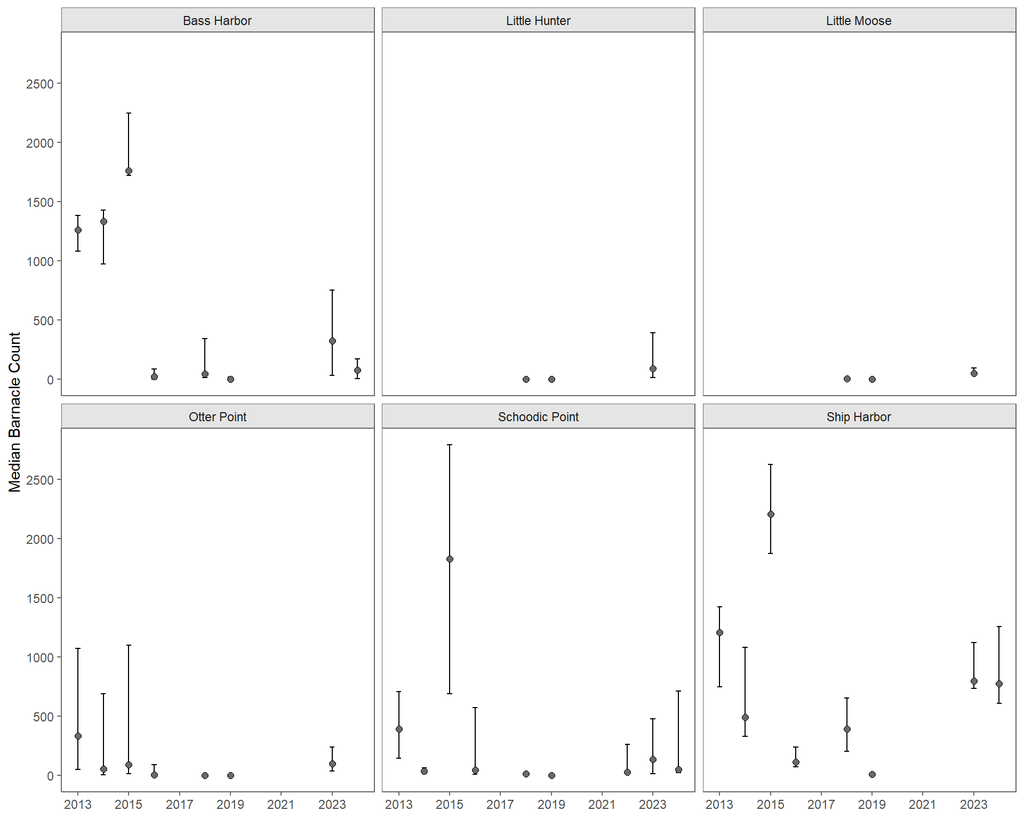

```r
plotBarnacleRecruitment(park = 'ACAD')
```

Plot summer and winter recruitment for all years faceted on ACAD sites

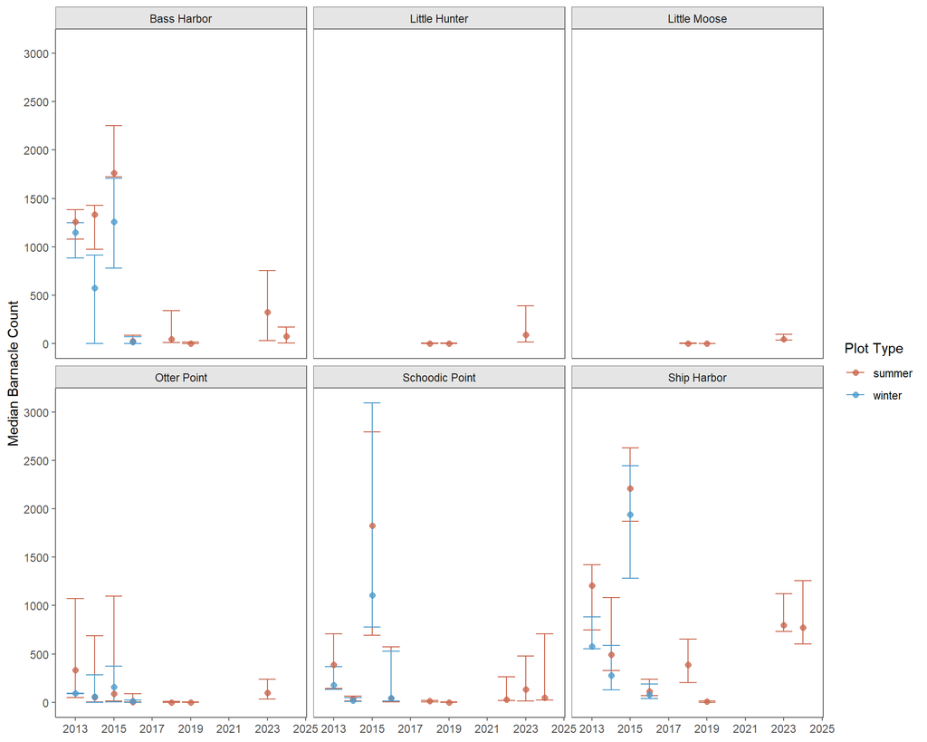

```r
barn <- plotBarnacleRecruitment(park = 'ACAD', plotName = "all")
barn
```

Plot summer recruitment faceted on BOHA sites for 2024

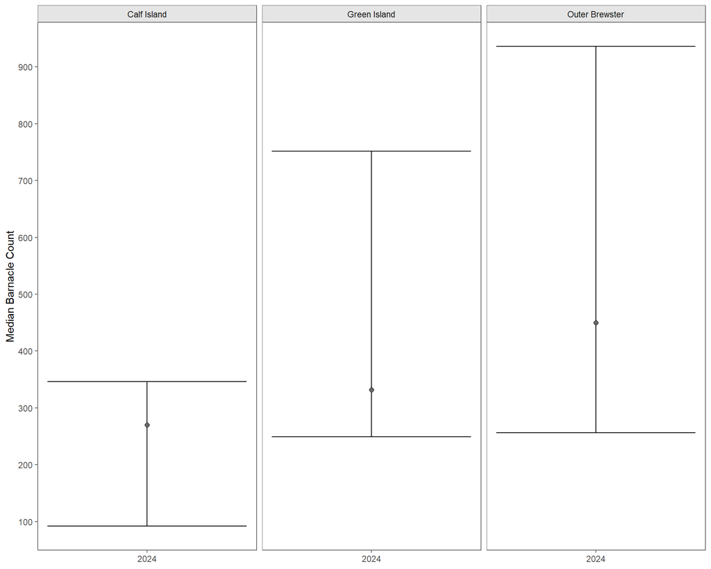

```r
boha <- plotBarnacleRecruitment(park = 'BOHA', years = 2024)
boha
```

Plot raw S5 recruitment for all years faceted on BOHA sites. Individual plots may be useful for QC.

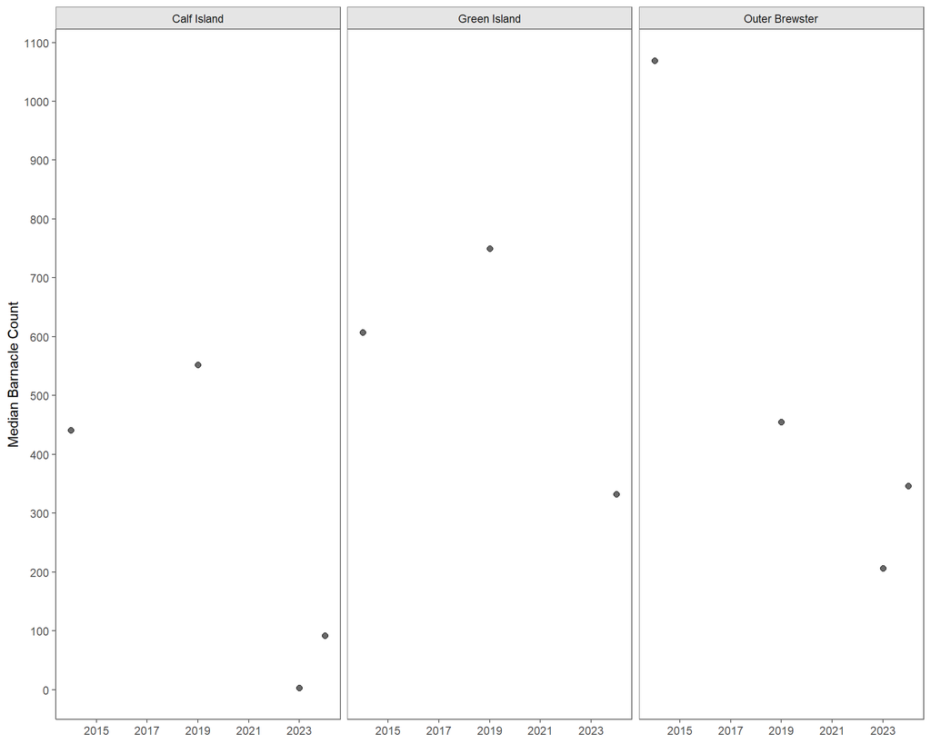

```r
boha_s5 <- plotBarnacleRecruitment(park = 'BOHA', plotName = "S5")
boha_s5
```

#### plotBuoyData()

This function plots water temperature at high tide by site. Note that function works on compiled logger data, rather than working off the raw logger data. Compiled datasets should be imported using importWaterTemp(). To speed up plotting of multiple sites or long time-series, plot the simplified water temperature data derived from importWaterTemp(simplify = TRUE). **NOTE: NOT CURRENTLY ACTIVE; CODE IN THIS SECTION WAS NOT RUN.**

Default filter returns a plot with min/max daily water temperature and max daily windspeed in mph, and wind direction recorded for winds > 35 miles/hour for the closest buoys to ACAD and BOHA

```r
plotBuoyData()
```

Plot windspeed for BOHA for all years

```r
plotBuoyData(park = "BOHA", metric = "wspd")
```

Plot all metrics for 2020 in ACAD

```r
plotBuoyData(park = "ACAD", years = 2020)
```

#### plotEchinoCounts()

This function plots average counts by species for a given park, site, years and species. The point for each species is the median count across the tidepools for that site, year and species. The error bars are the middle 50% (lower 25% and upper 75% quantiles) recorded in tidepools for a species. Note that if more than 1 site is specified, the resulting figure will facet on those variables.

Plot echinoderm counts for Outer Brewster from 2013 to 2021

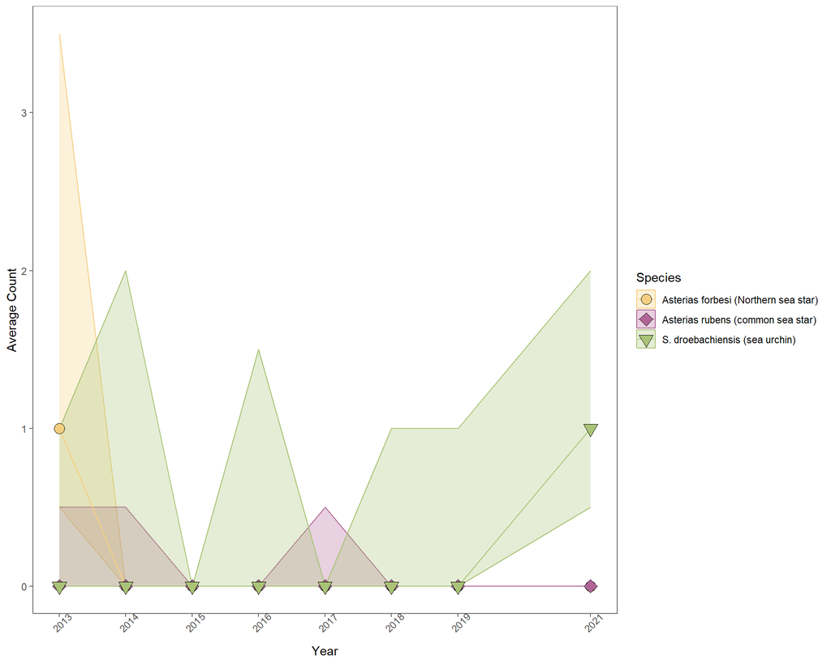

```r
outbrew <- plotEchinoCounts(site = "OUTBRE", years = 2013:2021)
outbrew
```

Plot echinoderm counts for BOHA sites with legend position set to bottom

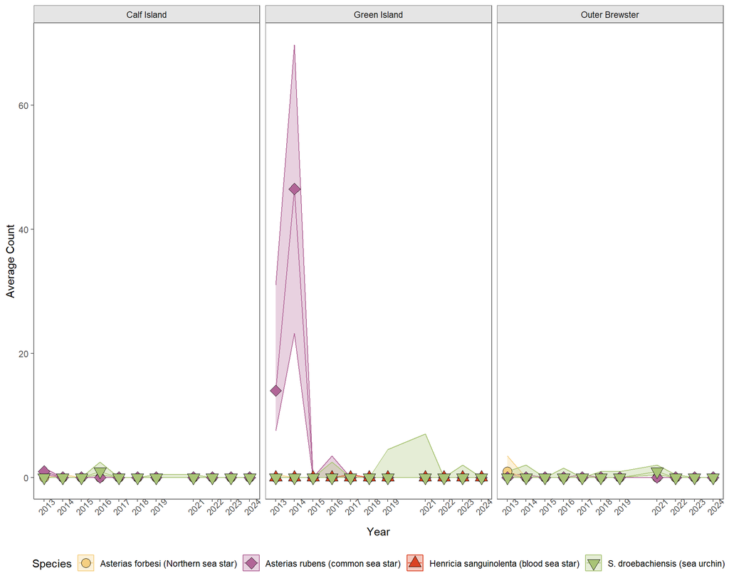

```r
boha <- plotEchinoCounts(park = "BOHA") + theme(legend.position = "bottom")
boha
```

Plot echinoderm counts for sea stars in ACAD, dropping X and changing Y axis labels

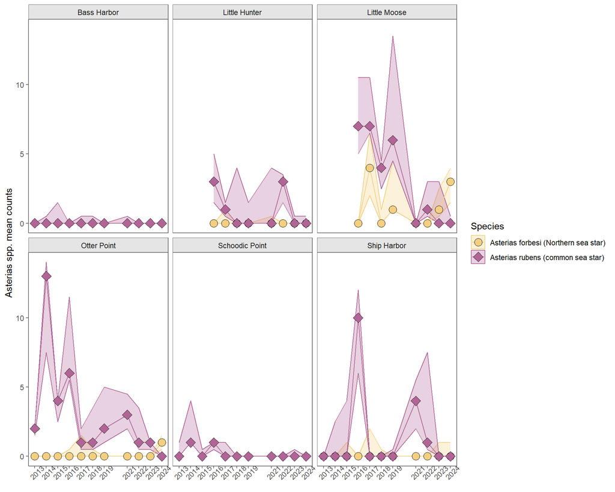

```r
stars <- plotEchinoCounts(park = "ACAD", species = c("ASTFOR", "ASTRUB"), xlab = NULL, ylab = "Asterias spp. mean counts")
stars
```

#### plotEchinoMeas()

Plot echinoderm measurements for all species in Ship Harbor from 2013 to 2019

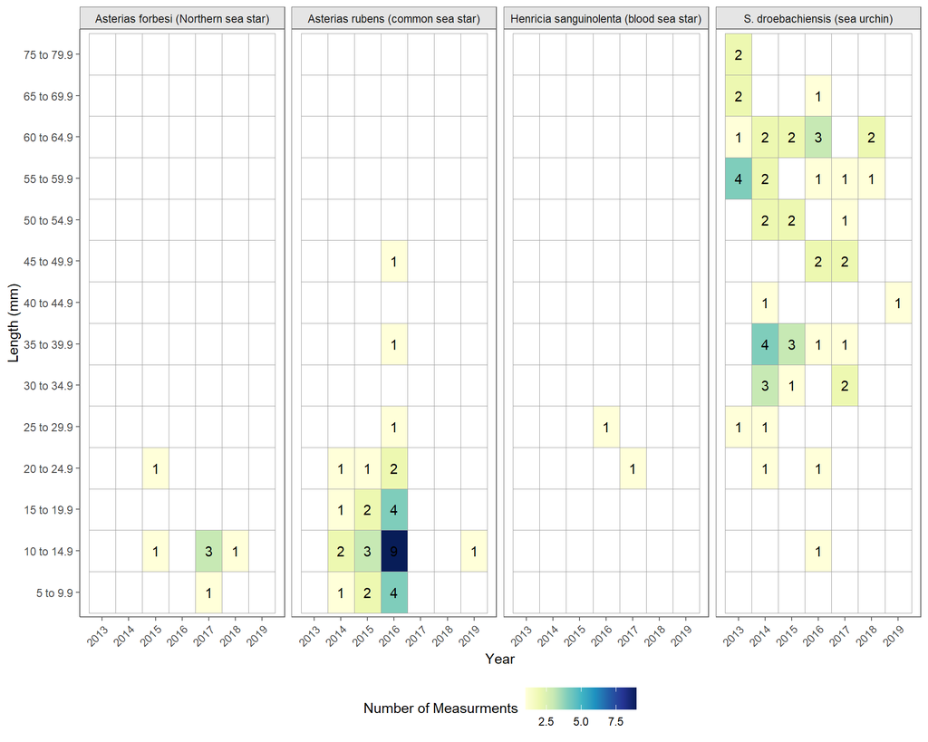

```r
ship <- plotEchinoMeas(site = "SHIHAR", years = 2013:2019)
ship
```

Plot echinoderm measurements for Bass Harbor for sea urchin

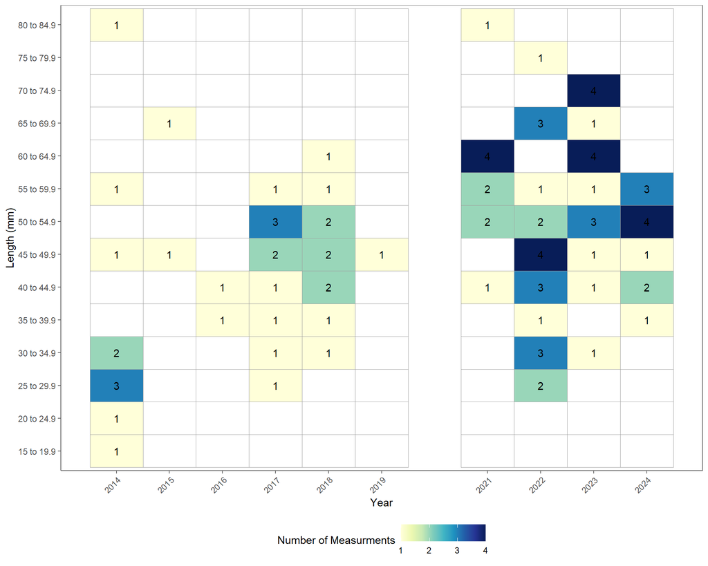

```r
bas_str <- plotEchinoMeas(site = "BASHAR", species = "STRDRO")
bas_str
```

Plot echinoderm measurements of common sea star for BOHA sites

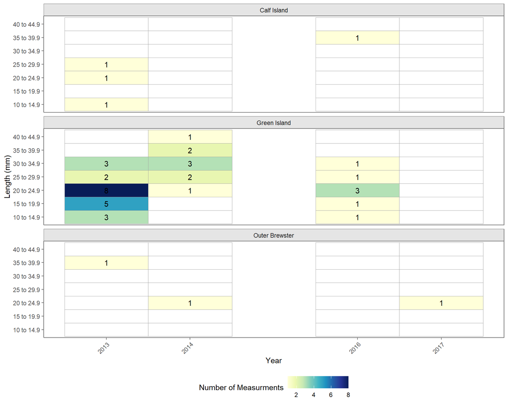

```r
boha_ast <- plotEchinoMeas(park = "BOHA", species = "ASTRUB")
boha_ast
```

#### plotMotileInvertCounts()

This function plots median count by species for a given park, site, years and target species. The point for each species is the median count across the photoplots that site, year and target species. The error bars are the middle 50% (lower 25% and upper 75% quantiles) recorded in photoplots for a target species. Note that if more than 1 site is specified, more than one target species is specified, or both, the resulting figure will facet on those variables.

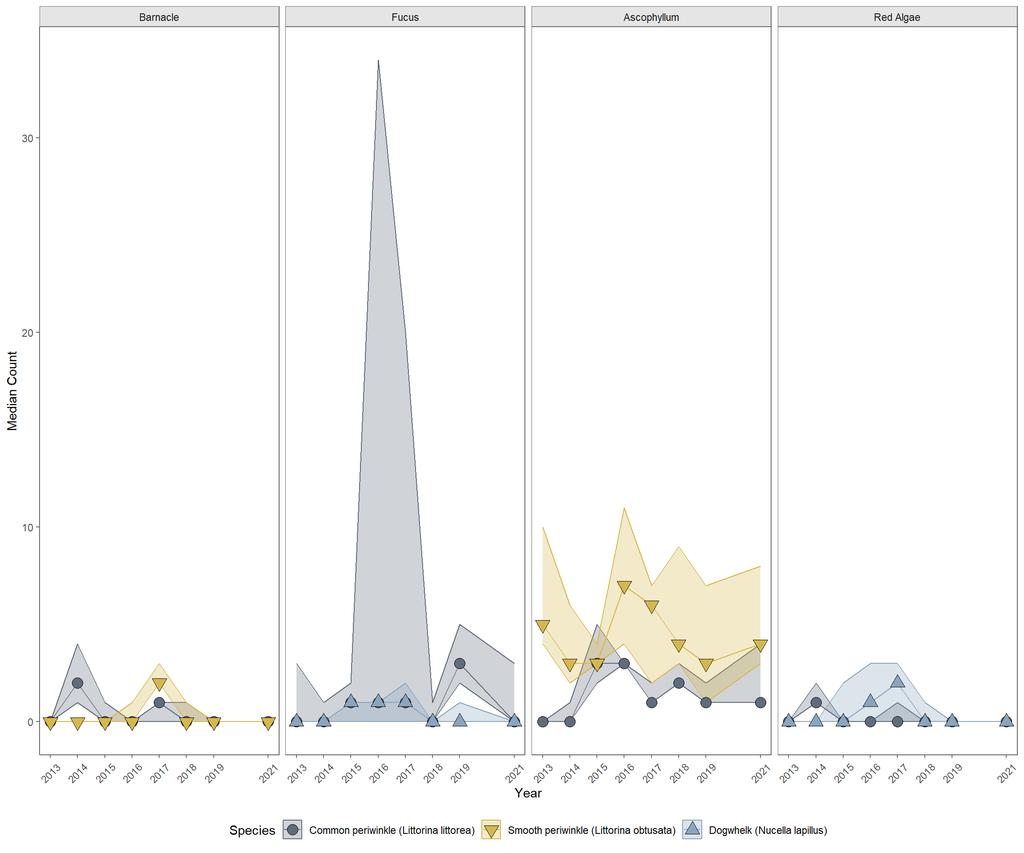

```r
outbre <- plotMotileInvertCounts(site = "OUTBRE", years = 2013:2021)
outbre
```

Plot motile invertebrate counts for all species in Little Hunter Barnacle photoplots

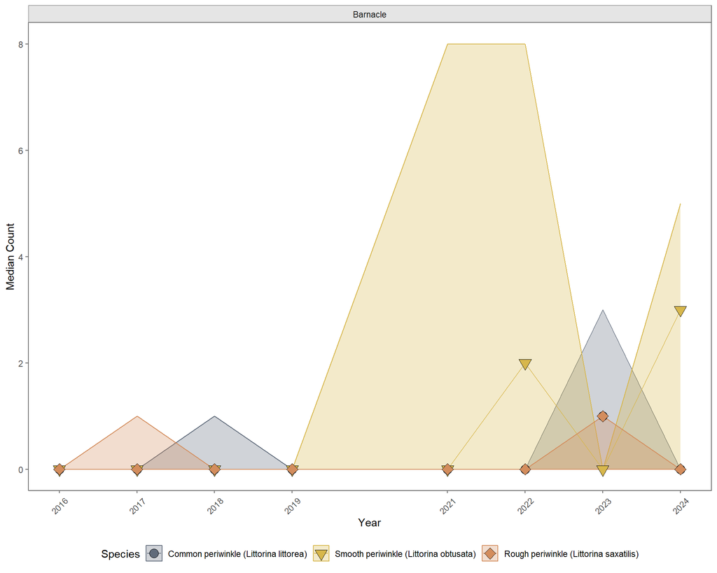

```r
lithun <- plotMotileInvertCounts(site = "LITHUN", community = "Barnacle")
lithun
```

Plot Littorina species counts in Little Hunter with legend position on right

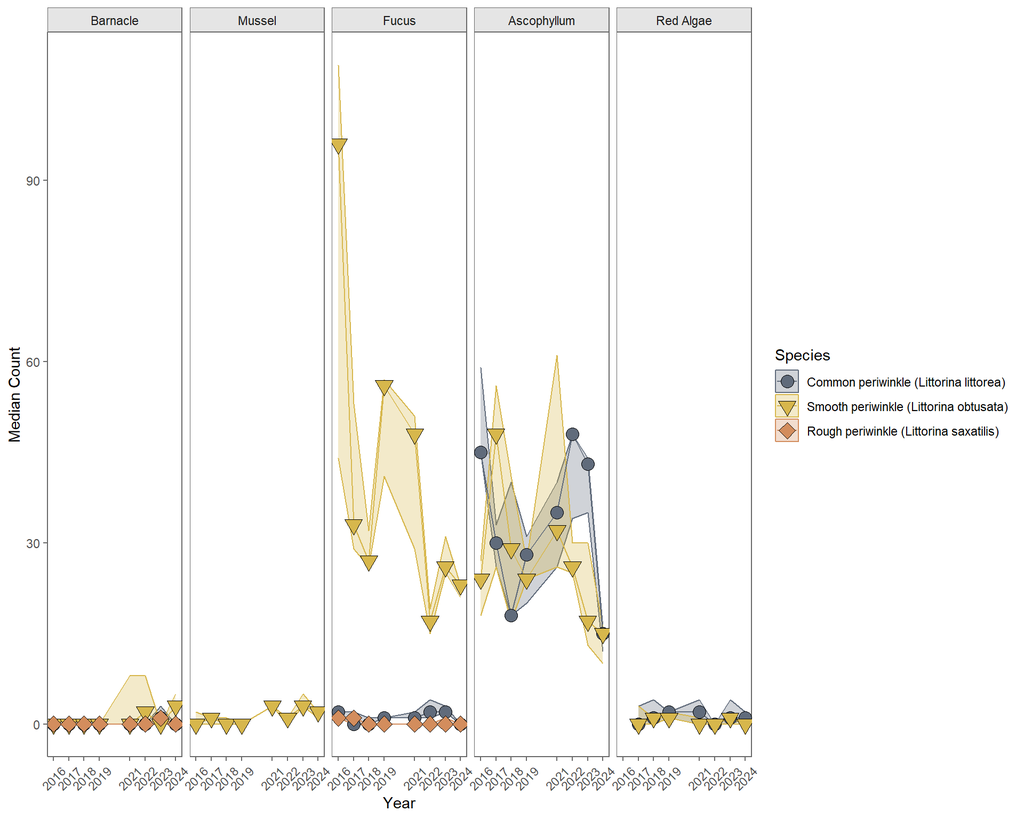

```r
peri <- c("LITLIT", "LITOBT", "LITSAX")
lh_peri <- plotMotileInvertCounts(site = "LITHUN", species = peri) + theme(legend.position = 'right')
lh_peri
```

Plot dogwhelk counts Ship Harbor photoplots, dropping legend.

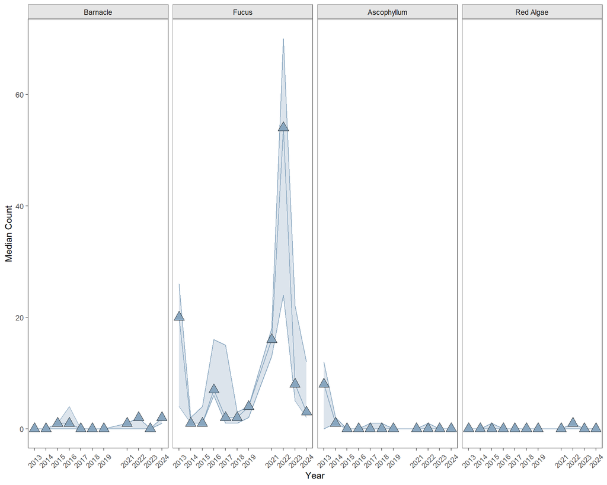

```r
ship_dog <- plotMotileInvertCounts(site = "SHIHAR", species = "NUCLAP") + theme(legend.position = "none")
ship_dog
```

#### plotMotileInvertMeas()

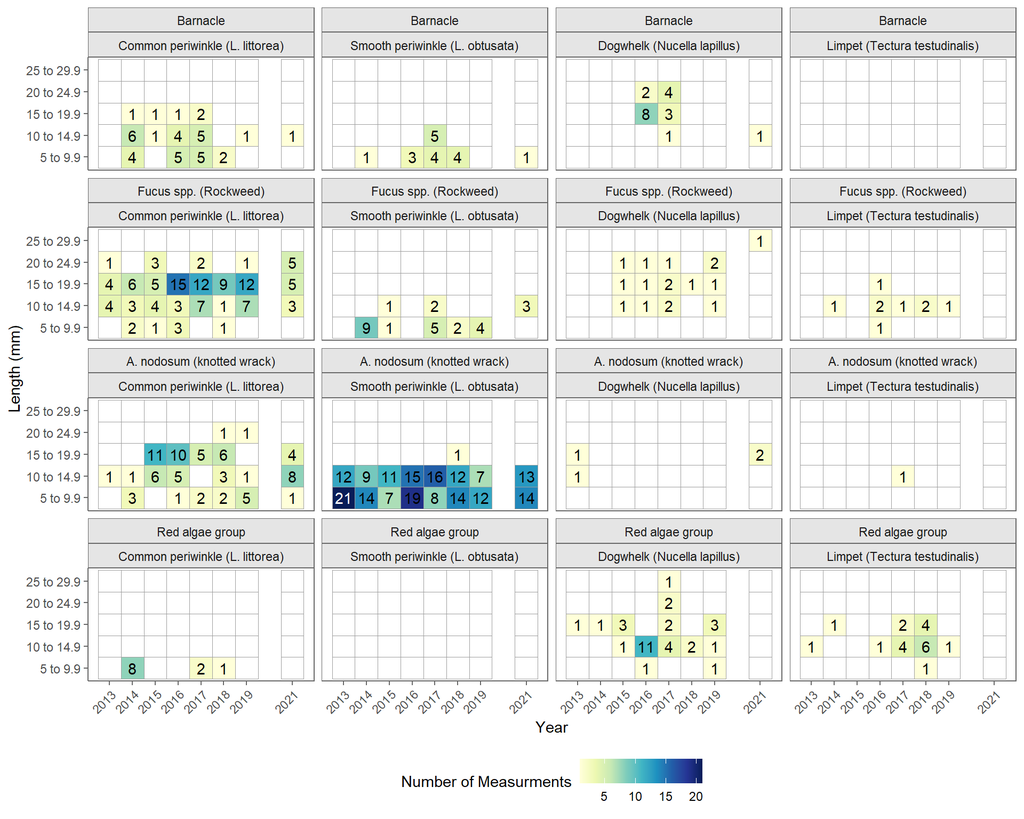

```r
outbre <- plotMotileInvertMeas(site = "OUTBRE", years = 2013:2021)
outbre
```

Plot motile invertebrate measurements for all species in Little Hunter Barnacle photoplots

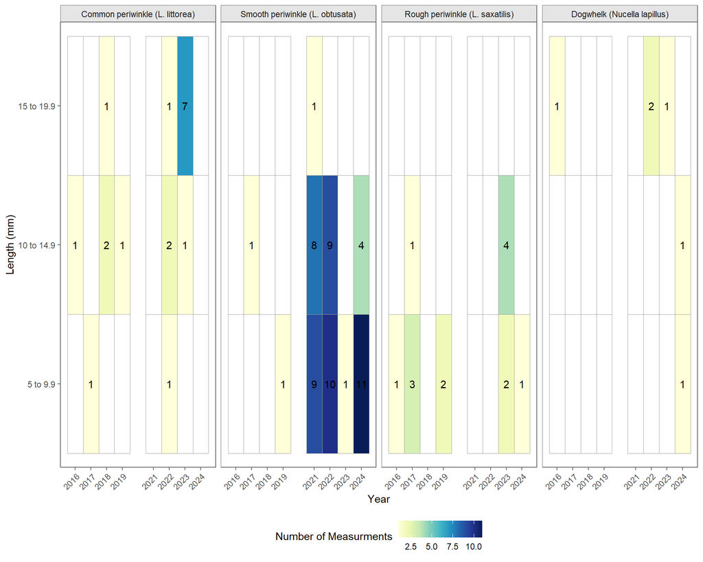

```r
barn <- plotMotileInvertMeas(site = "LITHUN", community = "Barnacle")
barn
```

Plot Littorina species measurements in Little Hunter and add plot title.

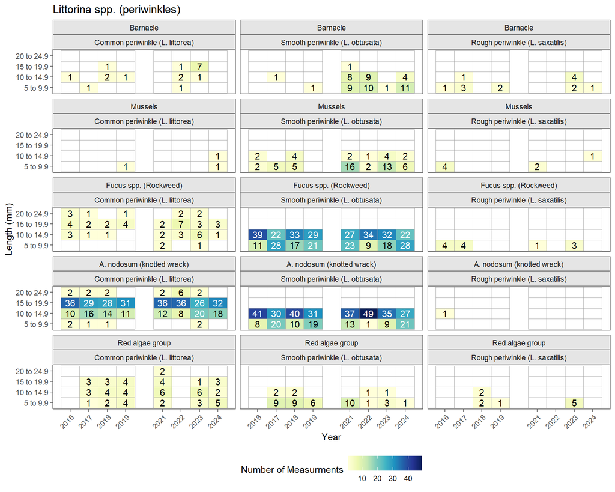

```r
peri <- c("LITLIT", "LITOBT", "LITSAX")
lh_peri2 <- plotMotileInvertMeas(site = "LITHUN", species = peri,
             plot_title = "Littorina spp. (periwinkles)")
lh_peri2
```

#### plotPhotoCover()

Plots the photoplot cover summarized as median cover and middle 50% distribution of cover across the photoplots within a target species. Note that there are a lot of arguments that produce different plots and figures (all explained in the help). Here are a few I tend to use the most.

[figure not shown]

```r
cov_barn <- plotPhotoCover(park = "ACAD", community = "Barnacle")
cov_barn
```

Plot only main species groups in Little Hunter

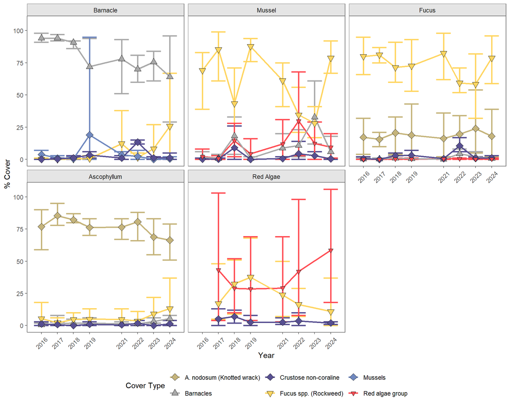

```r
cov_lh <- plotPhotoCover(site = "LITHUN", main_groups = T)
cov_lh
```

Plot only the top 3 highest cover species per community type in Little Hunter

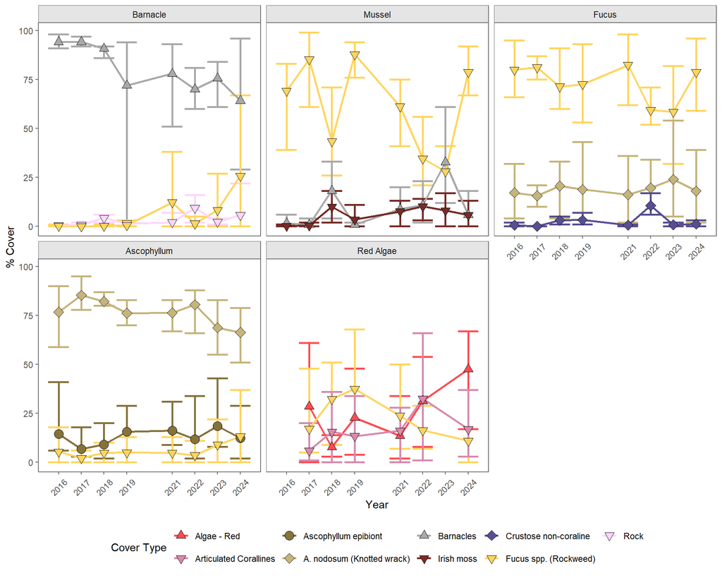

```r
cov_lh3 <- plotPhotoCover(site = "LITHUN", top_spp = 3)
cov_lh3
```

Plot cover as heatmap for main groups in Outer Brewster

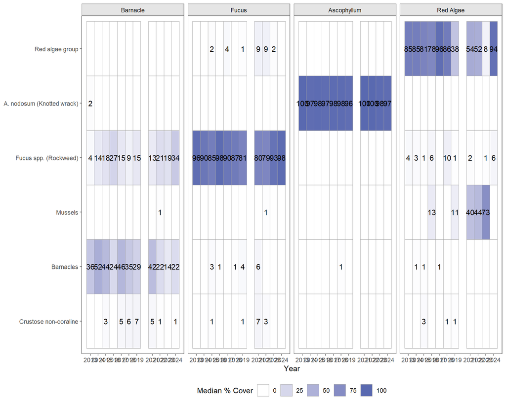

```r
out_heat <- plotPhotoCover(site = "OUTBRE", main_groups = T, heatmap = T, plot_title = "Outer Brewster")
out_heat
```

[figure not shown]

```r
calf <- plotPhotoCover(site = "CALISL", main_groups = T, community = "Fucus", plot_title = "Calf Island Fucus community")
calf
```

#### plotPISpecies()

This function plots species by bolt elevation a given park, site, and years. The point for each species is the median elevation across the three transects for that year. The ribbon represents upper 75% and lower 25% elevation recorded for a species within a given year. The thicker lines on the error bars are the 25% and 75% quantiles of elevation across the transects. The thinner error bars that end with vertical lines are the minimum and maximum elevation detected along the three transects.

Plot main groups for Bass Harbor and facet by species

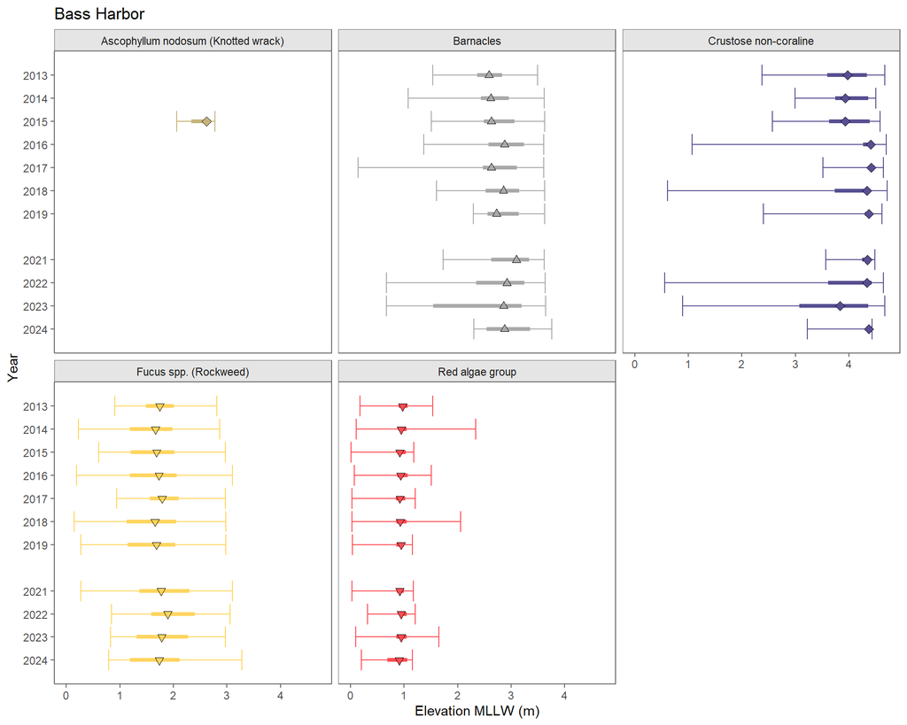

```r
pi_bh <- plotPISpecies(site = "BASHAR", facet = T, main_groups = T)
pi_bh
```

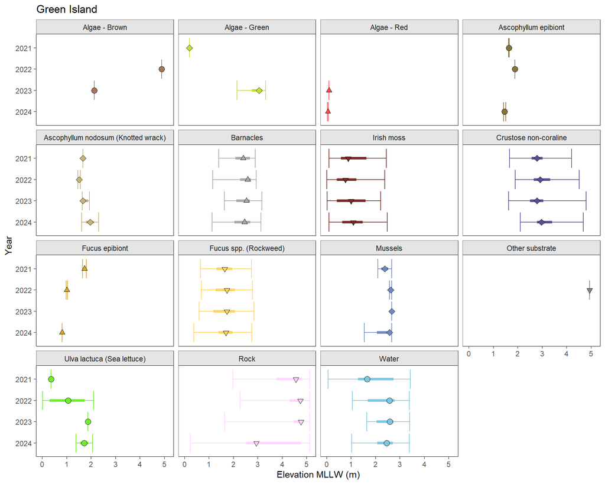

```r
pi_gi <- plotPISpecies(site = "GREISL", facet = T, main_groups = F, years = 2021:2024)
pi_gi
```

Plot main groups in Ship Harbor with reversed axis

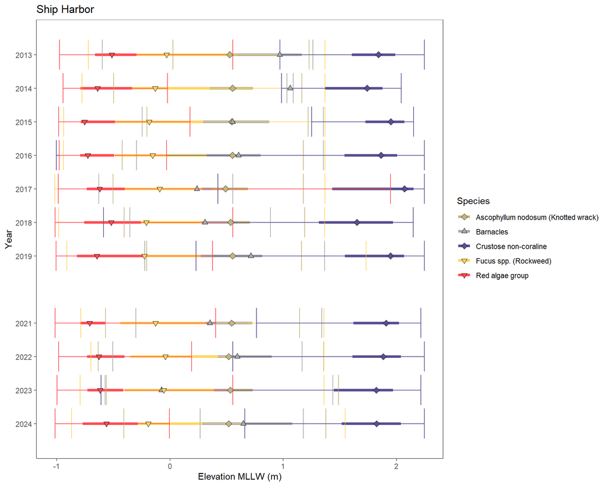

```r
shp_main <- plotPISpecies(site = "SHIHAR", rev_axis = T, facet = F, main_groups = T)
shp_main
```

Plot all species on Transect 1 in Otter Point without faceting on species and custom title. May be helpful for QC.

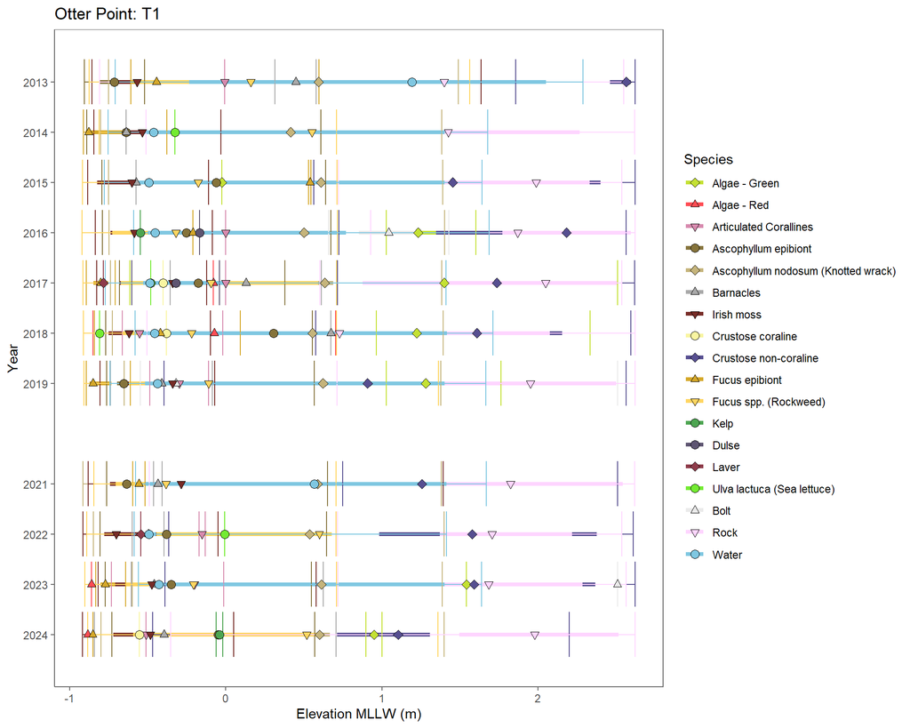

```r
op_t1 <- plotPISpecies(site = "OTTPOI", plotName = "T1") + labs(title = "Otter Point: T1")
op_t1
```

Plot Fucus and Fucus epibiont in Otter Point without faceting on species and dropping y label (b/c axes flipped, this is the xlab). Placing legend at the bottom

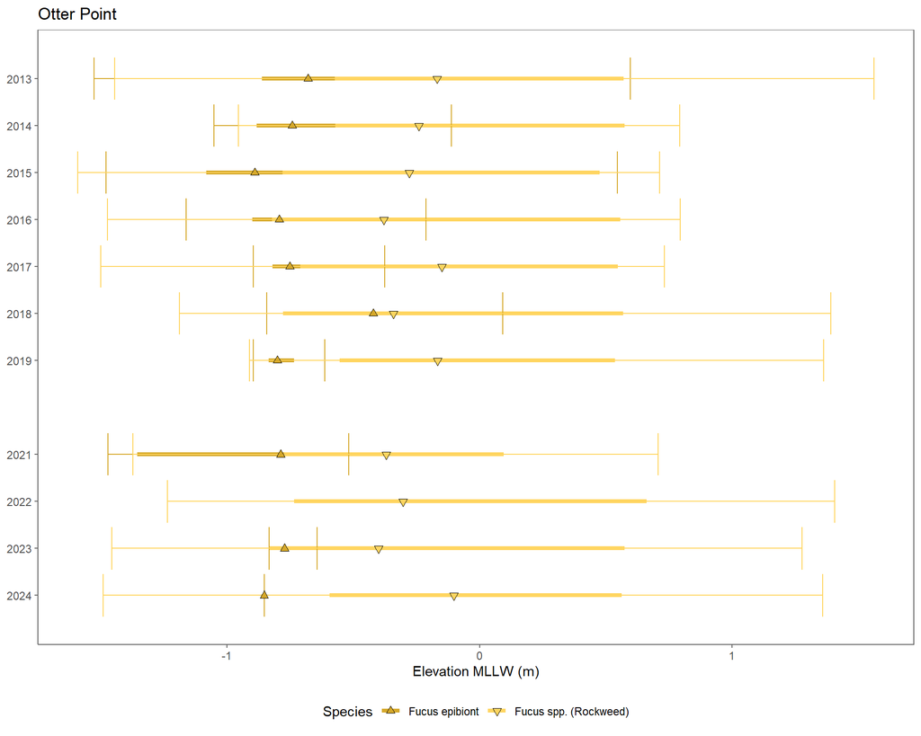

```r
op_fucus <-
plotPISpecies(site = "OTTPOI", species = c("FUCEPI", "FUCSPP"), xlab = NULL) +
  labs(title = "Otter Point") +
  theme(legend.position = "bottom")
op_fucus
```